# Algebraic Groups

## 16.2 Simplicity of $H^0(\lambda)$

1. $k = {\mathbb{C}}$ implies $L(\lambda) = H^0(\lambda)$ for all $\lambda \in X(T)_+$
2. $k= \mkern 1.5mu\overline{\mkern-1.5mu{\mathbb{F}}\mkern-1.5mu}\mkern 1.5mu_p$ implies $L(\lambda) = H^0(\lambda)$ if ${\left\langle {\lambda},~{\alpha_0 {}^{ \vee }} \right\rangle} \leq 1$ where $\alpha_0$ is the highest short root.

Such $\lambda$ are referred to as *minuscule weights*.

For type $A_n$, we have $\alpha_0 = \sum_{i=1}^n \alpha_i$. For type $G_2$, we have $\alpha_0 {}^{ \vee }= 2\alpha_1 {}^{ \vee }+ 3\alpha_2 {}^{ \vee }$.

In type $A_n$, set $\lambda = \sum_{j=1}^n c_j w_j$ where $c_j \geq 0$. Then ${\left\langle {\lambda},~{\alpha_0 {}^{ \vee }} \right\rangle} = \sum c_j \leq 1$, so $\lambda$ is minuscule iff $\lambda = 0$ or $\lambda = w_j$ for some $j$.

Quick timeline:

- 2015, Cantrell lectures by Dick Gross at UGA
- Fall 2015: email to Dan Nakano from Skip Garibaldi, conjecture from Gross without a proof

The simple module is equal to the induced module, so $L(\lambda) = H^0(\lambda)$, for all $p$ iff $\lambda$ is minuscule, or if $L(\lambda) = {\mathfrak{g}}$ for $\Phi = E_8$.

- Proved by Garibaldi-Nakano-Guralnick, appeared in Journal of Algebra

## 16.3 Bott-Borel-Weil Theorem

We can consider the higher right-derived functors of $\lambda$, given by $H^i(\lambda) = R^i \mathop{\mathrm{ind}}_B^G \lambda$ for $\lambda \in X(T)$. You can think of this as the higher sheaf cohomology of the flag variety, $\mathcal{H}^i(G/B, \mathcal{L}(\lambda))$.

We have **Kempf Vanishing**: $H^i(\lambda) = 0$ for all $i>0$ when $\lambda \in X(T)_+$ is dominant (although other things may happen for non-dominant weights). There is a correspondence $(G, T) \iff (W, \Phi)$, and since $W$ is generated by simple reflections, we can write any $w\in W$ as $w=\prod s_{\alpha_i}$. A *reduced expression* is one in which the length can not be shortened, and any two reduced expressions necessarily have the same length (number of simple reflections).

For $\Phi = A_2$, we have $w_0 = s_{\alpha_1} s_{\alpha_2} s_{\alpha_1} = s_{\alpha_2} s_{\alpha_1} s_{\alpha_2}$.

### 16.3.1 Dot Action on Weights

We can let $W$ act on $X(T)$ by reflections by the formula $s_\alpha \lambda = \lambda - {\left\langle {\lambda},~{\alpha {}^{ \vee }} \right\rangle}\alpha$. We then shift the action by setting $s_\alpha \cdot \lambda = w(\lambda+\rho)-\rho$ where $\rho = {1\over 2} \sum_{\alpha\in \Phi^+} \alpha = \sum_{j=1}^n w_j$.

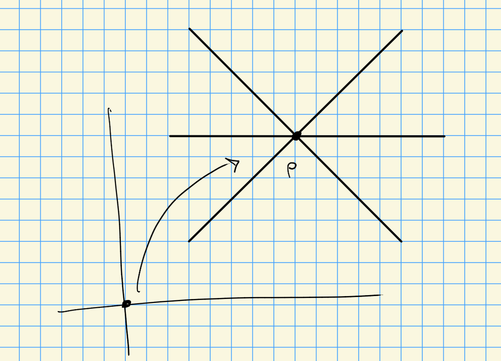

Image

Let $G$ be a reductive algebraic group and $k={\mathbb{C}}$. For $\lambda \in X(T)_+$, we can describe the sheaf cohomology:
$$\begin{align*}
\mathcal{H}^i(w\cdot \lambda)
=
\begin{cases}
H^0(\lambda) & i=\ell(w) \\
0 & \text{otherwise}
\end{cases}
.\end{align*}$$

Moreover, if $\lambda \not\in X(T)_+$ and ${\left\langle {\lambda+\rho},~{\alpha {}^{ \vee }} \right\rangle} \geq 0$ for all $\alpha \in \Delta$, then $\mathcal{H}^i(w\cdot \lambda) = 0$ for all $w\in W$.

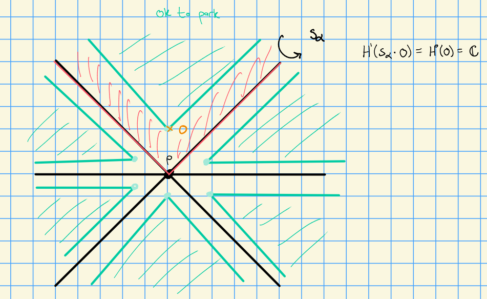

Image

Wide open in characteristic $p$, can say some things. We’ll prove this in characteristic zero.

Recall that $k={\mathbb{C}}$ and $H^0(\lambda) = L(\lambda)$. We’ll want to reduce to ${\operatorname{SL}}(2, {\mathbb{C}})$ parabolics. For $\alpha\in\Delta$, let $P_\alpha$ be the associated parabolic $P_\alpha = L_\alpha \rtimes U_\alpha$, which is parabolic of type $A_1$.

Idea: $\alpha$ generates an ${\operatorname{SL}}_2$ subgroup (the Levi factor), like the Borel but sticks out in one dimension:

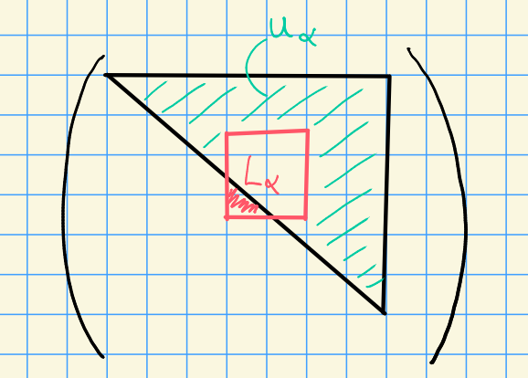

Image

Then
$$\begin{align*}
s_\alpha \cdot \lambda = s_\alpha(\lambda + \rho) - \rho \\
= \lambda + \rho - {\left\langle {\lambda + \rho},~{\alpha {}^{ \vee }} \right\rangle}\alpha - \rho \\
= \lambda - {\left\langle {\lambda + \rho},~{\alpha {}^{ \vee }} \right\rangle}\alpha
.\end{align*}$$

Next time: proof of Bott-Borel-Weil and its generalization to $k = \mkern 1.5mu\overline{\mkern-1.5mu{\mathbb{F}}\mkern-1.5mu}\mkern 1.5mu_p$. For $B\subset P_\alpha \subset G$, we’ll have a spectral sequence
$$\begin{align*}
E_2^{i, j} = R^i \mathop{\mathrm{ind}}_{P_\alpha}^G R^j \mathop{\mathrm{ind}}_B^{P_\alpha} \Rightarrow R^{i+j} \mathop{\mathrm{ind}}_B^G \lambda = H^{i+j}(\lambda)
.\end{align*}$$

# 17 Friday, October 09

Last time: Bott-Borel-Weil. Stated for characteristic zero, working toward a generalization.

Let $\Delta$ be the set of simple roots, and $\alpha\in \Delta$. We can form a Levi decomposition $P_\alpha \mathrel{\vcenter{:}}= L_\alpha \rtimes U_\alpha$:

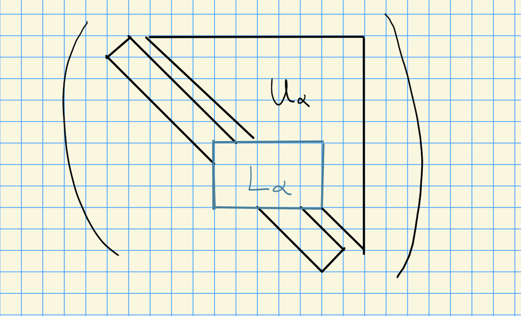

Image

We have $B \subseteq P_\alpha \subseteq G$. The dot action is given by the following: Let $W$ be the Weyl group, then $W$ acts on $X(T)$ by $w\cdot \lambda = w(\lambda + \rho) - \rho$, where
$$\begin{align*}
\rho = {1\over 2} \sum_{\alpha\in \Phi^+} \alpha = \sum_{i=1}^n w_n
.\end{align*}$$

We obtained a formula
$$\begin{align*}
S_\alpha \cdot \lambda = \lambda - {\left\langle {\lambda + \rho},~{\alpha {}^{ \vee }} \right\rangle} \alpha
.\end{align*}$$

## 17.1 Bott-Borel-Weil Theory

Let $\alpha\in\Delta$ be simple and $\lambda \in X(T)$ be an arbitrary weight. Then

- $U_\alpha$ acts trivially on $\mathop{\mathrm{ind}}_B^{P_\alpha} \lambda$.
- (Kempf’s Vanishing for $P_\alpha$) If ${\left\langle {\lambda},~{\alpha {}^{ \vee }} \right\rangle} = r \geq 0$, then
  $$\begin{align*}
  R^i \mathop{\mathrm{ind}}_B^{P_\alpha} \lambda = 0 \qquad \text{for } i \geq 0
  ,\end{align*}
  and \(\dim \mathop{\mathrm{ind}}_B^{P_\alpha}\lambda = r + 1\).$$
- If ${\left\langle {\lambda},~{\alpha {}^{ \vee }} \right\rangle} = -1$, then $R^i \mathop{\mathrm{ind}}_B^{P_\alpha} \lambda = 0$ for all $i$.
- If ${\left\langle {\lambda},~{\alpha {}^{ \vee }} \right\rangle} \leq -2$, then
  - $R^i \mathop{\mathrm{ind}}_B^{P_\alpha} \lambda = 0$ for $i \neq 1$, and
  - $\dim R^1 \mathop{\mathrm{ind}}_B^{P_\alpha} \lambda = r+1$

Note: we have
$$\begin{align*}
\mathop{\mathrm{ind}}_B^{P_\alpha} \lambda = S^r(V) \qquad &\text{when } {\left\langle {\lambda},~{\alpha {}^{ \vee }} \right\rangle} = r \geq 0 \\
R^1 \mathop{\mathrm{ind}}_B^{P_\alpha} = S^r(V) {}^{ \vee }\qquad&\text{where $V$ is a 2-dim representation and } {\left\langle {\lambda},~{\alpha {}^{ \vee }} \right\rangle} \leq -2 \\
&\text{and } r = {\left\lvert {{\left\langle {\lambda},~{\alpha {}^{ \vee }} \right\rangle}} \right\rvert} - 1
.\end{align*}$$

This gives us an analog of $A_1$ or ${\operatorname{SL}}_2$ theory. Also note that we have Serre duality:
$$\begin{align*}
H^1(\lambda) = H^0( - (\lambda + 2\rho) ) {}^{ \vee }
.\end{align*}$$

Let $\alpha\in \Delta$ and $\lambda\in X(T)$, and suppose $\lambda$ is dominant with respect to $\alpha$, i.e. ${\left\langle {\lambda},~{\alpha {}^{ \vee }} \right\rangle} \geq 0$.

- If $\operatorname{ch}(k) = 0$ then $\mathop{\mathrm{ind}}_B^{P_\alpha}\lambda = R^1 \mathop{\mathrm{ind}}_B^{P_\alpha} s_\alpha \cdot \lambda$
- If $\operatorname{ch}(k) = p$ and if there exists an $s, m$ with $0<s<p$ and ${\left\langle {\lambda},~{\alpha {}^{ \vee }} \right\rangle} = sp^m - 1$ (Steinberg weights), then
  $$\begin{align*}
  \mathop{\mathrm{ind}}_B^{P_\alpha} \lambda = R^1 \mathop{\mathrm{Ind}}_B^{P_\alpha} s_\alpha \cdot \lambda
  .\end{align*}$$

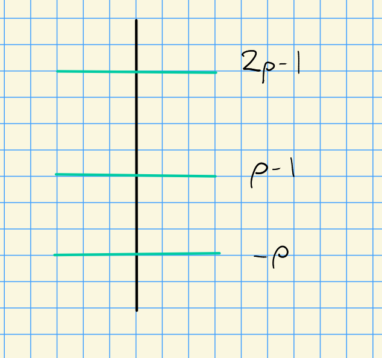

The proof of this will use a Grothendieck-type spectral sequence of the form
$$\begin{align*}
E_2^{i, j} = R^i \mathop{\mathrm{ind}}_{P_\alpha}^G \qty{ R^j \mathop{\mathrm{ind}}_B^{P_\alpha} \lambda} \Rightarrow R^{i+j} \mathop{\mathrm{ind}}_B^G \lambda
.\end{align*}$$

We’ll have a version of *Grothendieck vanishing*:
$$\begin{align*}
R^j \mathop{\mathrm{ind}}_B^{P_\alpha} \lambda = 0 \qquad\text{for } j > \dim P_\alpha/B = 1
.\end{align*}$$

So the resulting spectral sequence will only be supported on the first two lines, and $E_3 = E_\infty$. Note the differential will be of bidegree ${\partial}_r \leadsto (r, 1-r)$, and $E_2$ will look like the following,

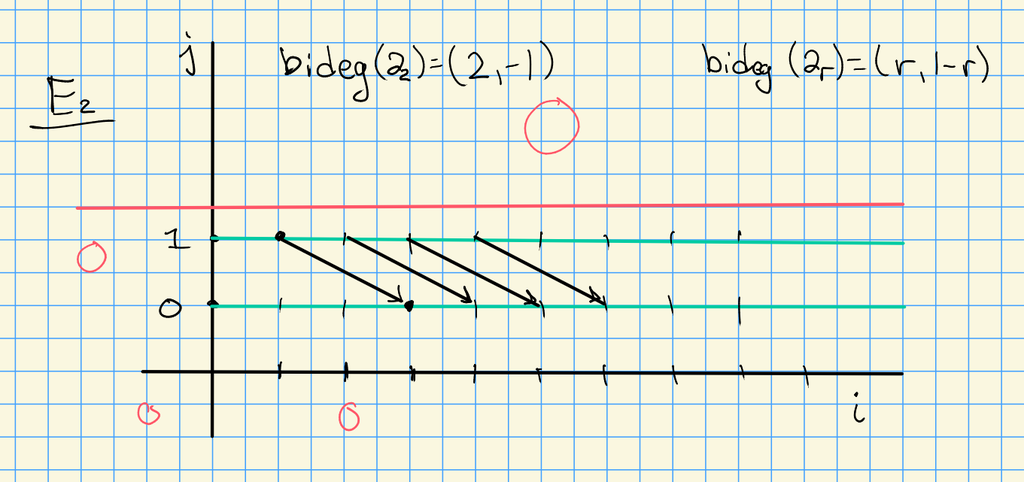

Image

Recall that $R^i \mathop{\mathrm{ind}}_B^G \lambda \mathrel{\vcenter{:}}= H^i(\lambda)$

Let $\alpha\in\Delta$ and $\lambda \in X(T)$.

1. If ${\left\langle {\lambda},~{\alpha {}^{ \vee }} \right\rangle} = -1$, then $H^{-}(\lambda) = 0$.
2. If ${\left\langle {\lambda},~{ \alpha {}^{ \vee }} \right\rangle} \geq 0$, then $H^i(\lambda) = R^i \mathop{\mathrm{ind}}_B^{P_\alpha} \lambda$ for all $i\geq 0$.
3. If ${\left\langle {\lambda},~{\alpha {}^{ \vee }} \right\rangle} \leq -2$, then
   $$\begin{align*}
   H^i(\lambda) = R^{i-1} \mathop{\mathrm{ind}}_{P_\alpha}^G \qty{ R^1 \mathop{\mathrm{ind}}_B^{P_\alpha} \lambda } \qquad \forall i
   .\end{align*}$$
4. Suppose ${\left\langle {\lambda},~{\alpha {}^{ \vee }} \right\rangle} \geq 0$. If $\operatorname{ch}(k) = 0$, or $\operatorname{ch}(k) = p> 0$ and ${\left\langle {\lambda},~{\alpha {}^{ \vee }} \right\rangle} = sp^n - 1$, then
   $$\begin{align*}
   H^i(\lambda) = H^{i+1}(s_\alpha\cdot \lambda)
   .\end{align*}$$

If ${\left\langle {\lambda},~{\alpha {}^{ \vee }} \right\rangle} = -1$, then $R^{-}\mathop{\mathrm{ind}}_B^{P_\alpha} \lambda = 0$. But this is what appears as the “coefficients” in the spectral sequence, so $E_2^{{-}, {-}} = 0$ and this $R^{-}\mathop{\mathrm{ind}}_B^{P_\alpha} = 0$.

If ${\left\langle {\lambda},~{\alpha {}^{ \vee }} \right\rangle} = 0$, then $R^j \mathop{\mathrm{ind}}_B^{P_\alpha} \lambda = 0$ for all $j>0$. Thus only the bottom line survives, and the spectral sequence degenerates on page 2. Thus $E_2^{1, 0} = R^i \mathop{\mathrm{ind}}_B^G \lambda$, where the LHS is equal to $R^i \mathop{\mathrm{ind}}_{P_\alpha}^G \qty{\mathop{\mathrm{ind}}_B^{P_\alpha} \lambda }$.

If ${\left\langle {\lambda},~{\alpha {}^{ \vee }} \right\rangle} = -2$, then $R^i \mathop{\mathrm{ind}}_B^{P_\alpha} \lambda = 0$ for $i\neq 1$, so only $i=1$ survives Then
$$\begin{align*}
R^{i-1} \mathop{\mathrm{ind}}_{P_\alpha}^G \qty{ \mathop{\mathrm{ind}}_B^{PP_\alpha} \alpha} = R^i \mathop{\mathrm{ind}}_B^G \lambda
,\end{align*}
so there is some dimension shifting.$$

If ${\left\langle {\lambda},~{\alpha {}^{ \vee }} \right\rangle} \geq 0$, then by (b),
$$\begin{align*}
H^i(\lambda)
&= R^i \mathop{\mathrm{ind}}_{P_\alpha}^G \qty{ \mathop{\mathrm{ind}}_B^{P_\alpha} \lambda } && \text{by c}\\
&= R^i \mathop{\mathrm{ind}}_{P_\alpha}^G \qty{ R^1 \mathop{\mathrm{ind}}_B^{P_\alpha} s_\alpha\cdot \lambda } && \text{by corollary}\\
&= H^{i+1}(s_\alpha\cdot \lambda)
.\end{align*}$$

We can then check that
$$\begin{align*}
s_\alpha \cdot \lambda
&= \lambda - {\left\langle {\lambda + \rho},~{\alpha {}^{ \vee }} \right\rangle}\alpha \\
&= \lambda - \qty{ {\left\langle {\lambda},~{\alpha {}^{ \vee }} \right\rangle} + 1 }\alpha && \text{using } {\left\langle {\rho},~{\alpha {}^{ \vee }} \right\rangle} = 1 \\ \\
\implies
{\left\langle {s_\alpha \cdot \lambda},~{\alpha {}^{ \vee }} \right\rangle}
&= {\left\langle {\lambda},~{\alpha {}^{ \vee }} \right\rangle} - \qty{ {\left\langle {\lambda},~{\alpha {}^{ \vee }} \right\rangle}+1 }{\left\langle {\alpha},~{\alpha {}^{ \vee }} \right\rangle} \\
&= {\left\langle {\lambda},~{\alpha {}^{ \vee }} \right\rangle} - \qty{ {\left\langle {\lambda},~{\alpha {}^{ \vee }} \right\rangle}+1 }2 \\
&= -{\left\langle {\lambda},~{\alpha {}^{ \vee }} \right\rangle} - 2 \\
&\leq -2
.\end{align*}$$

Now define
$$\begin{align*}
\mkern 1.5mu\overline{\mkern-1.5muC\mkern-1.5mu}\mkern 1.5mu_{{\mathbb{Z}}}
&\mathrel{\vcenter{:}}=
\left\{{
\lambda \in X(T) {~\mathrel{\Big|}~}0 \leq {\left\langle {\lambda+\rho},~{\beta {}^{ \vee }} \right\rangle} \,\forall \beta \in \Phi^+
}\right\} \qquad\text{ if } \operatorname{ch}(k) = 0 \\
&\mathrel{\vcenter{:}}=
\left\{{
\lambda \in X(T) {~\mathrel{\Big|}~}0 \leq {\left\langle {\lambda+\rho},~{\beta {}^{ \vee }} \right\rangle} \leq \operatorname{ch}(k) \,\forall \beta \in \Phi^+
}\right\} \qquad\text{if } \operatorname{ch}(k) = p
.\end{align*}$$

Idea:

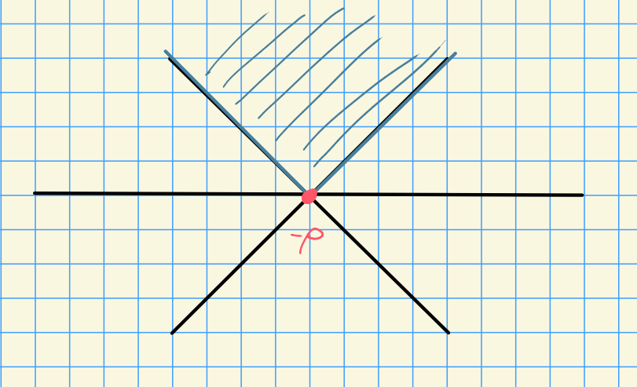

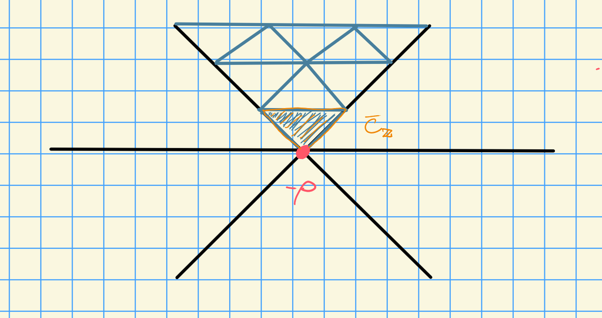

1. If $\lambda \in \mkern 1.5mu\overline{\mkern-1.5muC\mkern-1.5mu}\mkern 1.5mu_{\mathbb{Z}}$ and $\lambda \not\in X(T)_+$, then $H^0(w\cdot \lambda) = 0$.
2. If $\lambda \in \mkern 1.5mu\overline{\mkern-1.5muC\mkern-1.5mu}\mkern 1.5mu_{\mathbb{Z}}\cap X(T)_+$, then for all $w\in W$,
   $$\begin{align*}
   H^i(w\cdot \lambda) =
   \begin{cases}
   H^0(\lambda) & i= \ell(w) \\
   0 & \text{otherwise}
   \end{cases}
   .\end{align*}$$

Note that this covers everything in the $\operatorname{ch}(k) = 0$ case, but only gives the following hexagon in the $\operatorname{ch}(k) = p$ case:

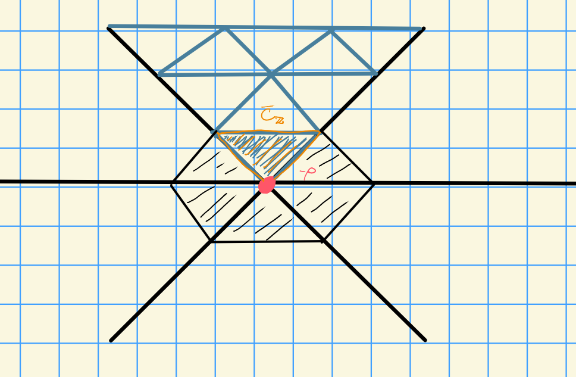

Image

**Open Problem**: Determine $\operatorname{ch}H^i(\lambda)$ for $\lambda\in X(T)$ in characteristic $p>0$.

Andersen provided necessary an sufficient conditions for $H^1(\lambda) \neq 0$ and computed $\mathop{\mathrm{Soc}}_G H^1(\lambda)$.

# 18 Monday, October 12

## 18.1 Proof of Bott-Borel-Weil

Recall the Bott-Borel-Weil theorem: in characteristic zero, we’re looking at the closure of the region containing the fundamental region $C_{\mathbb{Z}}$:

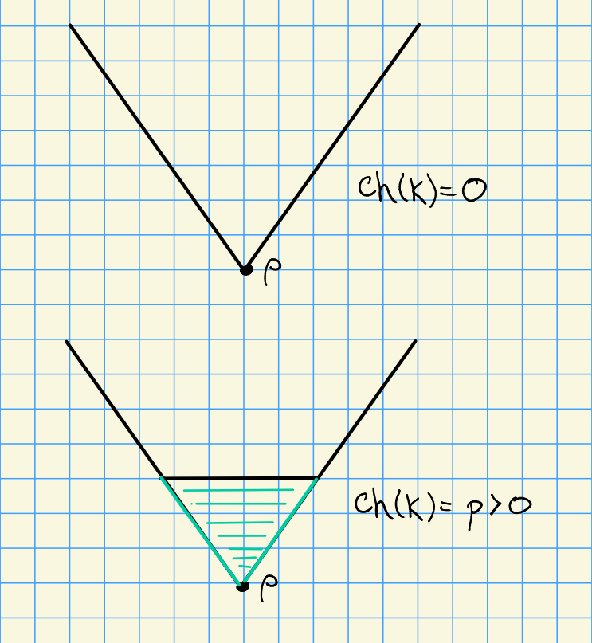

Image

1. If $\lambda \in \mkern 1.5mu\overline{\mkern-1.5muC\mkern-1.5mu}\mkern 1.5mu_{\mathbb{Z}}$ and $\lambda \not\in X(T)_+$ then $H^0(w\circ \lambda) = 0$.
2. If $\lambda\in \mkern 1.5mu\overline{\mkern-1.5muC\mkern-1.5mu}\mkern 1.5mu_{\mathbb{Z}}\cap X(T)_+$ then for all $w\in W$, we have
   $$\begin{align*}
   H^i(w\cdot \lambda) =
   \begin{cases}
   H^0(\lambda)& i = \ell(w) \\
   0 & \text{otherwise}
   \end{cases}
   .\end{align*}$$

For (a): we use induction on $\ell(w)$. For $\ell(w) = 0$, we have $w = \operatorname{id}$. Let $\lambda \in \mkern 1.5mu\overline{\mkern-1.5muC\mkern-1.5mu}\mkern 1.5mu_{\mathbb{Z}}$ and $\lambda\not\in X(T)_+$. Then
$$\begin{align*}
0
&\leq {\left\langle {\lambda + \rho},~{\alpha {}^{ \vee }} \right\rangle} \\
&= {\left\langle {\lambda},~{\alpha {}^{ \vee }} \right\rangle} + 1 \\
\implies {\left\langle {\lambda},~{\alpha {}^{ \vee }} \right\rangle} &= -1
.\end{align*}
Applying the previous proposition, we get \(H^0(\lambda) = 0\).$$

For the base case $w=\operatorname{id}$, this follows from Kempf vanishing. Assuming the result holds for any word of length $l<\ell(w)$, if $\ell(w) > 0$, there exists some simple reflection $s_\alpha$ for $\alpha\in\Delta$ such that $\ell(s_\alpha w) = \ell(w) - 1$. Moreover, $w^{-1}(\alpha) \in -\Phi^+$, so set $\beta = -w^{-1}(\alpha) \in \Phi^+$. We can the make the following computation:
$$\begin{align*}
{\left\langle {(s_\alpha w) \cdot \lambda},~{\alpha {}^{ \vee }} \right\rangle}
&= {\left\langle {(s_\alpha w)(\lambda+\rho) - \rho},~{\alpha {}^{ \vee }} \right\rangle} \\
&= {\left\langle {(s_\alpha w)(\lambda+\rho)},~{\alpha {}^{ \vee }} \right\rangle} - 1 \\
&= {\left\langle {w(\lambda+\rho)},~{s_\alpha \alpha {}^{ \vee }} \right\rangle} - 1 \\
&= - {\left\langle {w(\lambda+\rho)},~{\alpha {}^{ \vee }} \right\rangle} - 1 \\
&= {\left\langle {\lambda + \rho},~{-w^{-1}\alpha {}^{ \vee }} \right\rangle} - 1 \\
&= {\left\langle {\lambda + \rho},~{\beta {}^{ \vee }} \right\rangle} - 1 \\
&\geq -1
\end{align*}
and \({\left\langle {(s_\alpha w)\cdot \lambda},~{ \alpha {}^{ \vee }} \right\rangle} < \rho\) since \(\lambda\in \mkern 1.5mu\overline{\mkern-1.5muC\mkern-1.5mu}\mkern 1.5mu_{\mathbb{Z}}\). Note that we’ve used the fact that the inner product is \(W{\hbox{-}}\)invariant.$$

Now if ${\left\langle {(s_\alpha w)\cdot \lambda},~{ \alpha {}^{ \vee }} \right\rangle} \geq 0$, we can apply the prior proposition part (d). Here we use the fact that $\mathop{\mathrm{ind}}_B^{P_\alpha}(s_\alpha w)\lambda$ is simple. Applying the inductive hypothesis yields
$$\begin{align*}
H^i(s_\alpha - \lambda) = H^{i+1}(w\cdot \lambda)
.\end{align*}$$

Now if ${\left\langle {s_\alpha w \cdot \lambda},~{\alpha {}^{ \vee }} \right\rangle} = -1$, then
$$\begin{align*}
-1 &= {\left\langle {\lambda + \rho},~{\beta {}^{ \vee }} \right\rangle} - 1 \\
\implies {\left\langle {\lambda + \rho},~{\beta {}^{ \vee }} \right\rangle} &= 0 \\
\implies {\left\langle {\lambda},~{\beta {}^{ \vee }} \right\rangle} &= 0 \\
& \cdots
.\end{align*}$$

Then applying (a) yields $H^1(w\cdot \lambda) = 0$.

## 18.2 Serre Duality and Grothendieck Vanishing

Let $P$ be a parabolic subgroup, i.e. $P_J = P \mathrel{\vcenter{:}}= L_J \rtimes U_J$ for some $J\subseteq \Delta$. Set $n(P) = {\left\lvert {\Phi^+} \right\rvert} - {\left\lvert {\Phi^+_J} \right\rvert}$.

Let $\Phi = A_4$, which has ten simple roots:

- $\alpha_i, 1\leq i \leq 4$
- $\alpha_i + \alpha_{i+1}$, $i=1,2,3$.
- $\alpha_1 + \alpha_2 +\alpha_3$, $\alpha_2 + \alpha_3 + \alpha_4$
- $\sum_{i=1}^4 \alpha_i$.

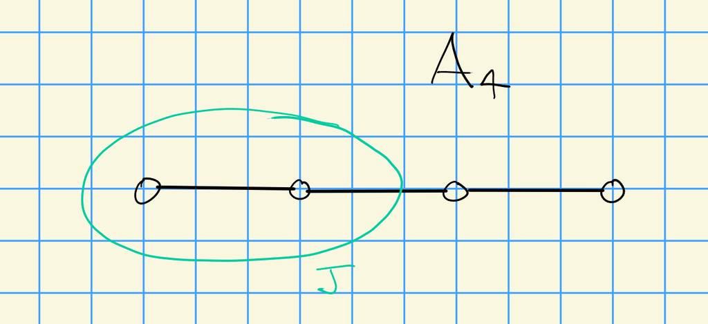

Image

Then $n(P) = 10 - 3 = 7$.

$$\begin{align*}
R^i \mathop{\mathrm{ind}}_P^G M = 0 \qquad \text{for } i > n(P)
.\end{align*}$$

$$\begin{align*}
\qty{ R^i \mathop{\mathrm{ind}}_B^G M } {}^{ \vee }\cong R^{n(P) -i} \mathop{\mathrm{ind}}_P^G M {}^{ \vee }\otimes(-2\rho_P)
.\end{align*}
where
\begin{align*}
\rho_p \mathrel{\vcenter{:}}={1\over 2}\sum_{\beta \in \Phi^+ \setminus\Phi_J} \beta
\end{align*}$$

Take $B = P$ and $M = \lambda$. Then $\lambda {}^{ \vee }= -\lambda$, so
$$\begin{align*}
\qty{ R^i \mathop{\mathrm{ind}}_B^G \lambda } {}^{ \vee }\cong R^{{\left\lvert {\Phi^+} \right\rvert} -i} \mathop{\mathrm{ind}}_P^G (- \lambda) {}^{ \vee }\otimes(-2\rho)
.\end{align*}
From this we can conclude
\begin{align*}
H^i(\lambda) = H^{n-i} (-\lambda - 2\rho) {}^{ \vee }
,\end{align*}
where \(n = {\left\lvert {\Phi^+} \right\rvert}\).$$

Let $\lambda \in X(T)_+ \cap\mkern 1.5mu\overline{\mkern-1.5muC\mkern-1.5mu}\mkern 1.5mu_{\mathbb{Z}}$ be a dominant weight. Then

1. The irreducible representations are given by $L(\lambda) = H^0(\lambda)$.
2. $\operatorname{Ext} _G^1(L(\lambda), L(\mu)) = 0$ for all $\lambda, \mu$ in $\mkern 1.5mu\overline{\mkern-1.5muC\mkern-1.5mu}\mkern 1.5mu_{\mathbb{Z}}$.
3. If $\operatorname{ch}(k) = 0$, so $X(T)_+ \subset \mkern 1.5mu\overline{\mkern-1.5muC\mkern-1.5mu}\mkern 1.5mu_{\mathbb{Z}}$, then all $G{\hbox{-}}$modules are completely reducible.

Note that the longest element takes positive roots to negative roots, so $w_0 \rho = - \rho$, and moreover $-w_0(\mkern 1.5mu\overline{\mkern-1.5muC\mkern-1.5mu}\mkern 1.5mu_{\mathbb{Z}}) = \mkern 1.5mu\overline{\mkern-1.5muC\mkern-1.5mu}\mkern 1.5mu_{\mathbb{Z}}$. We also have
$$\begin{align*}
w_0 \cdot ( w_0 \lambda)
&= w_0 (-w_0 \lambda + \rho) - \rho \\
&= -\lambda + w_0 \rho - \rho \\
&= -\lambda - 2\rho
.\end{align*}
By Serre duality, if we take the Weyl module we obtain
\begin{align*}
V(-w_0 \lambda)
&\mathrel{\vcenter{:}}= H^0(\lambda) {}^{ \vee }\\
&= H^n(-\lambda - 2\rho) \\
&= H^n(w_0 \cdot (-w_0 \lambda)) \\
&= H^n(-w_0 \lambda) \qquad\text{by Bott-Borel-Weil}
,\end{align*}
where we’ve used that \(\ell(w_0) = {\left\lvert {\Phi^+} \right\rvert}\). We know that \(L(-w_0 \lambda) \subseteq \mathop{\mathrm{Soc}}H^0(-w_0 \lambda) = V(-w_0 \lambda) \twoheadrightarrow L(-w_0 \lambda)\), where the last term is contained in the head. But this means that this splits, so by indecomposability we must have \(L(-w_0 \lambda) = H^0(-w_0 \lambda) = V(-w_0 \lambda)\). So we can conclude
\begin{align*}
L(\mu) = H^0(\mu) = V(\mu) \qquad \forall \mu \in X(T)_+ \cap\mkern 1.5mu\overline{\mkern-1.5muC\mkern-1.5mu}\mkern 1.5mu_{\mathbb{Z}}
.\end{align*}$$

Suppose $\operatorname{Ext} _G^1(L(\lambda), L(\mu)) \neq 0$, then $L(\lambda)$ is in $H^0(\mu) / \mathop{\mathrm{Soc}}_G H^0(\mu) = 0$ and $L(\mu)$ is in $H^0(\lambda) / \mathop{\mathrm{Soc}}_G H^0(\lambda) = 0$, but this forces $\operatorname{Ext} _G^1(L(\lambda), L(\mu)) = 0$.

Part (c) follows from part (b).

## 18.3 Weyl’s Character Formula

Problem: Determine $\operatorname{ch}H^0 \lambda$ for $\lambda \in X(T)_+$.

Solution: Let $A(\lambda) = \sum_{w\in W} \operatorname{sgn}(w) e^{w\lambda} \in {\mathbb{Z}}[X(T)]$, where we sum over the usual Weyl group and not the affine Weyl groups, taken as a formal sum in the group algebra on the weight lattice. We can then state Weyl’s character formula:
$$\begin{align*}
\operatorname{ch}H^0(\lambda) = {A(\lambda + \rho) \over A(\rho)} \qquad \text{for }\lambda \in X(T)_+
.\end{align*}
This is a formal sum, so it’s surprising that the bottom term even divides the top. But there is a great deal of cancellation, we’ll see this in examples such as \(\operatorname{GL}_3\).$$

### 18.3.1 Formal Characters

Let $M$ be a $T{\hbox{-}}$module, then define the *character*
$$\begin{align*}
\operatorname{ch}M\mathrel{\vcenter{:}}=\sum_{\mu\in X(T)} \qty{\dim M_\mu} e^\mu \quad \in {\mathbb{Z}}[X(T)]
.\end{align*}$$

We then define the *Euler characteristic*
$$\begin{align*}
\chi(M) \mathrel{\vcenter{:}}=\sum_{i\geq 0} (-1)^i \operatorname{ch}H^i(M)
.\end{align*}
Note that by Grothendieck vanishing, \(H^i(M) = 0\) for \(i > {\left\lvert {\Phi^+} \right\rvert} = \dim(G/B)\), so this is a finite sum. In fact, if \(M\) is a \(G{\hbox{-}}\)module, then this is \(W{\hbox{-}}\)invariant and thus in fact \(\chi(M) \in {\mathbb{Z}}[X(T)]^W\).$$

# 19 Wednesday, October 14

Today:

- Weyl’s character formula
- Strong linkage
- Translation functors

Recall that we defined
$$\begin{align*}
\operatorname{ch}(M) &\mathrel{\vcenter{:}}=\sum_{\mu \in X(T)} \qty{\dim M_\mu} e^{\mu} \in {\mathbb{Z}}[X(T)]\\
\chi(M) &\mathrel{\vcenter{:}}=\sum_{i\geq 0} (-1)^i \operatorname{ch}H^i(M) \in {\mathbb{Z}}[X(T)]^W
.\end{align*}$$

where $H^i(M) = R^i \mathop{\mathrm{ind}}_B^G M$, and $H^i(M) =0$ for $i> G/B = {\left\lvert {\Phi^+} \right\rvert}$.

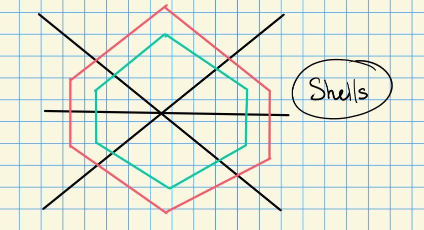

Image

Note that the Euler characteristic is additive on SESs: if $0\to A\to B\to C\to 0$ then $\chi(B) = \chi(A) + \chi(B)$. It is also multiplicative wrt the tensor product: $\chi(A\otimes B) \chi(A) \chi(B)$.

If $\lambda \in X(T)_+$, then $\chi(\lambda) = \operatorname{ch}H^0(\lambda) = \operatorname{ch}(V(0))$.

1. The set $\left\{{\operatorname{ch}L(\lambda) {~\mathrel{\Big|}~}\lambda\in X(T)_+}\right\}$ is a basis for ${\mathbb{Z}}[X(T)]^W$.
2. If $\lambda \in X(T)$ and $\sum a_\mu e^\mu \in {\mathbb{Z}}[X(T)]^W$, then there is a formula:
   $$\begin{align*}
   \chi(\lambda) \qty{ \sum_\mu a_\mu e^\mu } = \sum_\mu a_\mu \chi(\lambda + \mu)
   .\end{align*}$$

Let
$$\begin{align*}
\operatorname{Sym}(\mu) \mathrel{\vcenter{:}}=\sum_{\nu \in W\mu} e^\nu
\end{align*}
be the sum over the \(W\) orbit of \(\mu\). This is clearly \(W{\hbox{-}}\)invariant, so \(\operatorname{Sym}(\mu) \in {\mathbb{Z}}[X(T)]^W\). Since every \(\nu \in X(T)\) is \(W{\hbox{-}}\)conjugate to \(\mu\) (which is dominant), the set \(\left\{{\operatorname{Sym}(\mu) {~\mathrel{\Big|}~}\mu \in X(T)_+}\right\}\) is a basis for \({\mathbb{Z}}[X(T)]^W\), since this set is linearly independent.$$

> Why: conjugate to a unique weight.

Let $\lambda \in X(T)_+$, then

$$\begin{align*}
\operatorname{ch}L(\lambda) = \operatorname{Sym}(\lambda) + \sum_{\substack{\mu < \lambda \\ \mu \in X(T)_+} } a_\mu \operatorname{Sym}(\mu)
.\end{align*}
Thus the transition matrix is unipotent and upper-triangular, thus \(\left\{{\operatorname{ch}L(\lambda) {~\mathrel{\Big|}~}\lambda \in X(T)_+}\right\}\) is a basis for \({\mathbb{Z}}[X(T)]^W\).$$

Since $\left\{{L(\lambda) {~\mathrel{\Big|}~}\lambda\in X(T)_+}\right\}$ forms a basis for ${\mathbb{Z}}[X(T)]^W$, there is some $G{\hbox{-}}$module $V$ such that $\sum a_\mu e^\mu = \pm \operatorname{ch}V$. We can consider a composition series of $V\otimes\lambda$, where the factor $\left\{{\mu \otimes\lambda}\right\}$ appears $a_\mu = \dim V_\mu$ times. We now compute in two different ways:
$$\begin{align*}
\chi(V\otimes\lambda)
&= \operatorname{ch}(V) \chi(\lambda) && \text{using the formula from earlier} \\
&= \chi(\lambda) \qty{ \sum_\mu a_\mu e^\mu }
.\end{align*}$$

On the other hand,
$$\begin{align*}
\chi(V\otimes\lambda) &=
\sum a_\mu \chi(\lambda + \mu)
.\end{align*}$$

The formula used above was
$$\begin{align*}
R^i \mathop{\mathrm{ind}}_B^G (V\otimes\lambda) = V\otimes R^i \mathop{\mathrm{ind}}_B^G(\lambda)
.\end{align*}$$

## 19.1 Weyl’s Character Formula

For any $\alpha\in\Delta$ and $\lambda \in X(T)$ with ${\left\langle {\lambda + \rho},~{\alpha {}^{ \vee }} \right\rangle} \geq 0$. We have an analog of Serre duality:
$$\begin{align*}
\operatorname{ch}\mathop{\mathrm{ind}}_B^{P_\alpha} \lambda = \operatorname{ch}R^i \mathop{\mathrm{ind}}_B^{P_\alpha} s_\alpha \cdot \lambda
,\end{align*}
i.e. the induced module coincides with the Weyl module.$$

By definition of the dot action, we have
$$\begin{align*}
s_\alpha \cdot \lambda = s_\alpha(\lambda + \rho) - \rho
.\end{align*}$$

As in previous calculations, we have

$$\begin{align*}
{\left\langle {s_\alpha\cdot\lambda},~{\alpha {}^{ \vee }} \right\rangle} = -{\left\langle {\lambda+\rho},~{\alpha {}^{ \vee }} \right\rangle} - 1 \leq - 1
.\end{align*}$$

As in the analysis of Bott-Borel-Weil, we have
$$\begin{align*}
H^i(s_\alpha \cdot\lambda) &= H^i( R^1 \mathop{\mathrm{ind}}_B^{P_\alpha} s_\alpha\cdot\lambda ) \\
H^i(\lambda) &= H^i( \mathop{\mathrm{ind}}_B^{P_\alpha}\lambda )
,\end{align*}
since the spectral sequence collapses. Note that the two things appearing on the RHS have the same Euler characteristics.$$

We can thus define define a modified Euler characteristic
$$\begin{align*}
\phi(N) = \sum_{i\geq 0} (-1)^i \operatorname{ch}R^i \mathop{\mathrm{ind}}_{P_\alpha}^G(N)
.\end{align*}$$

and obtain $\chi(\lambda) = -\chi(s_\alpha \cdot \lambda)$. The same argument works for ${\left\langle {\lambda + \rho},~{\alpha {}^{ \vee }} \right\rangle} < 0$.

$$\begin{align*}
\lambda \in X(T) \implies \chi(\lambda) = -\chi(s_\alpha \cdot \lambda)
.\end{align*}$$

$$\begin{align*}
\chi(w\cdot \lambda) = \operatorname{sgn}(w) \chi(\lambda) && \operatorname{sgn}(w) \mathrel{\vcenter{:}}=(-1)^{\ell(w)}
,\end{align*}
with the convention that \(\chi(0) = e^0 = 1\).$$

Let $\lambda \in X(T)$ where $\sum a_\mu e^|mu \in {\mathbb{Z}}[X(T)]^W$, so (as we proved)
$$\begin{align*}
\chi(\lambda) \qty{ \sum_\mu a_\mu e^\mu } = \sum_\mu a_\mu \chi(\lambda + \mu)
.\end{align*}
In the special case \(\lambda = 0\), we have \(\chi(\lambda) = \chi(0) = e^0\), we obtain
\begin{align*}
\sum_\mu a_\mu e^\mu = \sum_\mu a_\mu \chi(\mu)
.\end{align*}$$

Extend this to a field by letting $\lambda \in X(T) \otimes_{\mathbb{Z}}{\mathbb{Q}}$, then define
$$\begin{align*}
A(\lambda) \mathrel{\vcenter{:}}=\sum_{w\in W} \operatorname{sgn}(w) e^{w \lambda} \in {\mathbb{Z}}[ (X(T) \otimes{\mathbb{Q}}]
.\end{align*}$$

Then

1. $w' A(\lambda) = \operatorname{sgn}(w') A(\lambda)$.
2. $A(\mu) A(\lambda) \in {\mathbb{Z}}[X(T) \otimes{\mathbb{Q}}]^W$.

Proof of 1: exercise.

We can compute
$$\begin{align*}
w(A(\mu) A(\lambda) )
&= w A(\mu) w A(\lambda) \\
&= \operatorname{sgn}(w) A(\mu) \operatorname{sgn}(w) A(\lambda) \\
&= \operatorname{sgn}(w)^2 A(\mu) A(\lambda) \\
&= A(\mu) A(\lambda)
.\end{align*}$$

Let $\lambda \in X(T)$ be any weight, then
$$\begin{align*}
\chi(\lambda) = { A(\lambda + \rho) \over A(\rho) }
,\end{align*}
where \(\rho = {1\over 2} \sum_{\alpha \in \Phi^+} \alpha\).$$

> Note: this says that one formal sum divides another.

A corollary is an analog of Weyl’s dimension formula: :::{.corollary title=“?”} Let $\lambda \in X(T)_+$ be a dominant weight. Then
$$\begin{align*}
\operatorname{ch}H^0(\lambda) = { A(\lambda + \rho) \over A(\rho) }
.\end{align*}
:::$$

Big question: suppose $k = \mkern 1.5mu\overline{\mkern-1.5mu{\mathbb{F}}\mkern-1.5mu}\mkern 1.5mu_p$. What are $\operatorname{ch}L(\lambda)$ and $\lambda \in X(T)_+$? We know this for $p\gg 0$, but in general it’s wide open. There are expressions in terms of “$p{\hbox{-}}$bases,” but these are hard to compute. There are only recursive formulas, none that are closed (and these may not exist).

Next time:

- Proof of Weyl’s character formula
- Compute an example.

Idea of the proof: we’ll have some $\chi(\lambda) = \sum_\mu a_\mu e^\mu$. Well also have $A(\rho) \qty{ \sum_\mu a_\mu e^\mu } = A(\lambda + \rho)$. This will reduce to equating coefficients of two formal sums, which will result in a system of linear equations.

# 20 Friday, October 16

## 20.1 Example: Weyl’s Character Formula

Review: suppose the following is invariant under the Weyl group, so $\sum a_\mu e^\mu \in {\mathbb{Z}}[X(T)]^W$. In this case, we have an equality
$$\begin{align*}
\sum a_\mu e^\mu = \sum a_\mu \chi(\mu)
,\end{align*}
where \(\chi(\mu) = \sum_{i\geq 0} (-1)^i \operatorname{ch}H^i(\mu)\). We also had a relation
\begin{align*}
\chi(w\cdot \mu) = (-1)^{\ell(w)} \chi(\mu) = \operatorname{sgn}(w) \chi(\mu)
.\end{align*}$$

Now let $\lambda \in X(T) \otimes{\mathbb{Q}}$, then we defined
$$\begin{align*}
A(\lambda) = \sum_{w\in W} \operatorname{sgn}(w) e^{w\lambda} \in {\mathbb{Z}}[X(T) \otimes{\mathbb{Q}}]
.\end{align*}$$

We obtain

1. $w' A(\lambda) = \operatorname{sgn}(w') A(\lambda)$
2. $A(\mu) A(\lambda) = {\mathbb{Z}}[X(T) \otimes{\mathbb{Q}}]^W$.

$$\begin{align*}
\lambda\in X(T) \implies \chi(\lambda) = {A(\lambda + \rho) \over A(\lambda)}
.\end{align*}$$

As a special case when $\lambda \in X(T)_+$, all higher sheaf cohomology vanishes and thus
$$\begin{align*}
\operatorname{ch}H^0(\lambda) = {A(\lambda + \rho) \over A(\lambda)}
.\end{align*}$$

We first perform a *reindexing* step:
$$\begin{align*}
\sum_{w, w'} \operatorname{sgn}(w\cdot w') e^{w(\lambda+\rho) + w'\rho}
&= \sum_{w, w'} \operatorname{sgn}(w^{-1} w') e^{w(\lambda+\rho) + w'\rho} \\
&= \sum_{w, y} \operatorname{sgn}(y) e^{w(\lambda+\rho) + wy\rho} && y = w^{-1}w' \implies w' = wy \\
&= \sum_{w, y} \operatorname{sgn}(y) e^{w(\lambda + \rho + y\rho)}
.\end{align*}$$

Now let $\lambda\in X(T)$, we then compute
$$\begin{align*}
A(\lambda + \rho) A(\rho)
&=
\sum_{w} \operatorname{sgn}(w) e^{w(\lambda + \rho)}
+ \sum_{w'} \operatorname{sgn}(w') e^{w'(\lambda + \rho)} \\
&=
\sum_{w, w'} \operatorname{sgn}(ww') e^{w(\lambda + \rho) + w'\rho} \\
&=
\sum_{w, w'} \operatorname{sgn}(w') e^{w(\lambda + \rho + w'\rho)} && \text{from reindexing above, setting } y\mathrel{\vcenter{:}}= w' \\
&= \sum_{w, w'} \operatorname{sgn}(w') \chi\qty{w(\lambda + \rho + w'\rho)} \\
&= \sum_{w, w'} \operatorname{sgn}(w') \chi\qty{w\cdot (\lambda + w'\rho + w^{-1} \rho)} && \text{definition of dot action}\\
&= \sum_{w, w'} \operatorname{sgn}(ww') \chi\qty{\lambda + w'\rho + w\rho } && \text{swapping } w\leadsto w^{-1}
.\end{align*}$$

Note that $\chi$ can be introduced since $A(\lambda + \rho)A(\rho) \in {\mathbb{Z}}[X(T) \otimes{\mathbb{Q}}]^{W\cdot}$.

We can now conclude that
$$\begin{align*}
A(\rho)^2 = \sum_{w, w'} \operatorname{sgn}(ww') e^{w\rho + w' \rho}
.\end{align*}
Since this quantity is \(W{\hbox{-}}\)invariant, since it’s a square, we can move the \(\chi\) inside:
\begin{align*}
\chi(\lambda) \qty{ \sum a_\mu e^\mu } = \sum a_\mu \chi(\lambda + \mu) \\
\implies \chi(\lambda) A(\rho)^2 = \sum_{w, w'} \operatorname{sgn}(ww') \chi(\lambda + w\rho + w'\rho)
,\end{align*}
which is exactly what the first calculation resulted in. So we can conclude
\begin{align*}
A(\lambda + \rho) A(\rho) = \chi(\lambda) A(\rho)^2
.\end{align*}
Note that \(A(\rho) \neq 0\) since \(w\rho \neq \rho\) unless \(w=\operatorname{id}\). Thus we are actually working in \({\mathbb{Z}}[X(T) + {\mathbb{Z}}\rho]\), which is an integral domain, and thus we can apply cancellation laws to obtains
\begin{align*}
A(\lambda + \rho) = \chi(\lambda) A(\rho)
.\end{align*}$$

Let $G = \operatorname{GL}_3(k)$, which has a natural 3-dimensional representation $V$. Let $\lambda = (1,0,0)$, so $L(1,0,0) = V$. This is a polynomial representation, so by permuting we can obtain
$$\begin{align*}
\operatorname{ch}V = e^{(1,0,0)} + e^{(0,1,0)} + e^{(0,0,1)} = \chi(1,0,0)
,\end{align*}
where the last equality holds since \(\lambda\) is dominant.$$

We can write $\rho = (2,1,0)$, since the fundamental weights are given by $w_1 = (1,0,0)$ and $w_2 = (1,1,0)$ (since we’re in an ${\operatorname{SL}}_2$ and/or $A_2$ situation). We then obtain $\lambda + \rho = (3,1,0)$, and since $W= S_3$,
$$\begin{align*}
A(\lambda + \rho) = \sum_{w\in W} \operatorname{sgn}(w) e^{w(\lambda + \rho)}
=
e^{(3,1,0)} -
e^{(1,3,0)} +
e^{(1,0,3)} -
e^{(0,1,3)} +
e^{(0,3,1)} -
e^{(3,0,1)}
.\end{align*}$$

Thus
$$\begin{align*}
A(\rho) =
e^{(2,1,0)} -
e^{(1,2,0)} +
e^{(1,0,2)} -
e^{(0,1,2)} +
e^{(0,2,1)} -
e^{(2,0,1)}
.\end{align*}$$

We can then compute
$$\begin{align*}
\chi(1,0,0) A(\rho) = &e^{(3,1,0)}
- e^{(2,2,0)} +
e^{(2,0,2)}
-e^{(1,1,2)} +
e^{(1,2,1)}
- e^{(3,0,1)} +
\\
&e^{(2,2,0)} -
e^{(1,3,0)} +
e^{(1,1,2)} -
e^{(0,2,2)} +
e^{(0,3,1)} -
e^{(2,1,1)} +
\\
&e^{(2,1,1)} -
e^{(1,2,1)} +
e^{(1,0,3)} -
e^{(0,1,3)} +
e^{(0,2,2)} -
e^{(2,0,2)}
.\end{align*}$$

After cancellation, you’ll find that this expression is equal to $A(\lambda + \rho)$.

## 20.2 Strong Linkage Principle

We’ll consider representations in characteristic zero, so we can take $k={\mathbb{C}}$. Let $G$ bet a complex simple group, ${\mathfrak{g}}= \operatorname{Lie}(G)$, $t$ a maximal torus, $X$ the weights, and $X_+$ the dominant weights. We have a correspondence
$$\begin{align*}
\left\{{\substack{(g, t)}}\right\} \iff
\left\{{\substack{(\Phi, W)}}\right\}
\end{align*}$$

where $\Phi$ is an irreducible root system and $W$ is the Weyl group. We’ll have a set of simple roots $\Delta\subseteq \Phi^+$. For $\lambda\in X$, we have
$$\begin{align*}
Z(\lambda) = U({\mathfrak{g}}) \otimes_{U({\mathfrak{b}}^+)} \lambda \twoheadrightarrow L(\lambda)
.\end{align*}$$

Then $\lambda \in X_+ \iff L(\lambda)$ is finite dimensional. We have $W$ acting on $X$ via reflections, which we can extend to a dot action
$$\begin{align*}
w\cdot \lambda = w(\lambda + \rho) - \rho, \hspace{4em} \rho = {1\over 2}\sum_{\alpha\in\Phi^+} \alpha
.\end{align*}$$

We define Category ${\mathcal{O}}$ which has objects ${\mathfrak{g}}{\hbox{-}}$modules with a weight space decomposition which is locally finite wrt ${\mathfrak{n}}^+$.

### 20.2.1 Linkage in Category ${\mathcal{O}}$

Set $Z(\lambda) = \Delta(\lambda)$, then
$$\begin{align*}
[Z(\lambda) : L(\mu)] \neq 0 \implies \lambda \in W\cdot \mu
.\end{align*}
The LHS is computed by evaluating certain Kazhdan-Lusztig polynomials at \(x=1\).$$

Let $\Phi= A_2$, then

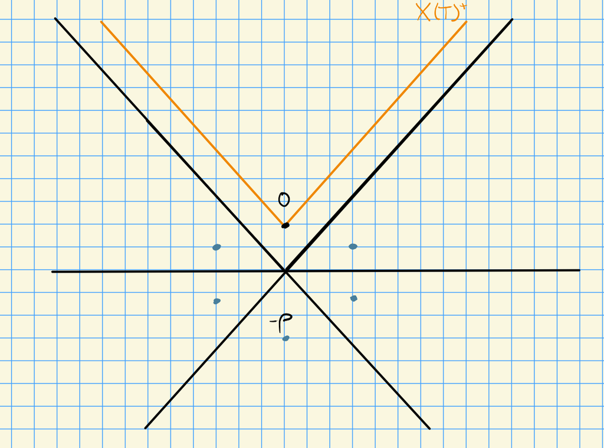

Image

${\mathcal{O}}_0$ is the principal block, and the irreducibles correspond to $\left\{{L(w\cdot 0) {~\mathrel{\Big|}~}w\in W}\right\}$, and the number of irreducibles in given by ${\left\lvert {W} \right\rvert}$. In this case, there is only 1 finite-dimensional module in any given block of category ${\mathcal{O}}$.

For $\Phi = A_1$, we have the following situation:

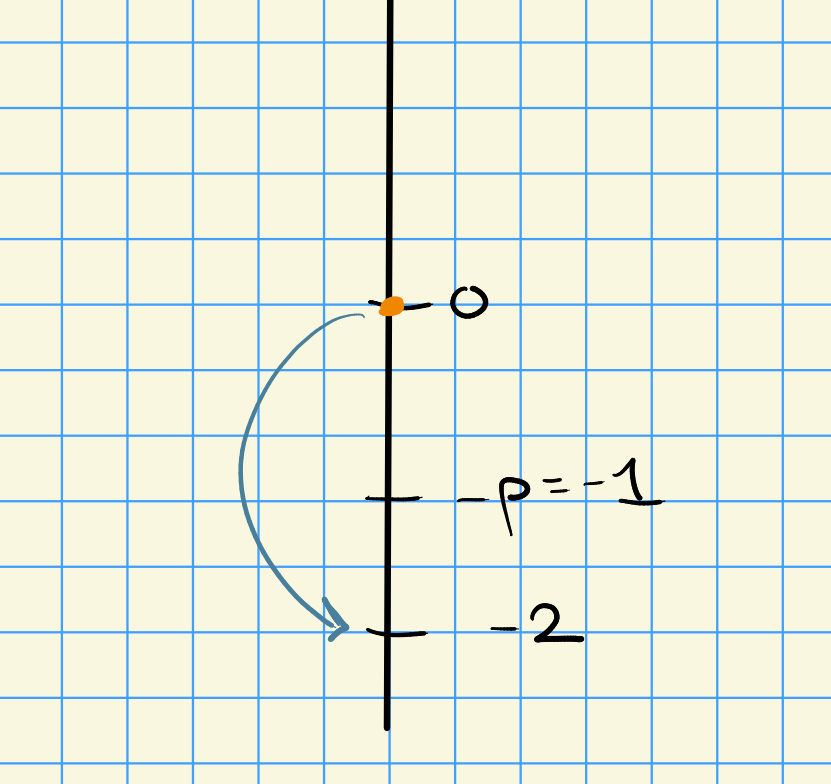

Image

In ${\mathcal{O}}_0$, there are two irreducible representations given by the Verma modules $L(0), L(-2)$, and we find that

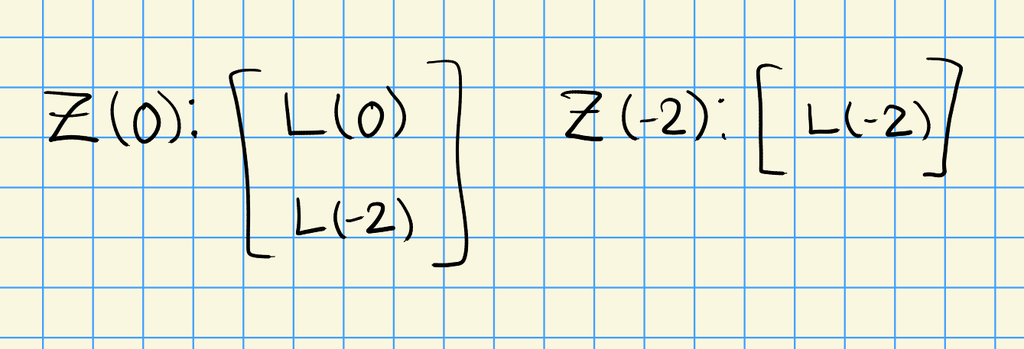

Image

In this case, the projectives are given by

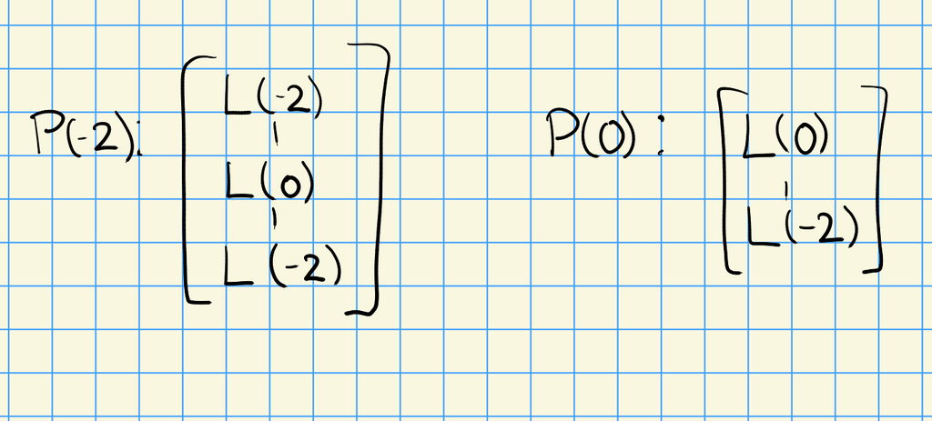

Image

# 21 Monday, October 19

## 21.1 Representations in Positive Characteristic

We have the following setup:
$$\begin{align*}
G && \text{a semisimple, simply connected algebraic group} \\
k && \text{an algebraically closed field of characteristic $p>0$} \\
T && \text{a maximal torus} \\
B && \text{a Borel (negative roots)} \\
X(T) = X && \text{weights} \\
X(T)_+ = X_+ && \text{dominant weights} \\
\Phi && \text{roots}
.\end{align*}$$

For $\lambda \in X_+$, we consider the induced module $H^0(\lambda) = \mathop{\mathrm{ind}}_B^G \lambda$. Not that this is not a simple module in general, so we instead ask about its composition factors.

Question: For all $\lambda, \mu \in X_+$, what are the multiplicities $[H^0(\lambda): L(\mu)]$.

Let $G = {\operatorname{SL}}_2(k)$, so $\Phi = A_1$. Then $\lambda \in X_+ = \left\{{0,1,2,\cdots}\right\}$ as we know from standard facts in lie algebras. Define $X_1 = \left\{{0, 1, \cdots, p-1}\right\}$, then $\dim H^0(\lambda) = \lambda + 1$. We can write the weight $p{\hbox{-}}$adically as $\lambda = \sum_{i=0}^t \lambda_i p^i$ for some $\lambda_j\in X_1$. Thus $L(\lambda) = L(\lambda_0) \bigotimes_{i=1}^t L(\lambda_i)^{(i)}$.

Consider $p=3, \lambda = 7$, then $\dim H^0(7) = 8$. We can write $7$ 3-adically as $7 = (1)3^0 + (2)3^1$, and so
$$\begin{align*}
L(7) \cong L(1) \otimes L(2)^{(1)}
.\end{align*}
The first summand is 2-dimensional, and the second is 3-dimensional, so \(L(7)\) is 6-dimensional. Note that \(L(7) \hookrightarrow H^0(7)\).$$

We can calculate the weights in the tensor product: the first has weights $\left\{{\pm 1}\right\}$, we take the adjoint weights in the second factor and multiply by the twist 3 to get $\left\{{2\cdot 3, 0\cdot 3, -2\cdot 3}\right\}$. Taking all combinations of sums from these yields $\left\{{7,5,1,-1,-5,-7}\right\}$.

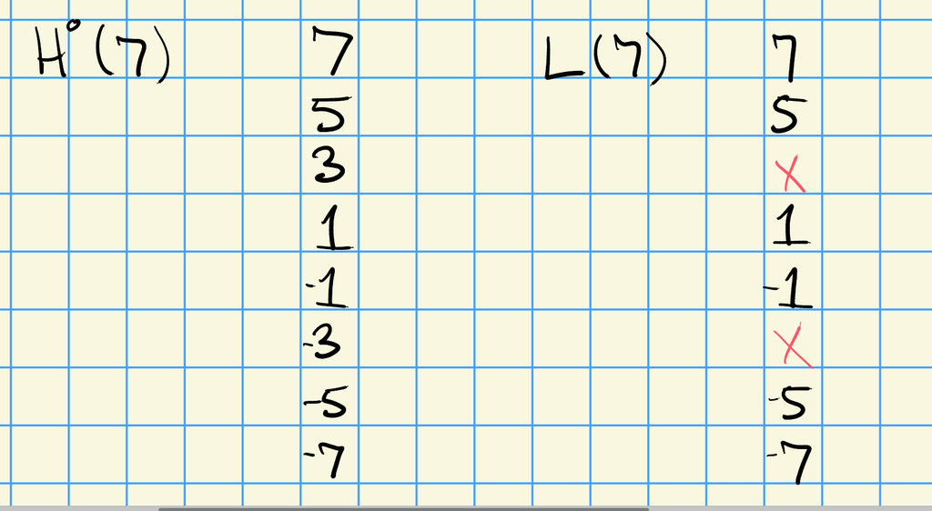

Comparing what’s left over

Note the difference to Verma modules in category ${\mathcal{O}}$: we have to consider the action of the *affine* Weyl group, where $W_a \mathrel{\vcenter{:}}= W \rtimes p{\mathbb{Z}}\Phi$. Here we have hyperplanes at $p-1, 2p-1, 3p-1$, and 7 is *linked* to 3 (in the same orbit) for this action:

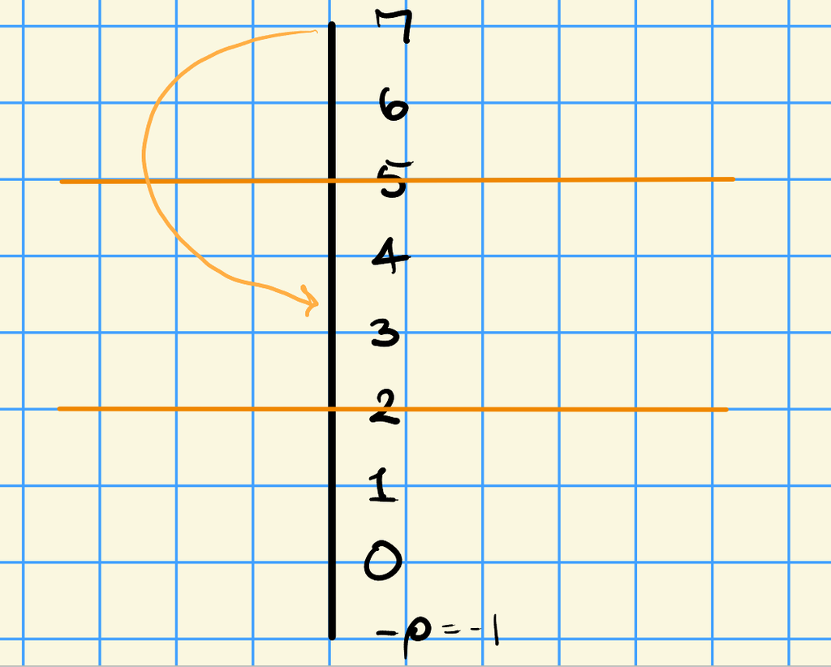

Image

> Once characters are known, can find composition factors.

## 21.2 Affine Weyl Group

Letting $a\in {\mathbb{N}}$, we have $W_a = W\rtimes a({\mathbb{Z}}\Phi)$ where ${\mathbb{Z}}\Phi$ is the root lattice. Note that there are other variants:

- $W_a = W\rtimes a({\mathbb{Z}}\Phi {}^{ \vee })$,
- $W_{\text{ext}} = W \rtimes X(T)$.

So we set $W_p = W\rtimes p({\mathbb{Z}}\Phi)$ where $p$ is a prime. What’s in this group? We know it contains “products” of reflections with translations. We find that $W_p$ is generated by
$$\begin{align*}
s_{\beta, np}(\lambda) = \lambda - {\left\langle {\lambda},~{\beta {}^{ \vee }} \right\rangle}\beta + np \beta
.\end{align*}$$

It is also the case that $W_p$ acts on $X(T)$ and there exists a dot action
$$\begin{align*}
w\cdot \lambda = w(\lambda + \rho) - \rho
.\end{align*}$$

Consider $A_1$, so $\alpha = 2$. We consider what the stabilizer is:
$$\begin{align*}
s_{\alpha, np}\cdot \lambda &= \lambda \\
s_{\alpha, np}(\lambda + \rho) - \rho &= \lambda \\
(\lambda + \rho) - {\left\langle {\lambda _ \rho},~{\alpha {}^{ \vee }} \right\rangle}\alpha + np\alpha - \rho &= \lambda
.\end{align*}$$

After cancellation in the last line above, we obtain
$$\begin{align*}
\lambda = np-1
,\end{align*}
which exactly yields the \(p-1, 2p-1, \cdots\) we saw before.$$

Consider $A_2$. We obtain “alcoves”:

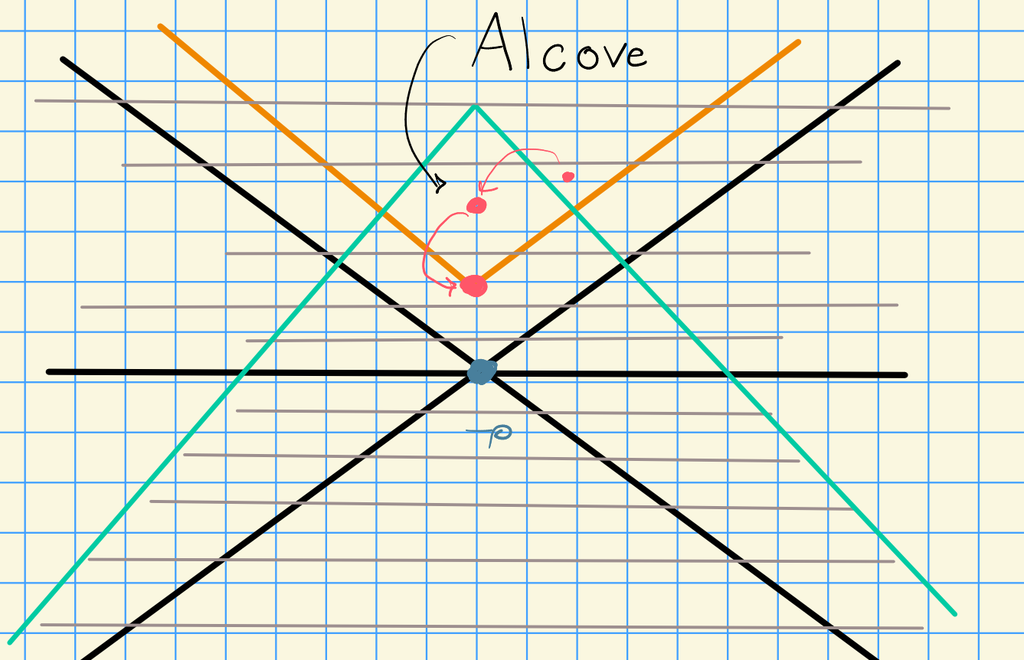

Image

We can get a stronger version of weak linkage, which we’ll just call linkage:

$$\begin{align*}
[H^0(\lambda): L(\mu)] \neq 0 \implies \lambda \in W_p \cdot \mu
.\end{align*}$$

These are difficult to compute in general, or to even detect when they’re zero. For $p\gg 0$, these multiplicities are computed via Kazhdan-Lusztig polynomials.

### 21.2.1 Ordering of Weights

There is a partial ordering on the weight lattice given by
$$\begin{align*}
\mu \leq \lambda \iff \lambda - \mu = \sum_{\alpha\in \Phi^+} n_\alpha \alpha, \quad n_\alpha \geq 0
.\end{align*}$$

For $\mu, \lambda \in X(T)$, we say $\mu$ is **strongly linked** to $\lambda$, denoted $\mu \uparrow \lambda$, if there exists a sequence of weights $\mu_1, \cdots, \mu_r \in X(T)$ and reflections $s_1, \cdots, s_r$ such that
$$\begin{align*}
\mu \leq \mu_1 = s_1 \cdot \mu \leq \mu_2 = s_2\cdot \mu 1 \leq \cdots \leq s_r \mu_{r-1}
.\end{align*}$$

Note that

- $\mu \uparrow \lambda \implies \mu \leq \lambda$, so this is stronger than the usual linkage
- $\mu \uparrow \lambda \implies \mu \in W_p \cdot \lambda$.

$$\begin{align*}
[H^0(\lambda): L(\mu)] \neq 0 \implies \lambda \in \mu \uparrow \lambda
.\end{align*}$$

Moreover, there is a version of strong linkage for $H^i(\lambda)$ for $i> 1$.

> Next time: history of strong linkage, and translation functors.

# 22 Wednesday, October 21

## 22.1 Strong Linkage

Let $G$ be a semisimple algebraic group and $k = \mkern 1.5mu\overline{\mkern-1.5mu{\mathbb{F}}_p\mkern-1.5mu}\mkern 1.5mu$. We found that the *affine Weyl group* $W_p$ played an important role here.

Suppose we have a nonzero composition factor in the induced/Weyl module. Then
$$\begin{align*}
[H^0 \lambda : L(\mu)] \neq 0]\implies \mu \uparrow \lambda
.\end{align*}$$

In other words, there’s a series of reflections sending $\mu$ to $\lambda$ which doesn’t increase it’s value in the ordering.

Let $\lambda \in X(T)$ with ${\left\langle {\lambda + \rho},~{\alpha {}^{ \vee }} \right\rangle} \geq 0$ for all $\alpha\in \Delta$. Suppose $\mu \in X(T)_+$.
$$\begin{align*}
[H^i w\cdot \lambda : L(\mu)] \neq 0 \text{ for some } i\geq 0 \implies \mu \uparrow \lambda
.\end{align*}$$

Note that this is tells us slightly more than Bott-Borel-Weil.

There is some history here:

1. Verma conjectured the first theorem in 1971.
2. Humphreys (1971) proved it for $Z_r(\lambda) = \mathop{\mathrm{ind}}_{B_r}^{G_r} \lambda$.
3. Strong Linkage II proved by Andersen in 1980.
4. Jantzen proved strong linkage for $Z_r$, which implies strong linkage for $V(\lambda)$.
5. Doty (1987) proved strong linkage for $Z_r(\lambda)$ as a $G_rT{\hbox{-}}$modules, which implies strong linkage for $V(\lambda)$.

One application is the following: let $\lambda, \mu \in X(T)_+$, then $\operatorname{Ext} _G^n(L(\lambda), L(\mu)) \neq 0$ for some $n \geq 0$. This implies that $\lambda \in W_p \cdot \mu$.

We can consider some cases

- If $n=0$, we’re reduced to previous situations.
- If $n=1$, we can conclude that $L(\lambda)$ is in the second socle layer of $H^0 \mu$, or vice-versa. In either case, $\lambda \in W_p \cdot \mu$.

We can compute this ext by considering an minimal injective resolution
$$\begin{align*}
0 \to L(\mu) \to I_0 = I(\mu) \to I_1 \to \cdots
.\end{align*}$$

We can conclude that
$$\begin{align*}
[I(\mu) : H^0(\sigma)] = [H^0(\sigma): L(\mu)] \neq 0
.\end{align*}
by Brauer-Humphreys reciprocity, so \(\sigma \in W_p \cdot \mu\). Similarly \([I(\mu): L(\gamma)] \neq 0\) implies that \(\gamma \in W_p \cdot \mu\), and continuing in this way we can write
\begin{align*}
I_1 = \bigoplus_{j=1}^t I(\gamma_j)
\text{ with each }
\gamma_j \in W_p \cdot \mu
.\end{align*}
So all of these weights are strongly linked to \(\mu\).$$

But then we know $\operatorname{Ext} _G^n (L(\lambda), L(\mu)) \neq 0$ is a subquotient of $\hom_G(L(\lambda), I_n)$, which thus can not be zero. So $\lambda \in W_p \cdot \mu$

## 22.2 Translation Functors

Consider the case from category ${\mathcal{O}}$, e.g. by taking ${\mathfrak{g}}= {\mathfrak{sl}}_3({\mathbb{C}})$:

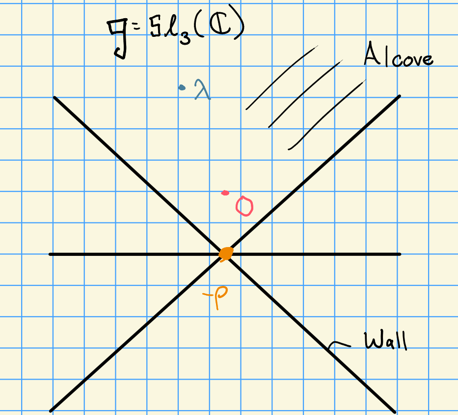

Image

For $\lambda$ a regular weight, the principal block $\mathcal{B}_0$ is Morita-equivalent to $\mathcal{B}_\lambda$. If $\mu$ is a singular weight, then by Jantzen there are translation functors

$$\begin{align*}
T_\lambda^\mu: \mathcal{B}_\lambda &\to \mathcal{B}_\mu \\
T_\mu^\lambda: \mathcal{B}_\mu &\to \mathcal{B}_\lambda
.\end{align*}$$

In the case where $G$ is a semisimple algebraic group and $k = \mkern 1.5mu\overline{\mkern-1.5mu{\mathbb{F}}\mkern-1.5mu}\mkern 1.5mu_p$, we have the following picture instead:

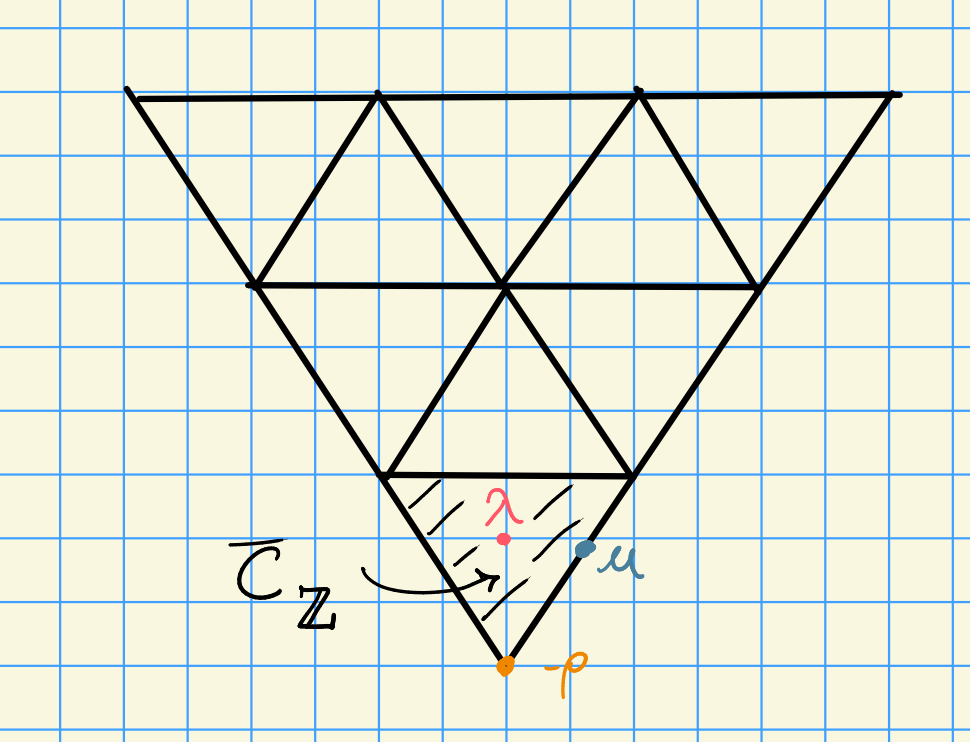

Image

### 22.2.1 Blocks

Two simple modules $S, T$ are in the same *block* if we have a sequence $T_1, \cdots, T_n$ such that $S=T_1$ and $T_n = T$ where $\operatorname{Ext} ^1(T_i, T_{i+1}) \neq 0$.

Let $M, M'$ be $H{\hbox{-}}$modules and $\mathcal{B}(H)$ be the blocks of $H$. Then

1. $M = \bigoplus_{b\in \mathcal{B}(H)} M_b$ where $M_b = \sum_{M'\leq M} M'$ the sum of all submodules such that $M$ has composition in the block $b$.
2. $$\begin{align*} \operatorname{Ext} _H^i(, M') = \prod_{b\in\mathcal{B}(H)} \operatorname{Ext} _H^i (M_b, M_b') \end{align*}$$

So the question becomes, what are the blocks of $H$? Let $\lambda \in X(T)_+$, so we can define $L(\lambda)$, and let $b(\lambda)$ be the $G{\hbox{-}}$block containing $L(\lambda)$.

We have $b(\lambda) \in \mathcal{B}(G)$ and $b(\lambda)$ $\subseteq X(T)_+ \cap W_p \cdot \lambda$, i.e. we have strong linkage.

> Here we refer to $b(\lambda)$ as both the block and the weights it contains.

Let $\lambda \in X(T)_+$ be a dominant weight and let $r\in {\mathbb{Z}}$ be the largest integer such that $p^r \divides {\left\langle { \lambda + \rho},~{\alpha {}^{ \vee }} \right\rangle}$ for all $\alpha\in \Phi$. Then
$$\begin{align*}
b(\lambda) = W_p^{(r)} \cdot \lambda \cap X(T)_+ \text{ where } W_p^{(r)} = W\rtimes p^r {\mathbb{Z}}\Phi
.\end{align*}$$

Let $B$ be a $G{\hbox{-}}$module and $\lambda \in X(T)$. Set ${\operatorname{pr}}_\lambda V$ to be the sum of all submodules of $V$ with composition factors of the form $L(\mu)$ where $\mu \in W_p \cdot \lambda$. Then

- $V = \bigoplus_{\lambda \in Z} {\operatorname{pr}}_\lambda V$ where $Z$ are representatives of the $W_p$ orbits, i.e. one representative from each alcove in the weight lattice.
- $$\begin{align*} \operatorname{Ext} _G^i(V, V') = \prod_{\lambda \in Z} \operatorname{Ext} _G^i ({\operatorname{pr}}_\lambda V, {\operatorname{pr}}_\lambda V') \end{align*}$$
- The projection functors ${\operatorname{pr}}_\lambda({-})$ are exact.

> Note that this still works for singular weights, not just regular weights.

We can compute
$$\begin{align*}
{\operatorname{pr}}_\lambda L(\mu) =
\begin{cases}
0 &= \lambda \not\in W_p \cdot \mu \\
L(\mu) &= \lambda \in W_p \cdot \mu
\end{cases}
.\end{align*}$$

Similarly, by strong linkage,
$$\begin{align*}
{\operatorname{pr}}_\lambda H^i(\mu) =
\begin{cases}
0 &= \lambda \not\in W_p \cdot \mu \\
H^i(\mu) &= \lambda \in W_p \cdot \mu
\end{cases}
.\end{align*}$$

Recall that
$$\begin{align*}
\mkern 1.5mu\overline{\mkern-1.5muC\mkern-1.5mu}\mkern 1.5mu_{\mathbb{Z}}\mathrel{\vcenter{:}}=\left\{{
\lambda \in X(T) {~\mathrel{\Big|}~}
0 \leq {\left\langle {\lambda + \rho},~{\beta {}^{ \vee }} \right\rangle} \leq p \,\, \forall \beta\in\Phi^+
}\right\}
.\end{align*}
For every \(\mu, \lambda \in \mkern 1.5mu\overline{\mkern-1.5muC\mkern-1.5mu}\mkern 1.5mu_{\mathbb{Z}}\), consider \(\mu - \lambda \in X(T)\). Then there is a way to conjugate it under the ordinary \(W\) action to land in the dominant region, i.e. some unique \(\nu\) such that \(\nu \in X(T)_+ \cap W(\mu - \lambda)\).$$

Define
$$\begin{align*}
T_\lambda^\mu V =
{\operatorname{pr}}_\mu
\qty{
L(\nu) \otimes
{\operatorname{pr}}_\lambda V
}
.\end{align*}$$

So project to $\lambda$, tensor with an irreducible representation, then project to $\mu$. This is an exact functor
$$\begin{align*}
T_{\lambda}^\mu: G{\hbox{-}}\mathrm{mod} &\to G{\hbox{-}}\mathrm{mod}
.\end{align*}$$

Next time: we’ll show that $T_\lambda^\mu$ and $T_\mu^\lambda$ form an adjoint pair. Note that if $\mu, \lambda$ are in the same block, these are the exact functor which product the categorical equivalence.

# 23 Friday, October 23

## 23.1 Facets

$W_p$ has a dot action on $E \mathrel{\vcenter{:}}= X(T) \otimes_{\mathbb{Z}}{\mathbb{R}}$.

We can write $\Phi^+ = \Phi_0^+ \cup\Phi_1^+$, and define the *facet* as
$$\begin{align*}
F \mathrel{\vcenter{:}}=\left\{{
\lambda \in E {~\mathrel{\Big|}~}{\left\langle {\lambda + \rho},~{\alpha {}^{ \vee }} \right\rangle} = n_\alpha p\,\, \forall\alpha\in \Phi_0^+(F),\,\,
(n_\alpha - 1)p < {\left\langle {\lambda + \rho},~{\alpha {}^{ \vee }} \right\rangle} < n_\alpha p \,\,\forall \alpha\in \Phi_1^+(F)
}\right\}
.\end{align*}
The first condition corresponds to being on a vertex in the following diagram, while the second corresponds to being in the interior of a triangle:$$

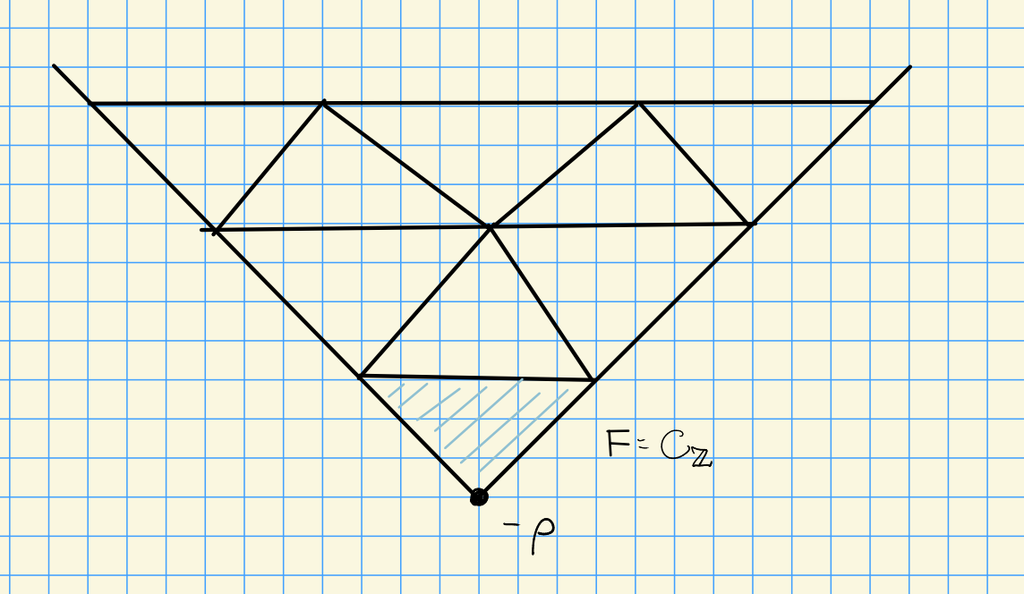

Image

The *closure* of a facet is defined by replacing the second condition with an inequality.
$$\begin{align*}
\mkern 1.5mu\overline{\mkern-1.5muF\mkern-1.5mu}\mkern 1.5mu \mathrel{\vcenter{:}}=\left\{{
\lambda \in E {~\mathrel{\Big|}~}{\left\langle {\lambda + \rho},~{\alpha {}^{ \vee }} \right\rangle} = n_\alpha p\,\,
\forall\alpha\in \Phi_0^+(F),\,\,
n_\alpha - 1 \leq {\left\langle {\lambda + \rho},~{\alpha {}^{ \vee }} \right\rangle} \leq n_\alpha p
\,\,\forall \alpha\in \Phi_1^+(F)
}\right\}
.\end{align*}
This includes all of the walls of the triangle.$$

Finally, we define the *upper closure* by replacing one inequality with a strict inequality:
$$\begin{align*}
\widehat{F} \mathrel{\vcenter{:}}=\left\{{
\lambda \in E {~\mathrel{\Big|}~}{\left\langle {\lambda + \rho},~{\alpha {}^{ \vee }} \right\rangle} = n_\alpha p\,\, \forall\alpha\in \Phi_0^+(F),\,\,
n_\alpha - 1 < {\left\langle {\lambda + \rho},~{\alpha {}^{ \vee }} \right\rangle} \leq n_\alpha p \,\,\forall \alpha\in \Phi_1^+(F)
}\right\}
.\end{align*}$$

A facet is called an **alcove** for $W_p$ iff $\Phi_0^+(F) = \emptyset$.

Note that if $F$ is an alcove for $W_p$, then $\widehat{F}$ is a fundamental domain for $W_p\curvearrowright E$ with the dot action.

## 23.2 Translation Functors

Let $\lambda, \mu\in \mkern 1.5mu\overline{\mkern-1.5muC\mkern-1.5mu}\mkern 1.5mu_{\mathbb{Z}}$, and define
$$\begin{align*}
T_\lambda^\mu({-}) \mathrel{\vcenter{:}}=
{\operatorname{pr}}_\mu \qty{ L(\nu_1) \otimes{\operatorname{pr}}_\lambda({-}) }\\
\text{where }
\nu_1 \in X(T)_+ \cap W(\mu-\lambda)
.\end{align*}$$

This is exact as a composition of exact functors, since we’re tensoring over a field and taking projections (which are themselves exact).

Let $\lambda,\mu\in X(T)$ and $M$ be a finite-dimensional $G{\hbox{-}}$module. Then the functors
$$\begin{align*}
F({-}) &\mathrel{\vcenter{:}}={\operatorname{pr}}_\mu \circ \qty{M\otimes_k {-}} \circ {\operatorname{pr}}_\lambda \\
G({-}) &\mathrel{\vcenter{:}}={\operatorname{pr}}_\lambda \circ \qty{M {}^{ \vee }\otimes_k {-}} \circ {\operatorname{pr}}_\mu \\
\end{align*}
define an adjoint pair, i.e.
\begin{align*}
\hom_\mathcal{C}(G({-}), A) &= \hom_\mathcal{D}({-}, F(A)) \\
\hom_\mathcal{C}({-}, G(A)) &= \hom_\mathcal{D}( F({-}), {-}) \\
.\end{align*}$$

Let $V, V'$ be $G{\hbox{-}}$modules. Then
$$\begin{align*}
\hom_G(FV, V')
&= \hom_G( {\operatorname{pr}}_\mu\qty{ M\otimes{\operatorname{pr}}_\lambda V }, V') \\
&= \hom_G( M\otimes{\operatorname{pr}}_\lambda V , {\operatorname{pr}}_\mu V') \\
&= \hom_G( {\operatorname{pr}}_\mu \qty{ M\otimes{\operatorname{pr}}_\lambda V } , {\operatorname{pr}}_\mu V') \\
&= \hom_G( {\operatorname{pr}}_\lambda V , M {}^{ \vee }\otimes_k {\operatorname{pr}}_\mu V') \\
&= \hom_G( {\operatorname{pr}}_\lambda V , {\operatorname{pr}}_\lambda\qty{ M {}^{ \vee }\otimes_k {\operatorname{pr}}_\mu V'} ) \\
&= \hom_G( V , {\operatorname{pr}}_\lambda\qty{ M {}^{ \vee }\otimes_k {\operatorname{pr}}_\mu V'} ) \\
&= \hom_G(V, GV')
.\end{align*}$$

Here we’ve used the fact that there no nontrivial homs between distinct blocks.

Let $\lambda, \mu \in \mkern 1.5mu\overline{\mkern-1.5muC\mkern-1.5mu}\mkern 1.5mu_{\mathbb{Z}}$ are in the closure of the bottom alcove. Then $T_\lambda^\mu \leftrightarrows T_\mu \lambda$ form an adjoint pair.

Applying the previous corollary, we just need to show the last equality in the following:
$$\begin{align*}
T_\lambda^\mu({-})
&= {\operatorname{pr}}_\mu \qty{ L(\nu_1) \otimes{\operatorname{pr}}_\lambda({-}) } \\
&= {\operatorname{pr}}_\lambda \qty{ L(\nu_1) {}^{ \vee }\otimes{\operatorname{pr}}_\mu({-}) } \\
&=_? T_\mu^\lambda
.\end{align*}$$

This requires checking the highest weight condition on $L(\nu_1) {}^{ \vee }= L(-w_0 \nu_1)$. We know $\nu_1 \in X(T)_+ \cap W(\mu-\lambda)$, so if $\nu_1 = w(\mu-\lambda)$, we have $-w_0 \nu_1 = w_0 w (\lambda - \mu) \in W(\lambda - \mu)$. Since $-w_0 \nu_1 \in X(T)_+$, this verifies the condition.

The adjointness can be extended from homs to exts:
$$\begin{align*}
\operatorname{Ext} _G^i(T_\mu^\lambda V, V' ) \cong \operatorname{Ext} _G^i(V, T_\lambda^\mu V')
.\end{align*}$$

## 23.3 Technical Preliminaries

1. If $\lambda \in X(T)$ and
   $$\begin{align*}
   \sum_\mu a(\mu) e^\mu \in {\mathbb{Z}}[X(T)]^W
   \end{align*}
   is \(W{\hbox{-}}\)invariant, then we proved that
   \begin{align*}
   \chi(\lambda)
   \qty{
   \sum_\mu a(\mu) e^{\mu}
   }
   = \sum_\mu a(\mu) \chi(\lambda + \mu)
   .\end{align*}$$
2. If ${\operatorname{pr}}_\lambda V = V$, then we have
   $$\begin{align*}
   \operatorname{ch}(M\otimes V)
   &= \operatorname{ch}(M) \operatorname{ch}(V) \\
   &= \operatorname{ch}(M) \qty{\sum_{w\in W_p} a_w \chi(w\cdot\lambda) } \\
   &= \qty{ \sum_{\nu \in X(T)} \dim M_\nu e^\nu } \qty{\sum_{w\in W_p} a_w \chi(w\cdot\lambda) }
   .\end{align*}$$

Let $V$ be a finite dimensional $G{\hbox{-}}$module with ${\operatorname{pr}}_\lambda V = V$. Write
$$\begin{align*}
\operatorname{ch}(V) = \sum_{w\in W_p} a_w \chi(w\cdot \lambda) \quad
a_w\in {\mathbb{Z}},\, \text{cofinitely zero}
.\end{align*}
Then
\begin{align*}
\operatorname{ch}\qty{{\operatorname{pr}}_\lambda \qty{ M\otimes V } } =
\sum_{w\in W} a_w \qty{ \sum_{\substack{ \nu \in X(T) \\ \lambda + \nu \in W_p\cdot \mu} } \dim M_\nu } \chi(w\cdot (\lambda + \nu) )
.\end{align*}$$

Using (1) and (2), we can write
$$\begin{align*}
\operatorname{ch}(M\otimes V) =
\sum_{w\in W_p} a_w \sum_\nu \dim M_\nu \chi(w\cdot \lambda + \nu)
.\end{align*}
Note that \(w\cdot \lambda + \nu = w\cdot (\lambda + w_1 \nu)\) where \(w_1 \mathrel{\vcenter{:}}= w^{-1}\), using the fact that the dot action acts linearly on the second term. This comes from the following computation:
\begin{align*}
w\cdot(\mu_1 + \mu_2)
&= w(\mu_1 + \mu_2 - \rho) + \rho \\
&= w(\mu_1 + \rho) - \rho + w\mu_2 \\
&= w\cdot \mu_1 + w\mu_2
.\end{align*}$$

We can thus write
$$\begin{align*}
\operatorname{ch}(M\otimes V) =
\sum_{w\in W_p} a_w \qty{ \sum_\nu \dim M_\nu \chi(w\cdot \qty{\lambda + \nu})}
,\end{align*}
since summing over \(\nu\) is the same as summing over \(w\nu\) for any \(w\).$$

To get $\operatorname{ch}({\operatorname{pr}}_\mu(M\otimes V))$, take $\chi(w(\lambda + \nu))$ and note that $\lambda + \nu \in W_p \cdot \mu$.

Given $\operatorname{ch}V$, one can write $\operatorname{ch}T_\lambda^\mu V$. What will be important here are stabilizers. If $\lambda$ is on a wall, the stabilizer fixes the corresponding hyperplane.

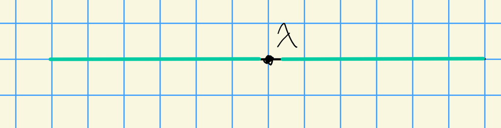

Image

# 24 Monday, October 26

## 24.1 Review

Let $\lambda,\mu \in \mkern 1.5mu\overline{\mkern-1.5muC\mkern-1.5mu}\mkern 1.5mu_{\mathbb{Z}}$ and $\nu_1 \in X(T)_+ \cap W(\mu-\lambda)$. Then

1. $\lambda + w\nu \not\in W_p\cdot \mu$ for any $w\in W$ and $\nu < \nu_1$.
2. If $w\in W$ and $\lambda + w\nu_1 \in W_p \cdot \mu$ (which can happen), then there exists some $w_1\in W_p$ such that
- $w_1\cdot \lambda = \lambda$, so it stabilizes $\lambda$,
- $w_1\cdot \mu = \lambda + w\nu_1$

## 24.2 Characters of Translated Modules

Goal: find $\operatorname{ch}T_\lambda^\mu V$.

Let $\lambda, \mu \in \mkern 1.5mu\overline{\mkern-1.5muC\mkern-1.5mu}\mkern 1.5mu_{\mathbb{Z}}$ and $V$ be a finite-dimensional module with ${\operatorname{pr}}_\lambda V = V$. Write
$$\begin{align*}
\operatorname{ch}(V) = \sum_{w\in W_p} a_w \chi(w\cdot \lambda)
,\end{align*}
where \(a_w\in {\mathbb{Z}}\) and this is a finite sum. Then
\begin{align*}
\operatorname{ch}(T_\lambda^\mu V) =
\sum_{w\in W_p} a_w \qty{
\sum_{w_1\in S} \chi(ww_1\cdot \mu)
},
\end{align*}
where \(S\) is a set of coset representatives for the group
\begin{align*}
{\operatorname{Stab}}_{W_p}(\lambda) \over {\operatorname{Stab}}_{W_p}(\mu) \cap {\operatorname{Stab}}_{W_p}(\lambda)
\end{align*}$$

We can write
$$\begin{align*}
\operatorname{ch}(T_\lambda^\mu V)
&= \operatorname{ch}\qty{{\operatorname{pr}}_\mu\qty{L(\nu_1) \otimes{\operatorname{pr}}_\lambda V } } \\
&= \operatorname{ch}\qty{{\operatorname{pr}}_\mu\qty{L(\nu_1) \otimes V } } \\
&= \sum_{w\in W_p} a_w \qty{\sum_\nu \dim L(\nu_1)_\nu \chi(w\cdot(\lambda + \nu)) }\\
&= \sum_{w\in W_p} a_w \qty{ \sum_\nu \dim L(\nu_1)_\nu \chi(w\cdot\lambda + \nu) }
.\end{align*}$$

We need $\lambda + \nu\in W_p\cdot \mu$ and $\nu \leq \nu_1$ to apply the technical lemma.

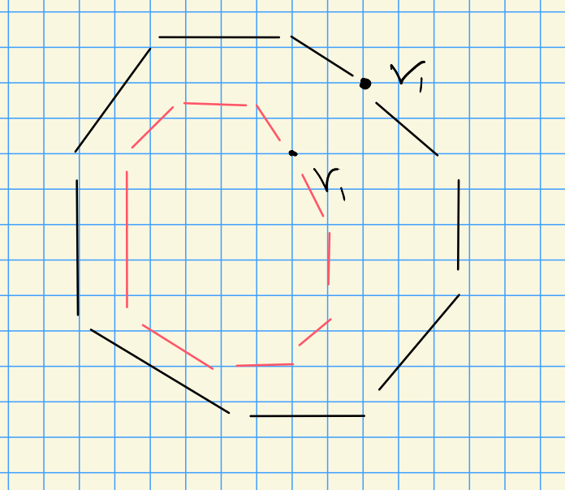

Inner and outershell, orbit of $W$ action?

The last step can be written because the only contributions are $\nu \in W\nu_1$ and $\dim L(\nu_1)_\nu = 1$, i.e. we’re on the outer shell in the figure above.

We can apply (a) and (b) from the technical lemma to write
$$\begin{align*}
\cdots
&= \sum_{w\in W_p} a_w \sum_{w_1} \chi(w(w_1\cdot \mu))
.\end{align*}$$

By (b), $w_1 \in {\operatorname{Stab}}_{W_p}(\lambda)$. We don’t want duplication, so we can check that $w_1\cdot\mu = w_2 \cdot\mu = \lambda+ w\nu_1$ implies that $w_1 \in w_2 {\operatorname{Stab}}_{W_p}(\mu)$. Thus we need to take the coset representatives stated in the theorem.

> Thus we don’t need to consider any weights in the inner shell.

## 24.3 Equivalence of Categories

Goal: show that a pair of functors each admit a natural transformation to the identity.

Let $\mathcal{C}, \mathcal{D}$ be categories and $S, T:\mathcal{C} \to \mathcal{D}$ be two functors. A **natural transformation** $\alpha:S\to T$ is a function that assigns to each object $c\in \mathcal{C}$ a morphism $\alpha_c:S(c) \to T(c)$ in such a way that for every $f:c\to c'$, we have a commuting square

[figure not shown]

If $\alpha_c$ is an equivalence for all $c\in \mathcal{C}$, then $\alpha$ is said to be a **natural isomorphism**. Two categories are said to be **equivalent** iff $S\circ T$ and $T\circ S$ are naturally isomorphic to the identity functor.

Suppose $\lambda, \mu \in \mkern 1.5mu\overline{\mkern-1.5muC\mkern-1.5mu}\mkern 1.5mu_{\mathbb{Z}}$ belong to the same facet. Then $T_\lambda^\mu$ induces an equivalence of categories from
$$\begin{align*}
\mathcal{B}_\lambda \mathrel{\vcenter{:}}=\mathcal{C} \mathrel{\vcenter{:}}=\left\{{V\in {\mathsf{G}{\hbox{-}}\mathsf{Mod}} {~\mathrel{\Big|}~}{\operatorname{pr}}_\lambda V = V}\right\} \leadsto
\mathcal{B}_\mu \mathrel{\vcenter{:}}=\mathcal{D} \mathrel{\vcenter{:}}=\left\{{V\in {\mathsf{G}{\hbox{-}}\mathsf{Mod}} {~\mathrel{\Big|}~}{\operatorname{pr}}_\mu V = V}\right\}
.\end{align*}
where \(T_\mu^\lambda \circ T_\lambda^\mu \cong {\operatorname{pr}}_\lambda\).$$

Using the adjointness of $T_\lambda^\mu$ and $T_\mu^\lambda$< we can write
$$\begin{align*}
\hom_G(V, T_\mu^\lambda T_\lambda^\mu V) \equiv
\hom_G(T_\lambda^\mu V, T_\lambda^\mu V)
.\end{align*}$$

So consider the identity map on the latter $\operatorname{id}: T_\lambda^\mu V{\circlearrowleft}$, and let $f_V: V\to T_\mu^\lambda T_\lambda^\mu V$ be the corresponding map in the former. We can a natural transformation in the following way

[figure not shown]

It suffices to show that the $f_V$ are isomorphism as maps of $G{\hbox{-}}$modules, so one proceeds by

- Showing it works for simple $G{\hbox{-}}$modules, and
- Applying induction to composition length, using the five lemma.

Suppose $V$ is simple, then by the prior theorem we can write
$$\begin{align*}
\operatorname{ch}T_\mu^\lambda T_\lambda^\mu V =
\sum_{w\in W_p} a_w \qty{\sum_{w_1, w_2} \chi\qty{w(w_2 w_1)\cdot \lambda } }
.\end{align*}
We know that$$

- $w_1\in {\operatorname{Stab}}_{W_p}(\mu) / \sim$
- $w_2\in {\operatorname{Stab}}_{W_p}(\lambda) / \sim$

Note that if $\mu, \lambda$ are in the same facet, then the stabilizers are the same.

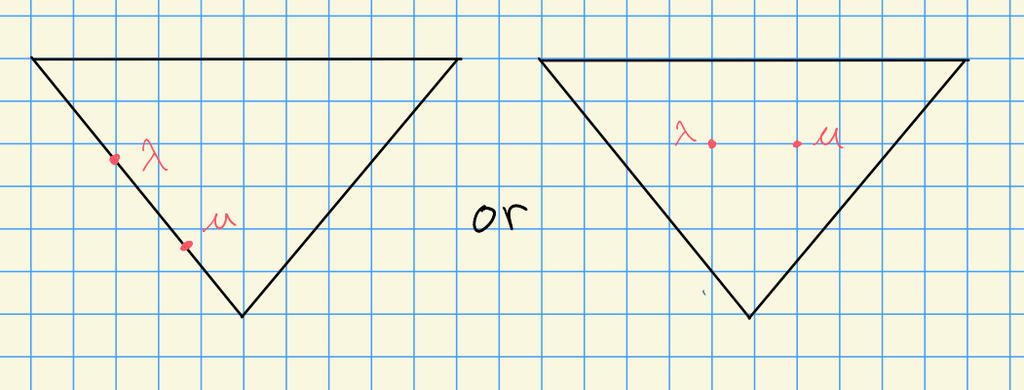

Weights in the same facet share a stabilizer.

So $\lambda, \mu$ are in the same facet, so $w_1 = \operatorname{id}, w_2 = \operatorname{id}$ and $f_V$ is an isomorphism. We thus obtain $T_\mu^\lambda T_\lambda^\mu =\cong {\operatorname{pr}}_\lambda$ and $T_\lambda^\mu T_\mu^\lambda =\cong {\operatorname{pr}}_\mu$. Thus $B_\lambda \cong B_\mu$.

*Question*: What happens when translating from an alcove onto a wall? A similar formula will hold in this case: we will get either induced modules or zero, depending on the dominance of the weights. This will lead into the Lusztig conjectures.

# 25 Wednesday, October 28

## 25.1 Review of Last Time

Suppose we have two weights in the same facet, i.e. they’re in the same stabilizer under the action of the affine Weyl group:

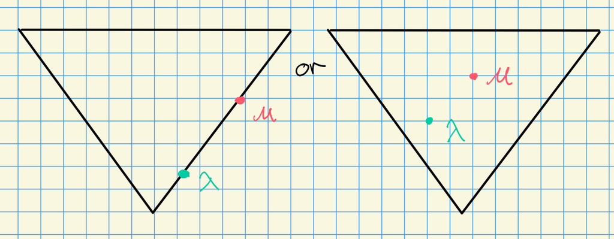

Weights in the same facet

We had a theorem: if $\lambda, \mu$ are in the same facet, then $\mathcal{B}_\lambda \cong \mathcal{B}_\mu$ is an equivalence of categories, where the map is via the translation functors.

## 25.2 Description of $T_\lambda^\mu {H^i(w\cdot \lambda) }$

We can write
$$\begin{align*}
T_\lambda^\mu \qty{H^i(w\cdot \lambda)}
&= {\operatorname{pr}}_\mu \qty{L(\nu_1) \otimes{\operatorname{pr}}_\lambda\qty{H^i(w\cdot \lambda)} } \\
&= {\operatorname{pr}}_\mu \qty{L(\nu_1) \otimes{H^i(w\cdot \lambda)} } \\
&= {\operatorname{pr}}_\mu \qty{L(\nu_1) \otimes{R^i \mathop{\mathrm{ind}}_B^G w\cdot \lambda} } \\
&= {\operatorname{pr}}_\mu\qty{R^i \mathop{\mathrm{ind}}_B^G \qty{L(\nu_1) \otimes w\cdot \lambda } }
.\end{align*}$$

Take a composition series by $B{\hbox{-}}$modules of $L(\nu_1) \otimes w\cdot \lambda$, say
$$\begin{align*}
0 = M_0 \subseteq M_1 \cdots \subseteq M_r = L(\nu_1) \otimes w\cdot \lambda
.\end{align*}
where \(M_j / M_{j-1} \cong \lambda+j + w\cdot \lambda\) and \(\lambda_j < \lambda_{j'} \implies j < j'\), i.e. we can order them in a decreasing way.$$

Consider the SES

[figure not shown]

where applying ${\operatorname{pr}}_\mu({-})$ induces the LES

[figure not shown]

We know that
$$\begin{align*}
{\operatorname{pr}}_\mu H^i\qty{\lambda_j + w\cdot \lambda} =
\begin{cases}
H^i(\lambda_j + w\cdot \lambda ) & \lambda+j + w\cdot \lambda \in W_p\cdot \mu \\
0 & \text{else}
\end{cases}
,\end{align*}
i.e. this projection is the identity for weights linked to \(\mu\) and zero otherwise. We also have
\begin{align*}
{\operatorname{pr}}_\mu H^i(M_r) = T_\lambda^\mu H^i(w\cdot \lambda)
.\end{align*}$$

Let $\lambda, \mu \in \mkern 1.5mu\overline{\mkern-1.5muC\mkern-1.5mu}\mkern 1.5mu_{\mathbb{Z}}$ and $F$ be a facet with $\lambda \in F$. If $\mu \in \mkern 1.5mu\overline{\mkern-1.5muF\mkern-1.5mu}\mkern 1.5mu$, then we have
$$\begin{align*}
T_\lambda^\mu\qty{H^i(w\cdot \lambda)} = H^i(w\cdot \mu) \qquad \forall w\in W_p
.\end{align*}$$

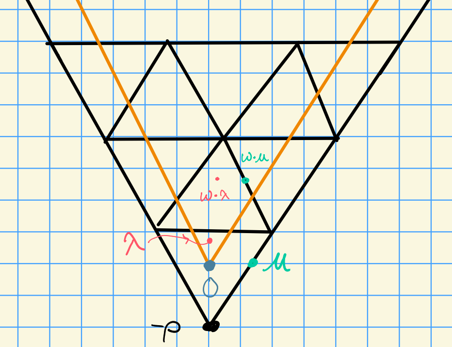

Image

Here consider $H_0(\lambda) \xrightarrow{T_\lambda^\mu} H_0(\mu) = 0$, since $\mu$ is outside of the dominant region (in orange.) We also have $H^0(w\cdot \lambda) \to H^0(w\cdot \mu) \neq 0$, since this falls *into* the dominant region.

Let $\lambda \in F$ and $\mu\in\mkern 1.5mu\overline{\mkern-1.5muF\mkern-1.5mu}\mkern 1.5mu$. Then ${\operatorname{Stab}}_{W_p}(\lambda) \subseteq {\operatorname{Stab}}_{W_p}(\mu)$. By a previous technical lemma, we had a formula for computing $\operatorname{ch}T_\lambda^\mu V$, which involved considering
$$\begin{align*}
w_1 \in {{\operatorname{Stab}}_{W_p}(\lambda) \over {\operatorname{Stab}}_{W_p}(\lambda) \cap{\operatorname{Stab}}_{W_p}(\mu)}
.\end{align*}
In this case, we get \(w_1 = \operatorname{id}\), since the top and bottom are equal.$$

By that lemma, there exists a unique $\ell$ such that $w\cdot \lambda + \lambda_\ell \in W_p\cdot \mu$, where $\lambda_\ell$ is a weight of $L(\nu_1)$. From the LES, we have

[figure not shown]

where the last term will only be nonzero in restricted cases. We can thus conclude that
$$\begin{align*}
{\operatorname{pr}}_\mu(H^i(M_j)) =
\begin{cases}
0 & j< \ell \\
H^i(w\cdot \mu) & j\geq \ell.
\end{cases}
\end{align*}
Setting \(j=r\), we have
\begin{align*}
T_\lambda^\mu \qty{H^i(w\cdot\lambda)} = {\operatorname{pr}}_\mu H^j(M_r) = H^i(w\cdot \mu)
.\end{align*}$$

Suppose $\lambda \in \mkern 1.5mu\overline{\mkern-1.5muC\mkern-1.5mu}\mkern 1.5mu_{\mathbb{Z}}$ and $\mu \in C_{\mathbb{Z}}$. What happens when you translate $\lambda$ (blue) off of a wall? $T_\lambda^\mu\qty{H^0(w\cdot \lambda)}$ has a filtration with factors $H^0(w_1\cdot \mu)$ and $H^0(w_2\cdot \mu)$ (shown in green).

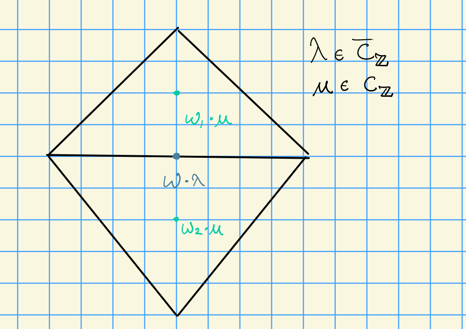

Filtration coming from translating off of a wall

If $w\lambda$ is a vertex with $\mu \in C_{\mathbb{Z}}$, then $T_\lambda^\mu(H^0(w\cdot \lambda))$ has six factors:

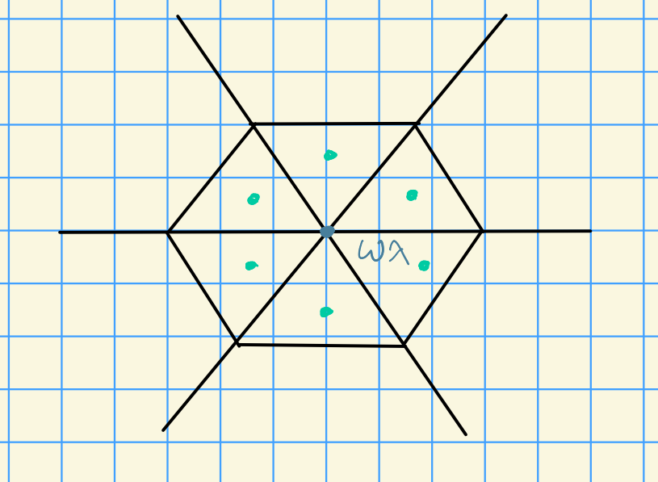

Weight where the translation has six factors

Suppose $\lambda \in \mkern 1.5mu\overline{\mkern-1.5muC\mkern-1.5mu}\mkern 1.5mu_{\mathbb{Z}}$ and $\mu \in C_{\mathbb{Z}}$, and let $w\in W_p$ where $w\cdot \lambda \in X(T)_+$. Then $T_\lambda^\mu (H^0(w\cdot \lambda))$ has a filtration such that all of the composition factors are of the form $H^0(ww_1 \cdot \mu)$ where $w_1\in {\operatorname{Stab}}_{W_p}(\lambda)$ and each of the factors occurs at most once.

Recall that $\widehat{F}$ denotes the *upper closure*.

Let $\lambda, \mu \in \mkern 1.5mu\overline{\mkern-1.5muC\mkern-1.5mu}\mkern 1.5mu_{\mathbb{Z}}$ be in the bottom alcove, where $\mu \in \mkern 1.5mu\overline{\mkern-1.5muF\mkern-1.5mu}\mkern 1.5mu_1$ but $\lambda\in F_1$. Let $F$ be the facet containing $w\cdot\lambda$, then
$$\begin{align*}
T_\lambda^\mu(L(w\cdot \lambda)) =
\begin{cases}
L(w\cdot \mu) & w\cdot \mu \in \widehat{F} \\
0 & \text{else}.
\end{cases}
\end{align*}$$

In this situation, we have $T_\lambda^\mu(L(\lambda)) = 0$:

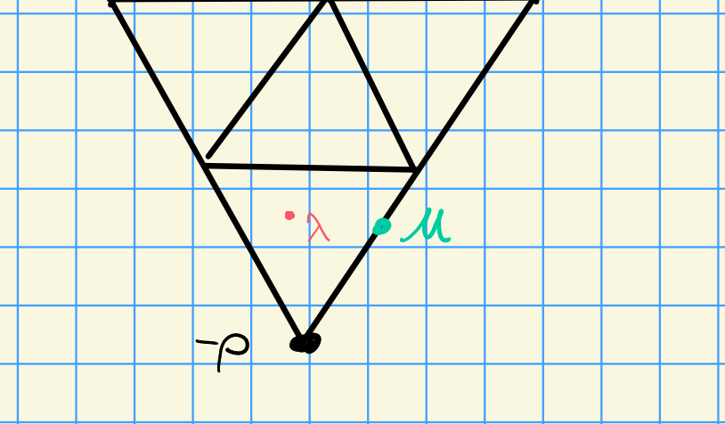

Image

If instead $\mu \in \widehat{C}_{\mathbb{Z}}$, we have $T_\lambda^\mu( L(\lambda)) = L(\mu)$:

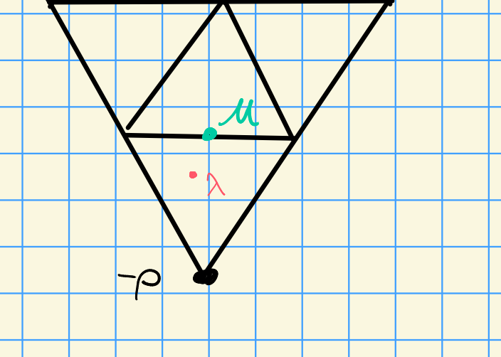

Image

**Big Question**: What happens to $L(w\cdot \lambda)$ when translating away from a wall?

A facet $F$ is a **wall** $\iff {\left\lvert { \Phi_0^+(F) } \right\rvert} = 1$. In this case, there exists a unique $\alpha$ such that ${\left\langle {\lambda + \rho},~{\alpha {}^{ \vee }} \right\rangle} = n_\alpha p$.

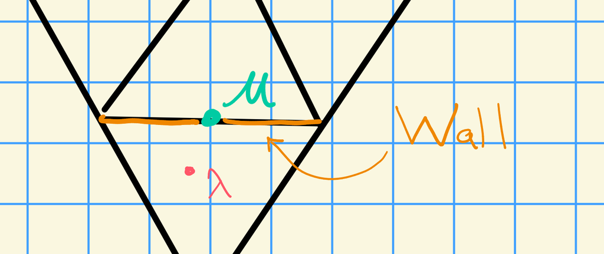

Example of a wall

Note that $s_F = s_{\beta, n_p}$ where $n_p = {\left\langle {\lambda + \rho},~{\beta {}^{ \vee }} \right\rangle}$ acts on the wall as the identity and reflects across it:

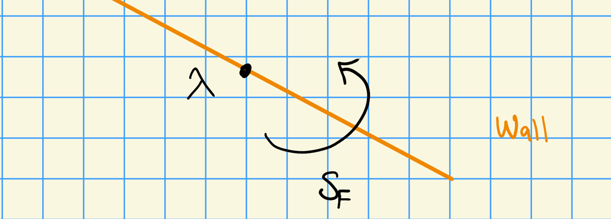

Image

Here ${\operatorname{Stab}}_{W_p}(\lambda) = \left\{{1, s_F}\right\}$.

Consider the following situation:

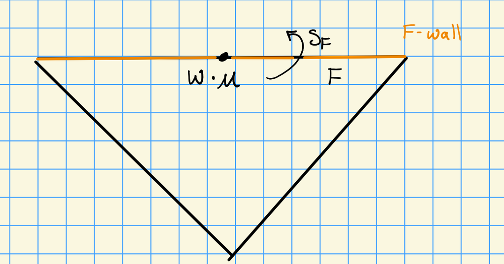

Image

1. $[T_\mu^\lambda (L(w\cdot \mu)) : L(w\cdot \lambda)] = 2$, appearing once in the socle and once in the head.
2. $L(w\cdot \lambda) = \mathop{\mathrm{Soc}}_G T_\mu^\lambda(L(w\cdot \mu)) = T_\mu^\lambda(L(w\cdot \mu)) / \mathop{\mathrm{Rad}}T_\mu^\lambda (L(w\cdot \mu))$.

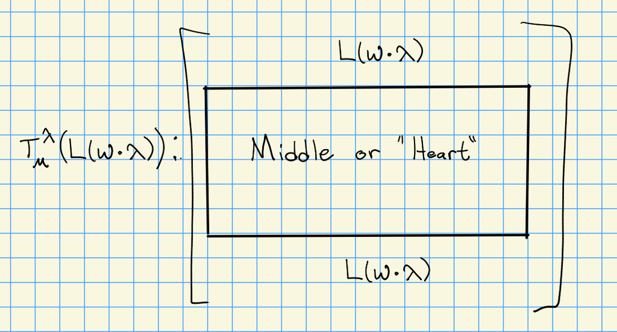

Heart of the module

**Big Problems**:

1. When is the heart semisimple?
2. Determine the composition factors in the heart?

Given these, you could compute dimensions of irreducible representations.

# 26 Monday, November 02

Today: Lusztig conjectures, but first some alcove geometry.

## 26.1 Alcove Geometry

### 26.1.1 Length Function for Alcoves

Let $A, B$ be alcoves, and recall that a hyperplane is give by
$$\begin{align*}
H_{\alpha, m} \mathrel{\vcenter{:}}=\left\{{ \lambda \in X(T) {~\mathrel{\Big|}~}{\left\langle {\lambda + \rho},~{\alpha {}^{ \vee }} \right\rangle} = mp }\right\}
.\end{align*}$$

These are codimension 1 objects:

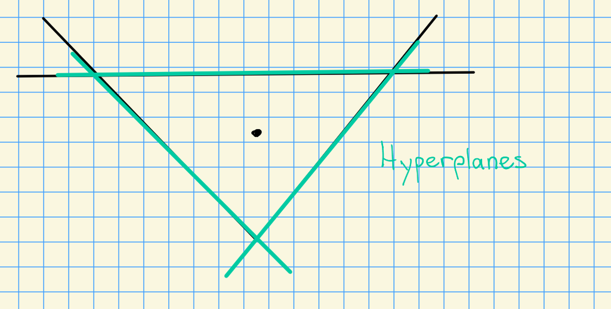

Image

We can also divide these into positive and negative sides:

$$\begin{align*}
H_{\alpha, m}^+ &\mathrel{\vcenter{:}}=\left\{{ \lambda \in X(T) {~\mathrel{\Big|}~}{\left\langle {\lambda + \rho},~{\alpha {}^{ \vee }} \right\rangle} > mp }\right\} \\
H_{\alpha, m}^- &\mathrel{\vcenter{:}}=\left\{{ \lambda \in X(T) {~\mathrel{\Big|}~}{\left\langle {\lambda + \rho},~{\alpha {}^{ \vee }} \right\rangle} < mp }\right\}
.\end{align*}$$

Let $S(A, B)$ be the set of hyperplanes separating $A$ and $B$.

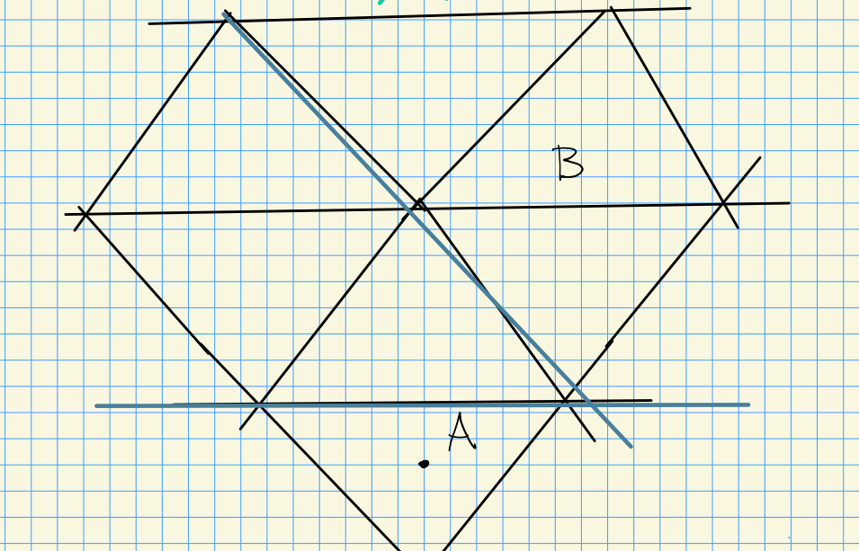

Hyperplanes separating two alcoves

If $H\in S(A, B)$, then define a function
$$\begin{align*}
{\varepsilon}(H) \mathrel{\vcenter{:}}=
\begin{cases}
1 & A\in H_{\alpha, m}^- \\
-1 & A\in H_{\alpha, m}^+
\end{cases}
,\end{align*}
and from it construct a distance function
\begin{align*}
d(A, B) \mathrel{\vcenter{:}}=\sum_{H\in S(A, B)} {\varepsilon}(H)
.\end{align*}$$

and for $\lambda \in C_{\mathbb{Z}}$

$$\begin{align*}
d(w\cdot \lambda) = d(C_{\mathbb{Z}}, wC_{\mathbb{Z}})
.\end{align*}$$

for $w\in W_p$.

Now consider the following situation:

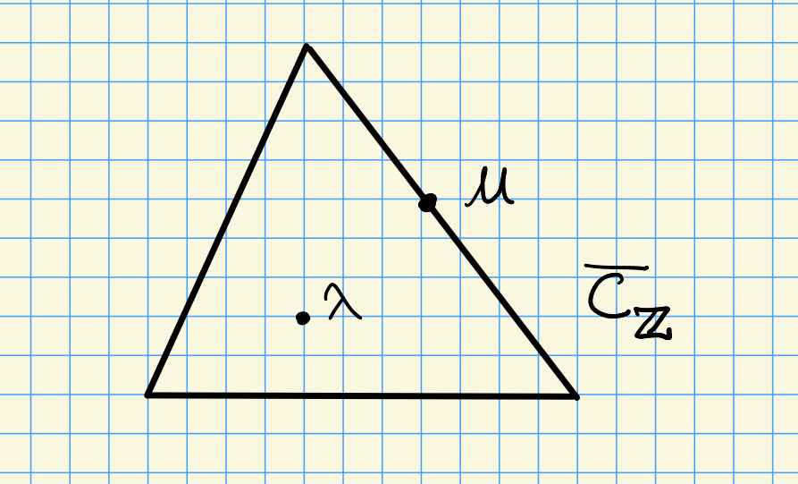

Image

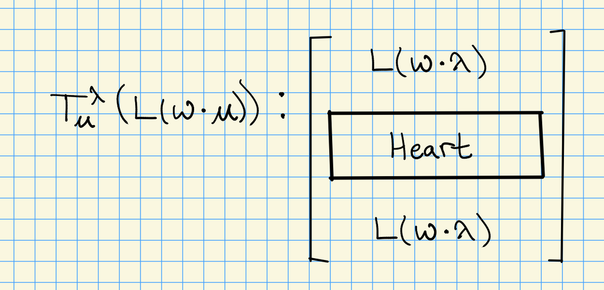

where knowing the structure of the heart of the module is an open problem.

The setup is the following: Let $\lambda\in X(T) \cap C_{\mathbb{Z}}$ where $\mu \in \mkern 1.5mu\overline{\mkern-1.5muC\mkern-1.5mu}\mkern 1.5mu_{\mathbb{Z}}$. Since it’s on a wall, there is a nontrivial stabilizer ${\operatorname{Stab}}_{W_p}(\mu) = \left\langle{s}\right\rangle$. We can write
$$\begin{align*}
\operatorname{ch}L(w\cdot \lambda) = \sum_{w'} a_{w, w'} \chi(w' \cdot \lambda)
.\end{align*}$$

The sum is over $w'\in W_p$ where $w'\cdot \lambda \in X(T)_+$, and we have strong linkage $w'\cdot \lambda \uparrow w\cdot \lambda$. Now consider translating from $\lambda$ to the wall $\mu$. We can write
$$\begin{align*}
\operatorname{ch}L(w\cdot \lambda) = \sum_{w'} a_{w, w'} \chi(w' \cdot \mu)
.\end{align*}$$

Since $\left\langle{s}\right\rangle$ is the stabilizer, we have
$$\begin{align*}
\operatorname{ch}T_\mu^\lambda L(w\cdot \mu)
&= \sum_{w'} a_{w, w'} \chi(w' \cdot \lambda)
+ \sum_{w'} a_{w, w'} \chi(w's \cdot \mu) \\
&= \operatorname{ch}L(w\cdot \lambda)
+ \sum_{w'} a_{w, w'} \chi(w's \cdot \mu)
,\end{align*}$$

We can now check that
$$\begin{align*}
\operatorname{ch}T_\mu^\lambda T_\lambda^\mu L(w\cdot \lambda) =
\operatorname{ch}L(w\cdot \lambda) + \chi(ws\cdot \lambda ) + \sum_{w'} b_{w'} \chi(w'\cdot\lambda)
.\end{align*}$$

Note that in the last sum, the $b_{w'}$ with $w'\in W_p$ satisfy $w'\cdot \lambda \in X(T)_+$ and $d(w'\cdot\lambda) < d(w\cdot \lambda)$. We would like to compute
$$\begin{align*}
[H^0(w_1\cdot \lambda) : L(w_2\cdot \lambda)
.\end{align*}
using induction on \(d(w_1\cdot \lambda)\).$$

Suppose that for all $w_1$ with $d(w_1\cdot\lambda) < d(w\cdot \lambda)$, we know all of the $b_{w'}$. In this case, we know $\chi(ws\cdot \lambda)$ by Weyl’s character formula. We’d then only need to know the translated character
$$\begin{align*}
T_\mu^\lambda T_\lambda^\mu L(w\cdot \lambda)
.\end{align*}
Note that it’s sufficient to know all of its composition factors
\begin{align*}
[T_\mu^\lambda T_\lambda^\mu L(w\cdot \lambda): L(w_2\cdot \lambda)
,\end{align*}$$

and since we know the head and the socle, it suffices to understand the composition factors in its heart:

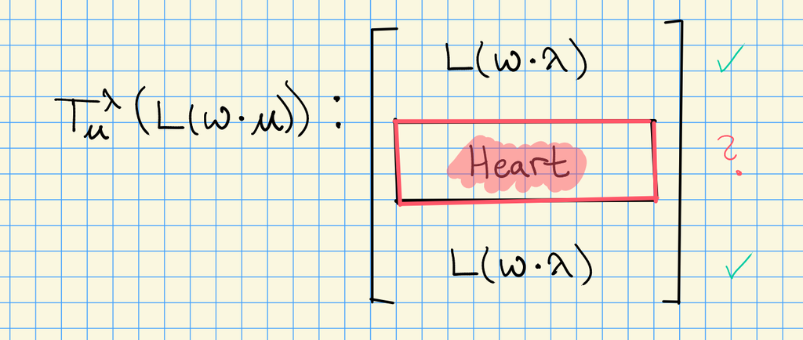

Understanding the composition factors of the heart.

Is the heart semisimple for
$$\begin{align*}
{\left\langle {w(\lambda + \rho)},~{\alpha {}^{ \vee }} \right\rangle} \leq p(p-h-2) && \forall \alpha\in \Phi^+
.\end{align*}
where \(w\cdot\lambda = w(\lambda + \rho) - \rho\)?$$

Define $h$ to be the **Coxeter number**, defined by
$$\begin{align*}
h \mathrel{\vcenter{:}}={\left\langle {\rho},~{\alpha_0 {}^{ \vee }} \right\rangle} + 1
\end{align*}
where \(\alpha_0\) is the highest short root.$$

Let $\Phi = A_n$, then $\alpha_0 = \alpha_1 + \alpha_2 + \cdots + \alpha_n$. Then $h=n+1$.

Let $\Phi = G_2$, then $\alpha_n = 3\alpha_1 + 2\alpha_2$, and $h = 5+1 = 6$.

Andersen showed that this question is equivalent to the Lusztig conjecture. To state this conjecture, we’ll need a few more definitions.

Define the **Jantzen region** by
$$\begin{align*}
\operatorname{Jan} \mathrel{\vcenter{:}}=\left\{{\lambda \in X(T) {~\mathrel{\Big|}~}
0 \leq {\left\langle {\lambda + \rho},~{\alpha {}^{ \vee }} \right\rangle} \leq p(p-h-2) \,\, \forall \alpha\in \Phi^+
}\right\}
.\end{align*}$$

Let $\lambda \in X(T) \cap C$ and $w\cdot\lambda \in \operatorname{Jan}$ with $w\in W_p$. Then
$$\begin{align*}
\operatorname{ch}L(w\cdot \lambda) = \sum_{w'} (-1)^{d(w\cdot \lambda) - d(w'\cdot \lambda)} P_{w'w_0, ww_0} (1) \chi(w'\cdot \lambda)
.\end{align*}
where \(w'\in W_p\) with \(w'\cdot\lambda \in X(T)_+\). The polynomials \(P\) appearing here are the KL-polynomials for \(W_p\) and \(w_0\) is the longest element in \(W\).$$

Note that the Lusztig conjecture is similar to the Kazhdan-Lusztig conjectures: in that setting, we’re in category ${\mathcal{O}}$, we have the Weyl group instead of the affine Weyl group, and we’re concerned with the characters of Verma modules. Note that this conjecture is true for category ${\mathcal{O}}$ and in the case of quantum groups. In the quantum group setting, you can only iterate Frobenius once, but for algebraic groups it can be iterated. The presence of the affine Weyl group also makes these settings very different.

Some remarks on the conjecture:

- This is true for $p\gg 0$, by Andersen-Jantzen-Soergel (1994) and Kazhdan-Lustzig, Koshiwana-Tanisaki.
- It was unknown if there was an effective lower bound until it was found by Fiebig (possibly in 2000s)
- Williamson demonstrated a counterexample by looking at Steinberg weights.

If we know $\operatorname{ch}L(\lambda)$ for $\lambda \in X_1(T)$ in the restricted region, by Steinberg’s twisted tensor product formula we can compute $L(\mu)$ for $\mu \in X(T)_+$. So when is the restricted region contained in the Jantzen region, so $X_1(T) \subseteq \operatorname{Jan}$? Assume that $\lambda \in X_1(T)$, then compute
$$\begin{align*}
{\left\langle {\lambda+\rho},~{\alpha_0 {}^{ \vee }} \right\rangle} = {\left\langle {\lambda},~{\alpha_0 {}^{ \vee }} \right\rangle} + (h-1)
.\end{align*}
Note that by extending scalars to \({\mathbb{Q}}\), we get an inequality in the ordering of the form \(\lambda \leq_{\mathbb{Q}}(p-1_\rho)\). We can then write$$

$$\begin{align*}
{\left\langle {\lambda+\rho},~{\alpha_0 {}^{ \vee }} \right\rangle}
&= {\left\langle {\lambda},~{\alpha_0 {}^{ \vee }} \right\rangle} + (h-1) \\
\leq {\left\langle {(p-1) \rho},~{\alpha_0 {}^{ \vee }} \right\rangle} + (h-1) \\
&= (p-1)(h-1) + (h-1) \\
&= p(h-1)
.\end{align*}
When is this less than or equal to \(p(p-h-2)\)? We can check that this happens iff
\begin{align*}
p(h-1) &\leq p(p-h-2) \\
\iff h-1 &\leq p-h-2 \\
\iff 2h+1 &\leq p
,\end{align*}
so the conjecture (as stated in its original form) reads
\begin{align*}
p\geq 2h+1 \implies X_1(T) \subseteq \operatorname{Jan}
.\end{align*}$$

Kato conjectured that this bound could be lowered to $p\geq h$, but Williamson produced counterexamples around 2013. Essentially, the calculation of $\operatorname{ch}L(\lambda)$ is still open.

Next time: we’ll define $G_rT{\hbox{-}}$modules. We’ll define a graded category to prevent the weights from collapsing mod $p$. These turn out to be easier to work with than $G_r{\hbox{-}}$modules, and results can be pushed down.

# 27 Wednesday, November 04

Today: $G_r{\hbox{-}}T$ modules.

Note that $G_r{~\trianglelefteq~}G_r T$, with $G_r T/G_r \cong T^{(r)}$. We consider $G_r T{\hbox{-}}$modules, which are $G_r{\hbox{-}}$modules with a $T$ action given by
$$\begin{align*}
G_r \times M &\to M \\
(g, m) &\mapsto g\cdot m
\end{align*}
which are \(T{\hbox{-}}\)equivariant, i.e. \(t(g\cdot m) = (t\cdot g)(t\cdot m)\) for \(t\in T, g\in G_r\), and \(m\in M\) is a \(G_r T{\hbox{-}}\)module. This essentially induces a grading on \(G_r\).$$

## 27.1 Representations for $G_r T$ and $G_r B$

Recall that we have a Frobenius map, for which we take the scheme-theoretic kernel:
$$\begin{align*}
F&: G \to G \\
F^r &\mathrel{\vcenter{:}}= F\circ F \circ \cdots \circ F \\
G_r &\mathrel{\vcenter{:}}=\ker F^r
,\end{align*}
and we then define
\begin{align*}
G_r T \mathrel{\vcenter{:}}=(F^r)^{-1} (T) \\
G_r B \mathrel{\vcenter{:}}=(F^r)^{-1} (B)
\end{align*}
taken as scheme-theoretic objects.$$

Noting that $B\subset G_r B$, for $\lambda \in X(T)$ we define
$$\begin{align*}
\widehat{Z}_r' (\lambda) &\mathrel{\vcenter{:}}=\mathop{\mathrm{ind}}_B^{G_r B} \lambda \\
\widehat{Z}_r (\lambda) &\mathrel{\vcenter{:}}=\mathop{\mathrm{coInd}}_B^{G_r B} \lambda
.\end{align*}$$

These are enhancements of the baby Verma modules, in the sense that if we take restrictions we get
$$\begin{align*}
\widehat{Z}_r' (\lambda) \downarrow_{G_r} = \mathop{\mathrm{ind}}_{B_r}^{G_r} \lambda
.\end{align*}$$

We similarly have
$$\begin{align*}
{Z}_r' (\lambda) \downarrow_{G_r T} &= \mathop{\mathrm{ind}}_{B_r T}^{G_r T} \lambda \\
\widehat{Z}_r' (\lambda) \downarrow_{G_r T} &= \mathop{\mathrm{coInd}}_{B_r T}^{G_r T} \lambda
.\end{align*}$$

1. $\widehat{Z}_r(\lambda + p^r \mu) \cong \widehat{Z}_r(\lambda) \otimes p^r \mu$
2. $\widehat{Z}_r' (\lambda + p^r \mu) \cong \widehat{Z}_r' (\lambda) \otimes p^r \mu$
3. $\operatorname{ch}\widehat{Z}_r(\lambda) = \operatorname{ch}\widehat{Z}_r' (\lambda) = e^\lambda \prod_{\alpha\in\Phi^+} {1 - e^{-p^r\mu} \over 1 - e^{-\alpha}}$.

From the definition, we have
$$\begin{align*}
\widehat{Z}_r'(\lambda + p^r \mu)
&= \mathop{\mathrm{ind}}_{B}^{G_r B} (\lambda + p^r \mu) \\
&= \mathop{\mathrm{ind}}_{B}^{G_r B} (\lambda \otimes p^r \mu) \\
\cong \qty{\mathop{\mathrm{ind}}_B^{G_r B} \lambda} \otimes p^r\mu
.\end{align*}
Where in the last equality we’ve applied the tensor identity, noting that \(p^r\mu\) is a 1-dimensional \(G_r B{\hbox{-}}\)module, since
\begin{align*}
G_r B \to G_r B/G_r = B^{(r)} = B/B_r
,\end{align*}
making it a representation by pullback.$$

We can write
$$\begin{align*}
\widehat{Z}_r(\lambda) = \operatorname{dist}(U_r) \otimes\lambda
,\end{align*}
and thus
\begin{align*}
\operatorname{ch}\widehat{Z}_r(\lambda)
&= e^{\lambda} \operatorname{ch}\operatorname{dist}(U_r) \\
&= e^{\lambda} \prod_{\alpha\in \Phi^+}\qty{ 1 + e^{-\alpha} + \cdots + e^{-(p^r-1)\alpha} } \\
&= e^\lambda {1 - e^{-p^r \alpha} \over 1 - e^{-\alpha}} && \text{as a geometric series}
.\end{align*}$$

The next theorem is related to the fact that when comparing these categories of modules, one is essentially a graded version of the other.

Let $M\in{\mathsf{G_rT}{\hbox{-}}\mathsf{Mod}}$, then TFAE:

1. $M$ is an injective $G_r T{\hbox{-}}$module.
2. $M$ is an injective $G_r{\hbox{-}}$module.

Note that $G_r {~\trianglelefteq~}G_r T$, where the quotient is $T^{(r)}$ which is twisted by Frobenius $r$ times.

We’ll apply the Lydon-Hoschild-Serre spectral sequence: for $N$ a $G_r T{\hbox{-}}$module,
$$\begin{align*}
E_2^{i, j} = \operatorname{Ext} _{T^{(r)}}^{i}\qty{K, \operatorname{Ext} _{G_r}^j\qty{N, M} } \Rightarrow\operatorname{Ext} _{G_r T}^{i+j}(N, M)
.\end{align*}$$

$2\implies 1$:

We first note that 2 implies $\operatorname{Ext} _{G_r}^{>0}(N, M) = 0$, so the spectral sequence collapses and we have
$$\begin{align*}
\operatorname{Ext} _{T^{(r)}}^i (k, \hom_{G_r}(M, N) ) \cong \operatorname{Ext} _{G_r T}^i(N, M)
.\end{align*}
Since modules over \(T^{(r)}\) are completely reducible, we have
\begin{align*}
\operatorname{Ext} _{T^{(r)}}^{>0} ( k, \hom_{G_r}(N, M) ) = 0
,\end{align*}$$

and thus $\operatorname{Ext} _{G_r T}^{>0}(N, M) = 0$, making $M$ an injective $G_r T{\hbox{-}}$module. $\hfill\blacksquare$

$1\implies 2$:

The simple $G_r T{\hbox{-}}$modules are of the form $N\mathrel{\vcenter{:}}= L_r(\lambda) \otimes p^r\sigma$ where $\lambda\in X_r(T)$ and $\sigma\in X(T)$. Note that $L_r(\lambda)$ is simple $G_r{\hbox{-}}$module. Applying the spectral sequence, there is a 5 term exact sequence. Letting $E_t \mathrel{\vcenter{:}}=\operatorname{Ext} _{G_rT}^t (N, M)$.

[figure not shown]

Everything is zero here except for the middle term: $E_1, E_2 = 0$ by assumption? $E_2^{1, 0}, E_2^{2, 0} = 0$ by ?.

We can thus conclude that
$$\begin{align*}
0 = E_2^{0, 1}
&= \hom_{T^{(r)}}(k, \operatorname{Ext} _{G_r}^1 (L_r(\lambda) \otimes p^r\sigma, M) ) \\
&= \hom_{T^{(r)}}(p^r\sigma, \operatorname{Ext} _{G_r}^1 (L_r(\lambda), M) )
,\end{align*}
which holds for all \(p^r \sigma\), and thus \(\operatorname{Ext} _{G_r}^1 (L_r(\lambda), M) = 0\) for all \(\lambda\in X_1(T)\). So \(M\) is injective as a \(G_r{\hbox{-}}\)module.$$

Let $\lambda \in X(T)$, then

1. $\widehat{Z}_r (\lambda) \downarrow_{B_r T}$ is the projective cover of $\lambda$ and the injective hull of $\lambda - 2(p^r-1)\rho$.
2. $\widehat{Z}_r' (\lambda) \downarrow_{B_r^+}$ is the projective cover of $\lambda - 2(p^r-1)\rho$ and the injective hull of $\lambda$.

## 27.2 Summary: Classification of Simple $G_r T{\hbox{-}}$Modules

- $\mathop{\mathrm{Soc}}_{B_r^+} \widehat{Z}_r '(\lambda) = \lambda$
- $\widehat{Z}_r ' (\lambda) ^{U^+} = \lambda$, where the RHS denotes the $U^+$ invariants.
- Let $\widehat{L}_r(\lambda) \mathrel{\vcenter{:}}=\mathop{\mathrm{Soc}}_{G_r T} \widehat{Z}_r' (\lambda)$.
- Each simple $G_r T{\hbox{-}}$module is isomorphic to $\widehat{L}_r (\lambda)$ for some $\lambda\in X(T)$.
- $\widehat{L}_r(\lambda) \downarrow_{G_r} \cong L_r (\lambda)$ for all $\lambda \in X_1(T)$.
- Translation invariance: $\widehat{L}_r(\lambda + p^r\sigma) = \widehat{L}_r (\lambda) \otimes p^r\sigma$
- $\widehat{L}_r (\lambda + p^r \sigma) \downarrow_{G_r} = L_r(\lambda)$ for all $\lambda \in X_r(T)$.

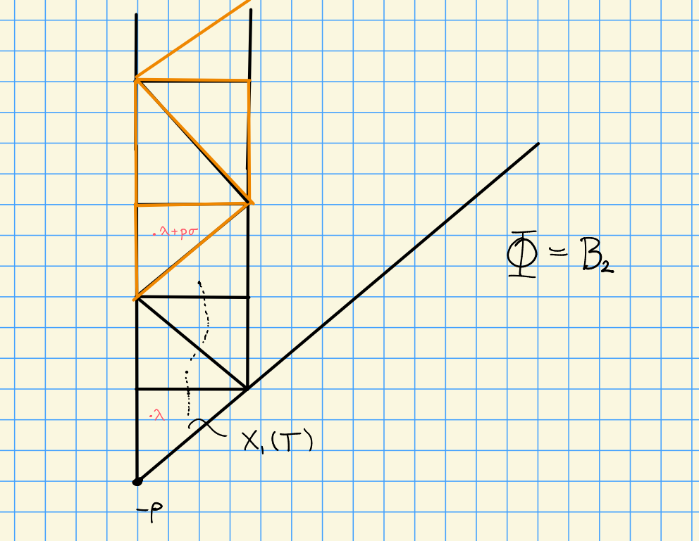

Example in $\Phi = B_2$

> This essentially allows you to replace working mod $p$ in characteristic $p$ with working with integers instead, allowing the usual weight theory to be used.

Let $\lambda \in X(T)$, then there exists an isomorphism of $G{\hbox{-}}$modules
$$\begin{align*}
H^i(\lambda) = R^i \mathop{\mathrm{ind}}_{G_r B}^G \widehat{Z}_r ' (\lambda)
,\end{align*}
where \(\widehat{Z}_r'(\lambda) = \mathop{\mathrm{ind}}_B^{G_r B}(\lambda)\).$$

# 28 Friday, November 06

## 28.1 Good $(p, r){\hbox{-}}$ Filtrations

Last time: $G_r T$ and $G_r B$ modules. We roughly know the category of $G_r$ modules, and we think of $G_r T$ as graded $G_r{\hbox{-}}$modules. We defined
$$\begin{align*}
\widehat{Z}_r' (\lambda) &\mathrel{\vcenter{:}}=\mathop{\mathrm{ind}}_{B}^{G_r B}(\lambda) \\
\widehat{Z}_r' (\lambda) &\mathrel{\vcenter{:}}=\mathop{\mathrm{coInd}}_{B^+}^{G_r B^+}(\lambda)
.\end{align*}$$

We can use these for classification since we have a correspondence
$$\begin{align*}
\left\{{\substack{\text{Simple }G_rT{\hbox{-}}\text{modules}}}\right\}
&\iff
\left\{{\substack{X(T)}}\right\} \\
\widehat{L}_r(\lambda) = \widehat{L}_r(\lambda_0) \otimes p^r \lambda &\mapsfrom \lambda = \lambda_0 + p^r \lambda_1
,\end{align*}
where \(\widehat{L}_r(\lambda_0)\) is a simple \(G_r{\hbox{-}}\)module and \(\lambda_0 \in X_r(T)\).$$

We can compose the two functors to get a Grothendieck-type spectral sequence
$$\begin{align*}
E_2^{m, n} = R^m \mathop{\mathrm{ind}}_{G_r B}^{G} \qty{ R^n \mathop{\mathrm{ind}}_{B}^{G_r B}(\lambda) }
\Rightarrow
R^{m+n} \mathop{\mathrm{ind}}_B^G(\lambda)
,\end{align*}
which follows from induction being transitive. Note that \(\mathop{\mathrm{ind}}_{B}^{G_r B}({-})\) is exact, since coinduction is given by \(\operatorname{dist}(G_rB)\otimes_{\operatorname{Dist}(B)}\lambda \cong \operatorname{Dist}(U_r^+)\otimes_k \lambda\) is tensoring over a field, and this is dual to induction. Thus \(R^{>0} \mathop{\mathrm{ind}}_B^{G_r B}(\lambda) = 0\) and the spectral sequence collapses to yield
\begin{align*}
R^m \mathop{\mathrm{ind}}_{G_r B}^G R^0 \mathop{\mathrm{ind}}_{B}^{G_r B}
= R^m \mathop{\mathrm{ind}}_{G_r B}^G \mathop{\mathrm{ind}}_{B}^{G_r B}
= R^m \mathop{\mathrm{ind}}_B^G(\lambda)
,\end{align*}
where we can just note that \(\mathop{\mathrm{ind}}_B^{G_r B}(\lambda) = \widehat{Z}_r'(\lambda)\).$$

Recall *Kempf’s vanishing theorem*: if $\lambda \in X(T)_+$ is a dominant weight, then $H^{>0}(\lambda) = 0$.

Let $M\in {\mathsf{G}{\hbox{-}}\mathsf{Mod}}$, then $M$ has a (good) **$(p, r){\hbox{-}}$filtration** iff there exists a sequence of $G{\hbox{-}}$modules
$$\begin{align*}
0 = M_0 \subseteq M_1 \subseteq M_2 \subseteq \cdots \subseteq M_s = M
\end{align*}
such that \(M_i / M_{i+1} \cong L(\lambda_0) \otimes H^0(\lambda_1)^{(r)}\) where \(\lambda_0 \in X_r(T)\) (so the first time is irreducible) and \(\lambda_1 \in X(T)_+\), so the second term is twisted.$$

Question due to Jantzen: let $\lambda \in X(T)_+$. Does $H^0(\lambda)$ have a good $(p, r){\hbox{-}}$filtration?

This question was open for a while, until the following was found:

If $p\geq 2(h-1)$ and Lusztig’s character formula holds for $G$, then $H^0(\lambda)$ has a good $(p, r)$ filtration.

There are counterexamples to Jantzen’s question. Example: $\Phi = G_2$ and $p=2$.

> Later: we’ll see how to construct these filtrations by factoring induction into intermediate inductions.

Let $\lambda \in X(T)_+$ and assume every composition factor of the baby Verma $\widehat{Z}_r'(\lambda)$ has the form $\widehat{L}_r(\mu_0 + p^r \mu_1) = \widehat{L}_r(\mu_0) \otimes p^r \mu_1$ where $\mu_0\in X_r(T)$ and $\mu_1\in X(T)$ is any weight. Suppose further that ${\left\langle {\mu_1 + \rho},~{\beta {}^{ \vee }} \right\rangle}\geq 0$ for all $\beta\in \Delta$ (so it’s “pretty dominant”). Then $H^0(\lambda)$ has a good $(p, r)$ filtration, and moreover
$$\begin{align*}
[ \widehat{Z}_r'(\lambda) : \widehat{L}_r(\mu_0) \otimes p^r \mu_1 ]
= [ H^0(\lambda) : L(\mu_0) \otimes H^0(\mu_1)^{(r)} ]
.\end{align*}$$

Suppose $\widehat{L}_r(\mu_0 + p^r\mu_1)$ is a composition factor of $\widehat{Z}_r'$. Then since we have $G{\hbox{-}}$modules, we can use the tensor identity to write
$$\begin{align*}
R^i \mathop{\mathrm{ind}}_{G_r B}^{G} L_r(\mu_0) \otimes p^r \mu_1
&= L_r(\mu_0) \otimes R^i \mathop{\mathrm{ind}}_{G_r B}^{G} p^r \mu_1 \\
&= L_r(\mu_0) \otimes H^i(\mu_1)^{(r)}
,\end{align*}
where the last equality follows from a theorem we won’t prove here. We can set \(i=0\) to yield
\begin{align*}
\mathop{\mathrm{ind}}_{G_r B}^{G} L_r(\mu_0) \otimes p^r \mu_1
\cong L_r(\mu_0) \otimes H^0(\mu_1)^{(r)}
.\end{align*}
Recall that \(H^0(\lambda) = \mathop{\mathrm{ind}}_{G_r B}^{G} \widehat{Z}_r'(\lambda)\), so we’ll take a composition series for \(\widehat{Z}_r'(\lambda)\) and apply the induction functor to it. So let such a composition series be given by
\begin{align*}
0\subseteq N_0 \subseteq N_1 \subseteq \cdots \subseteq N_s = \widehat{Z}_r'(\lambda)
,\end{align*}
where \(N_i / N_{i-1} \cong L(\mu_0) \otimes p^r \mu_1\) for some \(\mu_0\in X_r(T)\) and \(\mu_1\in X(T)\). Now apply the functor \(\mathop{\mathrm{ind}}_{G_r B}^{G}({-})\) which yields
\begin{align*}
0\subseteq \cdots \subset \mathop{\mathrm{ind}}_{G_r B}^{G} N_i \subseteq \cdots \subseteq H^0(\lambda)
.\end{align*}$$

Question: is this a good $(p, r)$ filtration?

Note that if we have
$$\begin{align*}
0 \to N_1 \to N_2 \to N_2/N_1 \to 0
\end{align*}
this yields
\begin{align*}
0 \to \mathop{\mathrm{ind}}N_1 \to \mathop{\mathrm{ind}}N_2 \to \mathop{\mathrm{ind}}(N_2/N_1) \to R^1 \mathop{\mathrm{ind}}N_1 \to \cdots
.\end{align*}$$

Here we need $\mathop{\mathrm{ind}}(N_2/N_1) \cong \mathop{\mathrm{ind}}N_2 / \mathop{\mathrm{ind}}N_1$, so we need to show $R^1 \mathop{\mathrm{ind}}N_1 = 0$.

Using the tensor identity we can write
$$\begin{align*}
R^1 \mathop{\mathrm{ind}}N_1
&= R^1 \mathop{\mathrm{ind}}_{G_r B}^G L_r(\sigma_0) \otimes p^r \sigma_0 \\
&= L_r(\sigma_0) \otimes\qty{R^1 \mathop{\mathrm{ind}}_{G_r B}^G \sigma_1 }^{(r)}
\end{align*}
and \({\left\langle {\sigma_1 + \rho},~{\beta {}^{ \vee }} \right\rangle} \geq 0\), so \(R^1 \mathop{\mathrm{ind}}_{G_r B}^G \sigma_1 = 0\). Thus we can extend the region from Kempf’s vanishing slightly:$$

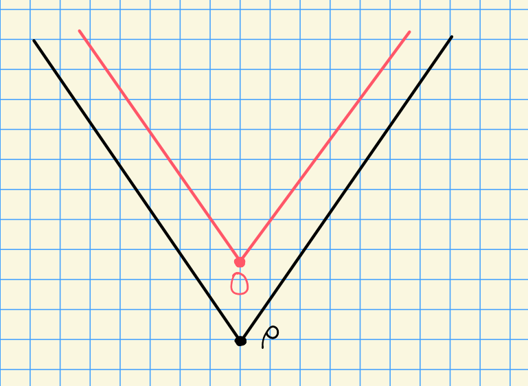

Image

Finding composition factors for the $\widehat{Z}_r'$ is in general a hard problem: if we had this, we’d have the characters of the irreducibles. Some combinatorics can be used here.

## 28.2 Strong Linkage

Note that strong linkage for $H^0(\lambda)$ implies strong linkage for $\widehat{Z}_r'(\lambda)$.

Let $\lambda, \mu \in X(T)$, then if $[\widehat{Z}_r'(\lambda): \widehat{L}(\mu)] \neq 0$, then $\mu\uparrow\lambda$ and $\mu\in W_p\cdot\lambda + p^r X(T)$.

Note that $\widehat{Z}_r'(\lambda)$ is finite dimensional. Idea: tensor by a 1d rep to make all composition factors dominant. Then for any weight $\lambda$, we can find a large enough weight that moves $\lambda$ into the dominant chamber:

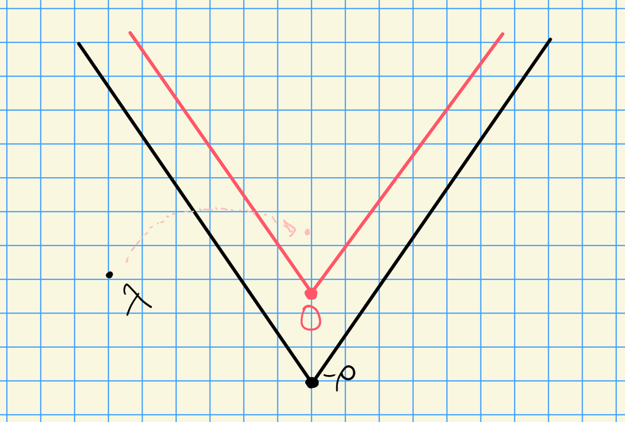

I.e., we can tensor by $p^r v$ for $v$ large so that $\widehat{Z}_r'(\lambda) \otimes p^r v$ has composition factors if the form $L(\mu_0) \otimes p^r \mu_1$ with ${\left\langle {\mu_1 + \rho},~{\beta {}^{ \vee }} \right\rangle} \geq 0$ for all $\beta\in\Delta$.

Then $\mu + p^r v \uparrow \lambda p^r v$, which implies $\mu\uparrow \lambda$, and so using strong linkage we have a $p{\hbox{-}}$filtration on $H^0(\lambda + p^r v)$.

Next time: extensions in ${\mathsf{G_r T}{\hbox{-}}\mathsf{Mod}}$ and the Steinberg module (very important in representation theory, has some nice properties).

# 29 Monday, November 09

## 29.1 Strong Linkage

We have two categories:

- $G_r T$, with a notion of *strong linkage*, and
- $G_r$, which instead only has *linkage*.

We’ll restate a few theorems.

Let $\lambda, \mu \in X(T)$.

1. If $[\widehat{Z}_r(\lambda) : \widehat{L}_r(\mu) ]_{G_r T} \neq 0$, then $\mu \uparrow \lambda$ are strongly linked.
2. If $[{Z}_r(\lambda) : {L}_r(\mu) ]_{G_r} \neq 0$, then $\mu \in W_p \cdot\lambda + p^r X(T)$.

In the case of $\Phi = A_2$, we’ll consider the two different categories.

We have the following picture for $\widehat{Z}$:

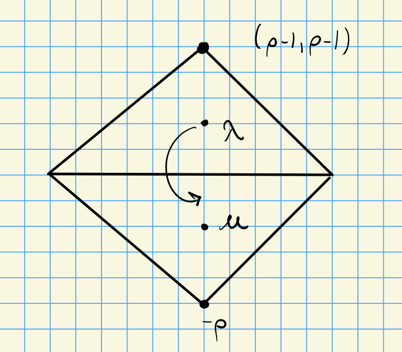

Image

On the other hand, for $Z$, we have the following:

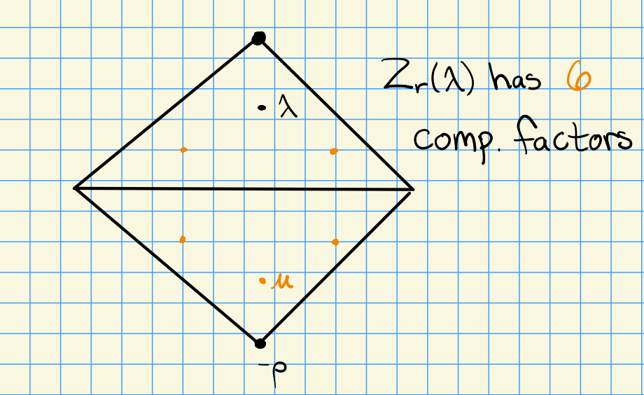

Image

## 29.2 Extensions

Let $\lambda, \mu \in X(T)$. We can use the Chevalley anti-automorphism (essentially the transpose) to obtain a form of duality for extensions:
$$\begin{align*}
\operatorname{Ext} _{G_r T}^j \qty{ \widehat{L}_r(\lambda), \widehat{L}_r(\mu) }
=
\operatorname{Ext} _{G_r}^j \qty{ \widehat{L}_r(\mu), \widehat{L}_r(\lambda) } \qquad \text{for }j\geq 0
.\end{align*}$$

We have a form of a weight space decomposition
$$\begin{align*}
\operatorname{Ext} _{G_r}^j \qty{L_r(\lambda), L_r(\mu) }
= \bigoplus_{\gamma \in X(T)} \operatorname{Ext} _{G_r}^j \qty{L_r(\lambda), L_r(\mu) }_{\gamma}
\end{align*}
where we are taking the fixed points under the torus \(T\) action on the first factor (for which \(T_r\) acts trivially). We can write this as
\begin{align*}
\cdots
&= \bigoplus_{\gamma \in X(T)} \operatorname{Ext} _{G_r}^j \qty{L_r(\lambda), L_r(\mu) \otimes\gamma } \\
&= \bigoplus_{\gamma \in X(T)} \operatorname{Ext} _{G_rT}^j \qty{L_r(\lambda), L_r(\mu) \otimes p^r v } \\
&= \bigoplus_{v \in X(T)} \operatorname{Ext} _{G_rT}^j \qty{ \widehat{L}_r(\lambda), \widehat{L}_r(\mu + p^r v) }
.\end{align*}$$

So if we know extensions in the $G_r$ category, we know them in the $G_r T$ category.

There is an isomorphism
$$\begin{align*}
\operatorname{Ext} _{G_r T}^1 \qty{ \widehat{L}_r(\lambda), \widehat{L}_r(\mu) }
\cong \mathop{\mathrm{Hom}}_{G_R T}\qty{ \mathop{\mathrm{Rad}}_{G_r T} \widehat{Z}_r(\lambda), \widehat{L}_r(\mu) }
.\end{align*}$$

Finally, for $\lambda, \mu \in X(T)$, if the above $\operatorname{Ext} ^1$ vanishes, then $\lambda \in W_p \cdot \mu$ (i.e. $\lambda$ and $\mu$ are linked).

## 29.3 The Steinberg Modules

Consider $A_2$:

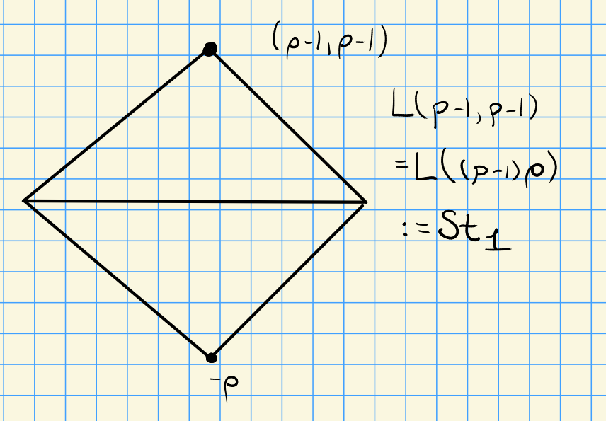

Image

Taking the representation corresponding to $(p-1, p-1)$ yields the “first Steinberg module”
$$\begin{align*}
L(p-1, p-1) = L((p-1)\rho) \mathrel{\vcenter{:}}=\operatorname{St}_1
.\end{align*}$$

In this case, we have an equality of many modules:

$$\begin{align*}
H^0((p-1) \rho) =
L((p-1) \rho) =
V((p-1) \rho) =
T((p-1) \rho)
.\end{align*}$$

The $r$th **Steinberg module** is defined to be $L((p^r-1)\rho)$.

In general, we have
$$\begin{align*}
L((p^r-1)\rho) =
H^0((p^r-1)\rho) =
V((p^r-1)\rho)
.\end{align*}$$

We also have
$$\begin{align*}
\widehat{Z}_r((p^r-1)\rho) \cong
L((p^r-1)\rho) \downarrow_{G_r T}
.\end{align*}$$

The Steinberg module is both injective and projective as both a $G_r{\hbox{-}}$module and a $G_rT{\hbox{-}}$module.

It suffices to prove that ${\mathsf{Stk}}_r$ is projective over $G_r T$, then by a previous theorem, it will also be projective over $G_r$. Let $\widehat{L}_r(\mu)$ be a simple $G_rT{\hbox{-}}$module, and consider
$$\begin{align*}
\operatorname{Ext} _{G_rT}^1({\mathsf{Stk}}_r, \widehat{L}_r(\mu)) =
\operatorname{Ext} _{G_rT}^1(\widehat{L}_r((p^r-1)\rho), \widehat{L}_r(\mu))
.\end{align*}
If we show this is zero for every simple module, the result will follow.$$

Suppose $(p^r-1)\rho\not< \mu$. In this case, the RHS above is zero.

Otherwise, we have
$$\begin{align*}
\operatorname{Ext} _{G_rT}^1(\widehat{L}_r(\mu), {\mathsf{Stk}}_r) =
\mathop{\mathrm{Hom}}_{G_rT}(\mathop{\mathrm{Rad}}(\widehat{Z}_r(\mu)) , {\mathsf{Stk}}_r)
.\end{align*}
Suppose that the RHS is nonzero. Then \(\mathop{\mathrm{Rad}}\qty{\widehat{Z}_r(\mu)} \twoheadrightarrow{\mathsf{Stk}}_r\), and thus
\begin{align*}
\dim \mathop{\mathrm{Rad}}\qty{ \widehat{Z}_r(\mu) } \geq \dim {\mathsf{Stk}}_r = p^{r{\left\lvert {\Phi^+} \right\rvert}}
\end{align*}
But we know that
\begin{align*}
\dim \mathop{\mathrm{Rad}}\qty{\widehat{Z}_r(\mu)} < \dim \widehat{Z}_r(\mu) = p^{r{\left\lvert {\Phi^+} \right\rvert}}
,\end{align*}
so we’ve reached a contradiction and the hom must be zero.$$

Let $G$ be a reductive group and $M$ a finite-dimensional $G{\hbox{-}}$module. Then $M$ has a good $(p, r){\hbox{-}}$filtration iff ${\mathsf{Stk}}_r \otimes M$ has a good filtration.

See NK (Nakano-Kildetoft, 2015) and BNPS (Bendel-Nakano-Pillen-Subaje, $2018{\hbox{-}}$).

The forward direction is equivalent to the statement that ${\mathsf{Stk}}_r \otimes L(\lambda)$ has a good filtration for $\lambda \in X_r(T)$.

The Dfilt conjecture in the forward direction holds for all $p$.

This is known for $p\geq 2h-4$? BNPS has shown that this holds for all rank 2 groups, which is strong evidence. The reverse implication is **not** true: BNPS-Crelle 2020 shows that for $\Phi = G_2, p=2$, there exists an $H^0(\lambda)$ that does not have a good $(p, r){\hbox{-}}$filtration. There is a similar conjecture for tilting modules (“DTilt”).

Main difference to category ${\mathcal{O}}$: infinitely many highest weight representations?

Upcoming:

- Viewing the $G_r T$ category as “almost” a highest weight category
- Defining standard and costandard modules $\Delta(\lambda)$ and $\nabla(\lambda)$.
- Injective $G_r T{\hbox{-}}$modules
- Results of Verma and Humphreys on the Lifting Conjecture: does every $G_r T{\hbox{-}}$module come from a $G{\hbox{-}}$module?
- Donkin’s Tilting Module Conjecture (DTilt)

DFilt implies DTilt, and DTilt implies the forward direction of DFilt.

# 30 Friday, November 13

## 30.1 Review

Review: we’re considering $G_r T{\hbox{-}}$modules, with several associated modules of interest:

- Simple modules $\widehat{L}_r(\lambda)$ for $\lambda \in X(T)$
- Intermediate modules $\nabla(\lambda) = \widehat{Z}_r'(\lambda)$ and $\Delta(\lambda) = \widehat{Z}_r(\lambda)$.
- Injective and projective modules $\widehat{Q}_r(\lambda)$

Let $M$ be a $G_r T{\hbox{-}}$module of finite dimension. Then $M$ has a $\widehat{Z}_r$ filtration $\iff$ $M\downarrow_{B_r}$ is projective.

From this, the multiplicity $[M: \widehat{Z}_r(\mu)]$ (the number of times $\widehat{Z}_r(\mu)$ appears in a $\widehat{Z}_r$ filtration ) is well-defined. Moreover, we have a decomposition
$$\begin{align*}
M\downarrow_{B_r} = \bigoplus_{\mu} Z_r(\mu)\downarrow_{B_r}
,\end{align*}
where the sum contains as many terms as the number of factors that appear. We have \(Z_r(\mu)\downarrow_{B_r} \twoheadrightarrow\mu\), making is the projective cover of \(\mu\) and thus indecomposable. We can then apply the Krull-Schmidt theorem.$$

## 30.2 Reciprocity

Consider $\widehat{Q}_r(\lambda)$, a projective $G_r T{\hbox{-}}$module. Note that it also happens to be injective. We saw before that the functor $\mathop{\mathrm{coInd}}_{B_r T}^{G_r T}({-})$ is exact, and thus $\widehat{Q}_r(\lambda)\downarrow_{B_r T}$ being projective implies that $\widehat{Q}_r(\lambda)\downarrow{B_r}$ is also projective. This implies that $\widehat{Q}_r(\lambda)$ has a $\widehat{Z}_r{\hbox{-}}$filtration.

Thus the multiplicity can be computed as
$$\begin{align*}
[\widehat{Q}_r(\lambda) : \widehat{Z}_r(\mu)]
&= [\widehat{Q}_r \downarrow{B_r T} : \widehat{Z}_r(\mu)] \\
&= \dim \mathop{\mathrm{Hom}}_{B_r T}\qty{\widehat{Q}_r(\lambda), \mu } \\
&= \dim \mathop{\mathrm{Hom}}_{B_r T}\qty{ \widehat{Q}_r(\lambda), \mathop{\mathrm{ind}}_{B_r T}^{G_r T} \mu } && \text{by Frobenius reciprocity} \\
\end{align*}$$

Show that
$$\begin{align*}
[M: S] = \dim \mathop{\mathrm{Hom}}_A( P(S), \mu) = [\mathop{\mathrm{ind}}_{B_r T}^{B_r T} \mu : \widehat{L}_r(\lambda)]
.\end{align*}$$

We can thus continue this computation as
$$\begin{align*}
\cdots
&= [\widehat{Z}_r'(\mu) : \widehat{L}_r(\mu)] \\
&= [\widehat{Z}_r(\mu) : \widehat{L}_r(\mu)]
,\end{align*}
since \(\operatorname{ch}\widehat{Z}_r (\mu) = \operatorname{ch}\widehat{Z}_r'(\mu)\).$$

Thus we have the following reciprocity theorem

$$\begin{align*}
[\widehat{Q}_r(\lambda): \widehat{Z}_r(\mu)] = [\widehat{Z}_r(\mu) : \widehat{L}_r (\lambda) ]
.\end{align*}$$

This is hard to prove in the $G_r$ category, need to work in the $G_r T$ category and descend. However, this reciprocity does also work for $G_r$.

For $G = {\operatorname{SL}}_2$, consider $G_1 T$ or $G_1$ where $\lambda = 0,1,2,\cdots, (p-1)$. We have a notion of *linkage*: $\lambda, \mu$ are in the same $G_1$ block iff $\lambda + \mu = p-2$. Note that $\lambda = p-1$ is in its own block.

We have
$$\begin{align*}
Z_r(\lambda) = \mathop{\mathrm{coInd}}_{B_1^+}^{G_1} \lambda \twoheadrightarrow L(\lambda)
.\end{align*}
If \(\lambda + \mu = p-2\), then we have the following situation:$$

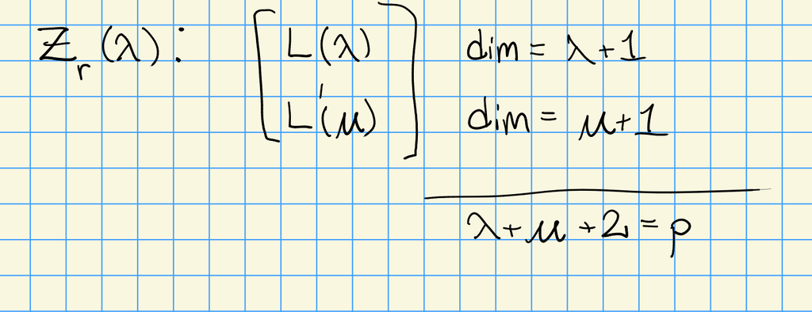

Image

Taking $\lambda = p-1$, we have $Z_r((p-1)\rho) = L(p-1) = {\mathsf{Stk}}_1$.

Applying reciprocity, we gave
$$\begin{align*}
[Q_1(0) : Q_1(\mu)] = [Q_1(\mu): L(0)]
.\end{align*}
Since \(Q_1(0)\) has factors \(Z_1(0)\) and \(Z_1(p-2)\), we have$$

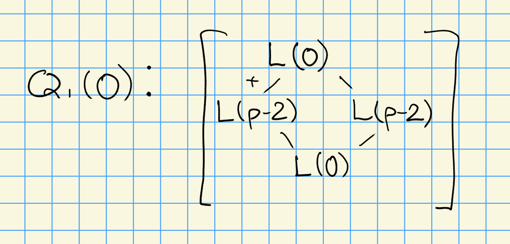

Image

We can identify the two filtrations here:

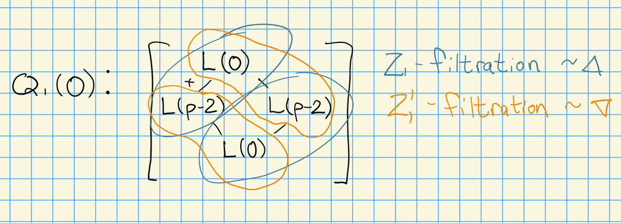

Image

Similarly, for $Q_1(p-2)$ we have

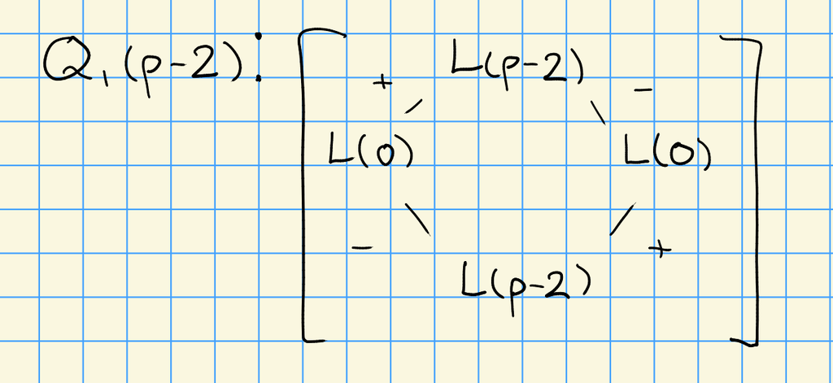

Image

We have

- $\dim \widehat{Q}_1(\lambda) = 2p$ for $\lambda \neq p-1$
- $\dim \widehat{Q}_1(p-1) = p$ for $\lambda = p-1$.

Some work predated the BGG Category ${\mathcal{O}}$. For finite groups, a notion of CDE triangles was worked out.

## 30.3 Toward Lifting Conjectures

Recall that $G_r T \subseteq G$.

**Question**: Given $\widehat{Q}_r(\lambda)$ for a restricted weight $\lambda \in X_r(T)$, does $\widehat{Q}_r(\lambda)$ *lift* to $G$? I.e., does there exist a $G{\hbox{-}}$module $M(\lambda)$ such that $M(\lambda)\downarrow_{G_r T} = \widehat{Q}_r(\lambda)$?

Note that $L_r(\lambda)$ for $\lambda\in X_r(T)$ lifts to $G$, since $L(\lambda)\downarrow_{G_r T} = \widehat{L}_r(\lambda)$.

Let $p > 2h-2$ and $\lambda \in X_r(T)$, then $\widehat{Q}_r(\lambda)$ has a lift to a $G$ structure.

- One can prove that the $G$ structure is unique, since this turns out to be a projective module in an appropriate category (which we won’t get into).
- Ballard (1970s) proved the theorem for $p>3h-3$.
- Jantzen (late 1970s) lowered the bound to $p>2h-2$
- Amazingly, no one has been able to lower this bound! This is currently an open question.
- For $G = {\operatorname{SL}}_2, {\operatorname{SL}}_3$, it is known that $\widehat{Q}_r(\lambda)$ has a $G$ structure for all $p$.

### 30.3.1 Donkin’s Tilting Module Conjecture

From MSRI, 1990. Some notation first: for $\lambda \in X_r(T)$, define
$$\begin{align*}
\widehat{\lambda} \mathrel{\vcenter{:}}= 2(p-1) \rho + w_0 \lambda
.\end{align*}$$

Let $G$ be a semisimple simply connected algebraic group over $k = \mkern 1.5mu\overline{\mkern-1.5muF\mkern-1.5mu}\mkern 1.5mu_p$ for some $p$. Then
$$\begin{align*}
T(\widehat{\lambda}) \downarrow_{G_r T} \cong \widehat{Q}_r(\lambda)
.\end{align*}$$

Next time:

- Proof of theorem
- $\widehat{Q}_r(\lambda) \divides {\mathsf{Stk}}_r \otimes L(\sigma)$ as $G{\hbox{-}}$modules, and is also projective as a $G_r T{\hbox{-}}$module.
- Find a $G{\hbox{-}}$summand $M(\lambda)$ such that $M(\lambda)\downarrow_{G_r T} = \widehat{Q}_r (\lambda)$.
- More with injective modules.
- Possibly something about cohomology of Frobenius kernels.

# 31 Monday, November 16

We’ll focus on the following theorem:

Let $p> 2h-2$ and $\lambda\in X_r(T)$, then $\widehat{Q}_r(\lambda)$ has a $G{\hbox{-}}$structure.

Recall Donkin’s tilting conjecture:

Let $\lambda\in X_r(T)$, then
$$\begin{align*}
T(\widehat{\lambda})\downarrow_{G_r T} = \widehat{Q}_r(\lambda)
.\end{align*}
where \(\lambda = 2(p-1)\rho + w_0\lambda\).$$

There is a counterexample to DTilt conjecture due to Bendel-Pillen-Nakano-Subaje (2019) to DTilt for $\Phi = G_2$ and $p=2$. Note that this doesn’t apply to the previous conjecture, which could still be true.

## 31.1 Existence of $G{\hbox{-}}$Structures: Some Preliminaries

We want to consider $G{\hbox{-}}$structures on injective modules. Let $V, W$ be $G{\hbox{-}}$modules, then
$$\begin{align*}
\mathop{\mathrm{Hom}}_{G_r}(V, W) = [V {}^{ \vee }\otimes W]^{G_r}
,\end{align*}
which is a module on which \(G_r\) acts trivially where we pull back the action using the map \(G \to G/G_r\). Moreover, there exists a \(G{\hbox{-}}\)modules \(M\) such that \(\mathop{\mathrm{Hom}}_{G_r}(V, W) = M^{(r)}\) twisted \(r\) times.$$

We can consider blocks, e.g. by considering ${\operatorname{pr}}_\nu M$. This is the sum of all submodules with composition factors in the same block as $L(\nu)$. We can write $M = \bigoplus_{\nu\in \mkern 1.5mu\overline{\mkern-1.5muC\mkern-1.5mu}\mkern 1.5mu_{\mathbb{Z}}} {\operatorname{pr}}_\nu M$.

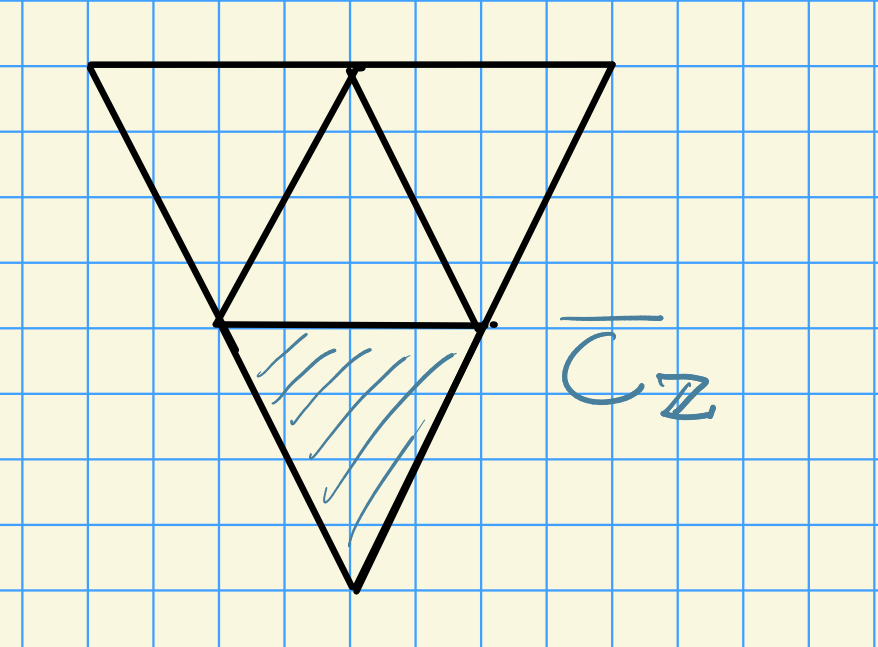

$\mkern 1.5mu\overline{\mkern-1.5muC\mkern-1.5mu}\mkern 1.5mu_{\mathbb{Z}}$

Thus we can write
$$\begin{align*}
\mathop{\mathrm{Hom}}_{G_r}(V, M) = \bigoplus_{\nu\in \mkern 1.5mu\overline{\mkern-1.5muC\mkern-1.5mu}\mkern 1.5mu_{\mathbb{Z}}} \mathop{\mathrm{Hom}}_{G_r}^\nu(V, W) = \qty{ {\operatorname{pr}}_\nu M }^{(r)}
.\end{align*}$$

Note that for $p>h$ the Coxeter number, $0\in \mkern 1.5mu\overline{\mkern-1.5muC\mkern-1.5mu}\mkern 1.5mu_{\mathbb{Z}}$, since
$$\begin{align*}
0 \leq {\left\langle {0+\rho},~{\alpha {}^{ \vee }} \right\rangle} = {\left\langle {\rho},~{\alpha_0 {}^{ \vee }} \right\rangle} = h-1 < p
,\end{align*}
where \(h = {\left\langle {\rho},~{\alpha_0 {}^{ \vee }} \right\rangle}\).$$

We can then write
$$\begin{align*}
\mathop{\mathrm{Hom}}_G(V, W) = \mathop{\mathrm{Hom}}_{G_r}(V, W)^{G_r} \subseteq \mathop{\mathrm{Hom}}_{G_r}^0(V, W)
,\end{align*}
where the middle term involves trivial modules.$$

### 31.1.1 Sketch of Proof

Let $\lambda \in X_r(T)$ and consider $M \mathrel{\vcenter{:}}={\mathsf{Stk}}_r \otimes L( (p^r-1)\rho + w_0 \lambda )$. Then $\widehat{Q}_r(\lambda)$ is a direct summand of $M$ as a $G_r T{\hbox{-}}$module.

In other words, if we restrict this down to $G_r T{\hbox{-}}$modules, we get a $G_r T{\hbox{-}}$summand. Note that if DFilt holds, $M$ is a Tilting module.

Recall that $M$ is a projective and injective $G_r T{\hbox{-}}$ module. It suffices to show that $\widehat{L}_r(\lambda)\in \mathop{\mathrm{Soc}}_{G_r T} M$, for which we look at the hom space
$$\begin{align*}
\mathop{\mathrm{Hom}}_{G_r T} (\widehat{L}_r(\lambda), {\mathsf{Stk}}_r \otimes L( (p^r-1)\rho + w_0 \lambda ) )
&= \mathop{\mathrm{Hom}}_{G_r T} (\widehat{L}_r(\lambda) \otimes{\mathsf{Stk}}_r, L( (p^r-1)\rho + w_0 \lambda ) ) \\
&= \mathop{\mathrm{Hom}}_{G_r T} ({\mathsf{Stk}}_r, \widehat{L}_r(-w_0 \lambda) \otimes L( (p^r-1)\rho + w_0 \lambda ) )
,\end{align*}$$

Let $Q_\lambda$ be the injective hull of $L_\lambda$ as a $G{\hbox{-}}$module. This yields an injection $L(\lambda)\hookrightarrow M$. Since we also have a map into the injective hull, we can extend:

[figure not shown]

Moreover, $\phi:\widehat{Q}_r(\lambda)\to Q_\lambda$ is an injective map since $L(\lambda) \subseteq \mathop{\mathrm{Soc}}_{G_r}(\lambda)$. Thus the image $\phi\qty{\widehat{Q}_r(\lambda) } \cong \widehat{Q}_r(\lambda)$ and is a $G_r T$ summand of $\phi(M)$ since $\widehat{Q}_r(\lambda)$ is an injective $G_r T{\hbox{-}}$module. We have a split exact sequence
$$\begin{align*}
0 \to \phi(\widehat{Q}_r(\lambda)) \hookrightarrow\phi(M) \to ? \to 0
.\end{align*}$$

The idea is now that $\phi(M)$ is a $G{\hbox{-}}$module, so we’ll show $\phi(M)$ is indecomposable as both a $G$ and a $G_r T$ module. In this case, we’ll have
$$\begin{align*}
\phi(M) = \phi(\widehat{Q}_r(\lambda)) \cong \widehat{Q}_r(\lambda)
.\end{align*}$$

It suffices to prove that $\mathop{\mathrm{Soc}}_{G_r} \phi(M) = L_r(\lambda)$. Note that that it suffices to show there’s only one summand, since the socle can’t be decomposed further, which will yield irreducibility. We have
$$\begin{align*}
\mathop{\mathrm{Soc}}_G \phi(M) = L(\lambda)
.\end{align*}$$

We also know that $\mathop{\mathrm{Soc}}_G \phi(M) \subseteq \mathop{\mathrm{Soc}}_{G_r} \phi(M)$. But if $L(\mu) \subseteq \mathop{\mathrm{Soc}}_{G_r} \phi(M)$, then it is also contained in $\mathop{\mathrm{Soc}}_G \phi(M)$. Hence if $\mathop{\mathrm{Soc}}_{G_r}\phi(M)$ is isotypic of type $L(\lambda)$, we have a decomposition
$$\begin{align*}
\mathop{\mathrm{Soc}}_{G_r}\phi(M)
&= \bigoplus_{\sigma\in X_r(T)} L(\sigma) \otimes\mathop{\mathrm{Hom}}_{G_r}(L(\sigma), \phi(M)) \\
&= L(\lambda) \otimes\mathop{\mathrm{Hom}}_{G_r}(L(\lambda), \phi(M)) \\
&= \bigoplus_{\nu\in \mkern 1.5mu\overline{\mkern-1.5muC\mkern-1.5mu}\mkern 1.5mu_{\mathbb{Z}}} L(\lambda) \otimes\mathop{\mathrm{Hom}}_{G_r}^\nu (L(\lambda), \phi(M))
,\end{align*}
where we’ve broken this up into blocks. Note that \(\phi(M)\) is an indecomposable \(G{\hbox{-}}\)module, thus using linkage we can conclude that there is only one summand. By the previous statement, we have
\begin{align*}
k = \mathop{\mathrm{Hom}}_{G}(L(\lambda), \phi(M))
\subseteq \mathop{\mathrm{Hom}}_{G_r}^0 (L(\lambda), \phi(M))
,\end{align*}
and hence$$

$$\begin{equation} \mathop{\mathrm{Soc}}_{G_r} \phi(M) = L(\lambda) \otimes\mathop{\mathrm{Hom}}_{G_r}^0 (L(\lambda), \phi(M)) .\end{equation}$$

Up until now, we’ve only used that $p>h$. If we show that the hom space in the last equality is just the trivial module $k$, then we’re done. This would imply that $\mathop{\mathrm{Soc}}_{G_r} \phi(M) = L(\lambda)$, in which case $\phi(M)$ is an indecomposable $G_r T{\hbox{-}}$module and $\phi(M) = \widehat{Q}_r(\lambda)$.

The critical equation to show:

$$\begin{equation} \mathop{\mathrm{Hom}}_{G_r}^0 (L(\lambda), \phi(M)) = k .\end{equation}$$

Suppose that $\mathop{\mathrm{Hom}}_{G_r}^0 (L(\lambda), \phi(M)) \neq k$. Then there exists a $\nu\in X(T)_+ \cap W_p \cdot 0$ with $\nu\neq 0$ such that $L(\nu)^{(r)} = L(p^r \nu)$ is a composition factor of $\mathop{\mathrm{Hom}}_{G_r}^0 (L(\lambda), \phi(M))$. This would imply that $L(\lambda) \otimes L(\nu)^{(r)} = L(\lambda+ p^r\nu)$ is a composition factor of ${\mathsf{Stk}}_r \otimes H^0( (p^r-1)\rho + w_0 \lambda)$.

The idea now is to check the weights in this module either by Weyl’s character formula or weight estimates. The upshot: for $p>2h-2$, $\lambda+ p^r \nu$ is a weight if $\nu = 0$. $\hfill\blacksquare$

How might this bound be lowered? Maybe the condition of the hom space being trivial is too strong, since being indecomposable isn’t equivalent to having a simple socle.

## 31.2 Steinberg Tensor Product Theorem for Injective $G_r T{\hbox{-}}$Modules

Let $\lambda_0 \in X_r(T)$ and $\lambda_1 \in X(T)$. Then there exists an isomorphism of $G_r T{\hbox{-}}$modules
$$\begin{align*}
\widehat{Q}_{r+1}(\lambda_0 + p^r \lambda_1)\downarrow_{G_r T}
\,\, \cong \widehat{Q}_r(\lambda_0) \otimes\widehat{Q}_1(\lambda_1)^{(r)}
,\end{align*}
where the last term is a \(G_1 T{\hbox{-}}\)module with \(G_r\) acting trivially, which thus becomes a \(G_r T{\hbox{-}}\)module.$$

Comparing this with the situation where $\lambda_1 \in X(T)_+$, we get
$$\begin{align*}
L(\lambda_0 + p^r \lambda_1)
\cong L(\lambda_0) \otimes L(\lambda_1)^{(r)}
,\end{align*}
which is an isomorphism of \(G{\hbox{-}}\)modules.$$

Next time: we’ll complete injective modules, and if we have time, we’ll talk about cohomology.

# 32 Wednesday, November 18

## 32.1 Steinberg Tensor Product Formula

Recall the Steinberg tensor product formula: Let $\lambda \in X(T_+)$ with $\operatorname{ch}(k) = p$, then write
$$\begin{align*}
\lambda = \sum_{j=1}^s p^j \lambda_j
\end{align*}
with \(\lambda_j \in X_1(T)\). Then
\begin{align*}
L(\lambda) = L(\lambda_0) \otimes\bigotimes_{j=1}^s L(\lambda_j)^{(j)}
.\end{align*}$$

The goal is to find a formula resembling this for $G$ and $G_r{\hbox{-}}$modules.

Let $\lambda_0 \in X_r(T), \lambda_1 \in X(T)$. Then there exists an isomorphism of $G_r T{\hbox{-}}$modules
$$\begin{align*}
\widehat{Q}_{r+1} (\lambda_0 + p^r \lambda_1) = \widehat{Q}_r (\lambda_0) \otimes\widehat{Q}_1(\lambda_1)^{(r)}
,\end{align*}
and by inflation, \(\widehat{Q}_1(\lambda)^{(r)}\) is a \(G_r T{\hbox{-}}\)module.$$

We have a decomposition of $G_r T{\hbox{-}}$modules:
$$\begin{align*}
\mathop{\mathrm{Soc}}_{G_r} \widehat{Q}_{r+1}(\lambda) = \bigoplus_{\mu\in X_r(T)} \widehat{L}_r(\mu) \otimes\mathop{\mathrm{Hom}}_{G_r}(\widehat{L}_r(\mu), \widehat{Q}_{r+1}(\lambda) )
.\end{align*}$$

We can write

$$\begin{align*}
\mathop{\mathrm{Soc}}_{G_{r+1}} \widehat{Q}_{r+1}(\lambda)
&= \widehat{L}_{r+1}(\lambda) \\
&= \widehat{L}_r(\lambda_0) \otimes\widehat{L}_1(\lambda_1)^{(r)}
.\end{align*}
And since there can only be one summand, we can combine these two to write$$

$$\begin{align*}
\mathop{\mathrm{Soc}}_{G_r} \widehat{Q}_{r+1}(\lambda) = \widehat{L}_r(\lambda_0) \otimes\mathop{\mathrm{Hom}}_{G_r}(\widehat{L}_r(\lambda_0), \widehat{Q}_{r+1}(\lambda) )
,\end{align*}
which implies that
\begin{align*}
\mathop{\mathrm{Soc}}_{G_{r+1} T} \hom_{G_r}(\widehat{L}_r(\lambda_0), \widehat{Q}_{r+1}(\lambda) ) &\cong \widehat{L}_1(\lambda_1)^{(r)}
.\end{align*}$$

We want to show that this hom is injective, so we’ll use the Lydon-Hochschild-Serre spectral sequence
$$\begin{align*}
E_2^{i, j} = \operatorname{Ext} _{G_{r+1} T/G_r}^i (N, \operatorname{Ext} ^j( \widehat{L}_r(\lambda_0), \widehat{Q}_{r+1}(\lambda) ) )
\Rightarrow
\operatorname{Ext} ^{i+j}_{G_{r+1} T} ( N\otimes\widehat{L}_r(\lambda_0), \widehat{Q}_{r+1}(\lambda) )
.\end{align*}$$

There will be a lot of vanishing here. We know that

- $\widehat{Q}_{r+1}(\lambda)$ is an injective $G_{r+1}T{\hbox{-}}$module, and
- $\widehat{Q}_{r+1}(\lambda)$ is an injective $G_{r}{\hbox{-}}$module,

so $E_2^{>0, 0} = 0$:

$$\begin{align*}
\operatorname{Ext} _{G_{r}T/G_r}^i(N, \mathop{\mathrm{Hom}}_{G_r}( \widehat{L}_r(\lambda_0), \widehat{Q}_{r+1}(\lambda) ) )
.\end{align*}$$

We can thus conclude that $\hom_{G_r}( \widehat{L}_r(\lambda_0), \widehat{Q}_{r+1}(\lambda) )$ is an injective $G_{r+1}T/G_r{\hbox{-}}$module. Thus
$$\begin{align*}
\mathop{\mathrm{Hom}}_{G_r}(\widehat{L}_r(\lambda_0), \widehat{Q}_{r+1}(\lambda) ) \cong \widehat{Q}_{1}(\lambda_1)^{(r)}
.\end{align*}$$

To finish the proof, note that $\widehat{Q}_{r+1}(\lambda) \downarrow_{G_r T} = \bigoplus_{j=1}^m \widehat{Q}_r(\mu_j)$, and thus
$$\begin{align*}
\widehat{Q}_{r+1}(\lambda) = \bigoplus_{j-1}^m \widehat{Q}_r(\lambda_0) \otimes p^r v_j
.\end{align*}$$

Furthermore, at the level of characters we have $\sum e^{v_j} = \operatorname{ch}\widehat{Q}_1(\lambda_1)$ and thus
$$\begin{align*}
\widehat{Q}_1(\lambda_1)^{(r)} = \bigoplus_{j=1}^m p^r v_j
.\end{align*}$$

Suppose $\lambda_0, \lambda_1, \lambda_{r-1}\in X(T)$, where we can write $\lambda = \sum_{i=0}^{r-1} \lambda_i p^i$. Then for characters we have
$$\begin{align*}
\widehat{Q}_{r}(\lambda) = \prod_{j=0}^{r-1} \operatorname{ch}\widehat{Q}_1(\lambda_j)^{(j)}
.\end{align*}$$

Let $L(\lambda)$ be an irreducible representation for $G$, and set $Q_\lambda$ to be the injective hull of $L(\lambda)$, so we have an exact sequence $0 \to L(\lambda) \hookrightarrow Q(\lambda)$.

Let $\lambda\in X_r(T)$, and assume that the $G_r T{\hbox{-}}$ structure on $\widehat{Q}_r(\lambda)$ can be lifted to $G$. Then

1. If $\lambda'\in X(T)_+$, then there exists an isomorphism of $G{\hbox{-}}$modules:
   $$\begin{align*}
   \widehat{Q}_r(\lambda) \otimes Q_{\lambda'}^{(r)} \cong Q_{\lambda + p^r \lambda'}
   .\end{align*}$$
2. If $\lambda'\in X(T)$ and $r'>r$, then there exists an isomorphism of $G_{r'} T{\hbox{-}}$modules
   $$\begin{align*}
   \widehat{Q}_r(\lambda) \otimes\widehat{Q}_{r' - r}(\lambda')^{(r)} \cong \widehat{Q}_{r'}(\lambda + p^r \lambda')
   .\end{align*}$$

We want to show that $\widehat{Q}_r(\lambda) \otimes Q_{\lambda'}^{(r)}$ is an injective $G{\hbox{-}}$module and that the socle of the LHS is equal to $L(\lambda + p^r \lambda')$.

Let $N{~\trianglelefteq~}G$ be groups, and suppose $V_1 \in {\mathsf{G}{\hbox{-}}\mathsf{Mod}}$ is injective as an $N{\hbox{-}}$module and $V_2$ is injective as a $G/N{\hbox{-}}$module. Then $V_1 \otimes V_2$ is injective as a $G{\hbox{-}}$module.

We’ll again use the LHS spectral sequence,
$$\begin{align*}
E_{2}^{i, j} = \operatorname{Ext} _{G/N}^i(k, \operatorname{Ext} _N^j(E, V_1\otimes V_2) )
\Rightarrow
\operatorname{Ext} _G^{i+j}(E, V_1 \otimes V_2)
.\end{align*}
Using the assumption that \(V_1\) is injective as an \(N{\hbox{-}}\)module, we have collapsing
\begin{align*}
\operatorname{Ext} _N^{>0}(E, V_1\otimes V_2) = \operatorname{Ext} _N^{>0} (E\otimes V_2, V_1)
.\end{align*}
and thus
\begin{align*}
\operatorname{Ext} _{G/N}^{>0}(k, \mathop{\mathrm{Hom}}_N(E, V_1\otimes V_2) )
= \operatorname{Ext} _G^{>0}(N, V_1\otimes V_2)
= 0
.\end{align*}
For the first line, we can write \(\hom_N(E, V_1) \otimes V_2\). This vanishes for every possible \(E\), making \(V_1\otimes V_2\) injective.$$

In our situation, we’ll be taking $N\mathrel{\vcenter{:}}= G_r {~\trianglelefteq~}G$, where $G/G_r = G^{(r)}$. Thus the claim proves part (a).

Recall that the $G{\hbox{-}}$socle is contained in $\mathop{\mathrm{Soc}}_{G_r}$, yielding
$$\begin{align*}
\mathop{\mathrm{Soc}}_{G_r} \widehat{Q}_r(\lambda) \otimes Q_{\lambda'}^{(r)}
= \widehat{L}_R(\mu) \otimes\mathop{\mathrm{Hom}}_{G_r}( \widehat{L}_r(\mu), \widehat{Q}_r(\lambda) ) \otimes Q_{\lambda}^{(r)}
.\end{align*}
We know that the hom is only nonzero when \(\lambda = \mu\), so this is equal to
\begin{align*}
\cdots
&= \widehat{L}_R(\lambda) \otimes Q_{\lambda'}^{(r)}
,\end{align*}
since in this term, the hom is just equal to \(k\). Thus we have
\begin{align*}
\mathop{\mathrm{Soc}}_G \widehat{Q}_r(\lambda) \otimes Q_{\lambda'}^{(r)}
= \widehat{L}_r(\lambda) \otimes L(\lambda')^{(r)} = \mathop{\mathrm{Soc}}_G Q_{\lambda+ p^r \lambda'}
.\end{align*}
Since this is an injective module and the socles match, this must be an isomorphism.$$

Let $\lambda \in X(T)_+$ with $\lambda = \sum_{j=0}^s \lambda_j p^j$ with $\lambda_j \in X_1(T)$. Moreover, assume all $Q_r(\mu)$ lift to $G$. Then there exists a ${\mathsf{G}{\hbox{-}}\mathsf{Mod}}$ isomorphism
$$\begin{align*}
Q_r(\lambda) = \bigotimes_{j=0}^s \widehat{Q}_1(\lambda_j)^{(j)}
.\end{align*}$$

Next time: cohomology of Frobenius kernels and relation to the nilpotent cones, related to ABG equivalence, computing the cohomology ring for $G_1$.

# 33 Friday, November 20

## 33.1 Cohomology of Frobenius Kernels

These predate cohomology for the small quantum group.

Let $\ell > h$ be odd, then

1. $H^{2n}(U_\xi(g), {\mathbb{C}}) = {\mathbb{C}}[\mathcal{N}]$ for $\mathcal{N}$ the nilpotent cone.
2. $H^{2k+1}(U_\xi(g), G) = 0$.

Letting $G$ be a reductive algebra over $k = \mkern 1.5mu\overline{\mkern-1.5mu{\mathbb{F}}_p\mkern-1.5mu}\mkern 1.5mu$, recall that we have the $r$th Frobenius $F^r:G\to G$, where $G_r \mathrel{\vcenter{:}}=\ker F^r$ and $A \mathrel{\vcenter{:}}=\operatorname{Dist}(G_r)$. We define $R = H^\cdot(G_r, k) = H^\cdot(A, K) = \operatorname{Ext} _A(k, k)$. How do we compute this ring?

We have

[figure not shown]

We then concatenate these in $\operatorname{Ext} _A^{s+t}(k, k)$.

The best answers occur when $r=1$ and $p>h$, due to results by Friendlander-Parhsll for $p\geq 3h-3$, and by Andersen-Jantzen for $p>h$.

Let $B \subset G$ where $B = T\rtimes U$ and $\mathfrak{u} = \operatorname{Lie}(U)$, $p> h$. Then

1. $H^{2\cdot}(B, k) = S^0(u^*)^{(1)}$
2. $H^{2k+1}(B, k) = 0$.

The main idea: there is a spectral sequence
$$\begin{align*}
E_1^{2i, j} = \qty{
S^i(u^*)^{(1)} \otimes\Lambda^j(u^*)
}^{T_1}
\Rightarrow
\qty{
H^{2i+j}(U_1, k)^{T_1} = S^i(u^*) \otimes\qty{ \Lambda^j(u^*) }^{T_1} \Rightarrow H^{2i+j}(B, k)
}
\end{align*}
which is not a Grothendieck-type spectral sequence, and instead comes from filtering a complex and taking the associated graded. Using routine group combinatorics for \(p>h\), we can find that \(\Lambda^\cdot(u^*)^{T_1} \cong k\). This causes the spectral sequence to collapse.$$

There exists a spectral sequence
$$\begin{align*}
E_2^{i, j} = R^i \mathop{\mathrm{ind}}_{B/B_1}^{G/G_1} H^j(B_1, k) \Rightarrow H^{i+j}(G_1, k)
.\end{align*}$$

We can identify
$$\begin{align*}
R^j \mathop{\mathrm{ind}}_{B/B_1}^{G/G_1} S^0(u^*)^{(1)} = R^j \mathop{\mathrm{ind}}_B^G S^0(u^*) \qquad \text{for } j>0
.\end{align*}$$

This yields

1. $\mathop{\mathrm{ind}}_{B/B_1}^{G/G_1} S^0(u^*)^{(1)} = k$ (???)
2. $H^{2\cdot+1}(G, k) = 0$.

So

$$\begin{align*}
H^{2\cdot}(G, k) = \qty{ \mathop{\mathrm{ind}}_B^G S^0(u^*) }^{(1)} \mathrel{\vcenter{:}}= k[G \operatorname{fp}{B} u]
.\end{align*}$$

This yields the **Springer resolution**

[figure not shown]

We can thus write
$$\begin{align*}
k[G\operatorname{fp}{B} u]
&= k[ \pi^{-1}(O_{\text{reg}}) \\
&= k[O_{\text{reg}}] \\
&= k[\mathcal{N}]
,\end{align*}
since all singularities lie in codimension strictly greater than \(2\).$$

For $p>h$,

1. $H^{2\cdot }(G, k) = k[{\mathcal{N}}]$
2. $H^{2\cdot + 1}(G, k) = 0$.

Let $G = {\operatorname{SL}}_2(k)$ and ${\mathfrak{g}}= {\mathfrak{sl}}_2(k)$. Then for $x\in {\mathfrak{sl}}_2(k)$, we can write
$$\begin{align*}
x = \begin{bmatrix}
a & b \\
c & -a
\end{bmatrix} && \operatorname{det}(x) = -a^2 - bc = 0
.\end{align*}
Then we have a presentation of the cohomology ring:
\begin{align*}
H^{2\cdot}(G, k) = k[a,b,c] / \left\langle{a^2 + bc = 0}\right\rangle, && {\left\lvert {a} \right\rvert} = {\left\lvert {b} \right\rvert} = {\left\lvert {c} \right\rvert} = 2
.\end{align*}$$

## 33.2 Finite Generation of Cohomology

A finite group scheme is essentially the same as a cocommutative Hopf algebra.

Let $A$ be a cocommutative Hopf algebra over $k$. Then $H^{-}(A, k)$ is a finitely generated algebra

$H{-}(G_r, k)$ is a finitely generated algebra.

Is $H^{-}(A, k)$ a finitely generated algebra when $A$ is a finite dimensional Hopf algebra?

Compute $H^{-}(G_r, k)$ for $r\geq 2$.

# 34 Monday, November 23

Today: last lecture. Note that (some) videos will be available online, see Youtube channel.

## 34.1 Cohomology of Frobenius Kernels

Let $r=1$, and consider $H^0(G_1; k)$. For $p > h$, we know $H^{2\cdot} = k[\mathcal{N}]$ and zero otherwise. What is known for $p<h$?

For an arbitrary $p$, we have the following: define
$$\begin{align*}
\mathcal{N}_1({\mathfrak{g}}) = \left\{{x\in {\mathfrak{g}}{~\mathrel{\Big|}~}x^{[p]} = 0 }\right\}
,\end{align*}
where \({\mathfrak{g}}= \operatorname{Lie}(G)\).$$

Note that $p>h$, we have $\mathcal{N}_1({\mathfrak{g}}) = \mathcal{N}$. Taking ${\mathfrak{gl}}_n$, this is matrices whose $p$th power is zero. Note that the Frobenius map is still a derivation in characteristic $p$.

$$\begin{align*}
\operatorname{mSpec}(H^\cdot(G_1; k) ) \cong \mathcal{N}_1({\mathfrak{g}})
.\end{align*}$$

For some $G{\hbox{-}}$orbit $\mathcal{O}$ in $\mathcal{N}$,
$$\begin{align*}
\mathcal{N}_1({\mathfrak{g}}) = \mkern 1.5mu\overline{\mkern-1.5mu\mathcal{O}\mkern-1.5mu}\mkern 1.5mu
,\end{align*}
i.e. it is the closure of some \(G{\hbox{-}}\)orbit. In particular, \(\mathcal{N}_1({\mathfrak{g}})\) is irreducible.$$

For $\lambda\in X(T)$, set
$$\begin{align*}
\Phi_\lambda \mathrel{\vcenter{:}}=\left\{{ \alpha\in\Phi {~\mathrel{\Big|}~}{\left\langle {\lambda+\rho},~{\alpha {}^{ \vee }} \right\rangle} \in p{\mathbb{Z}}}\right\}
.\end{align*}$$

When $p$ is good, there exists $w\in W$ such that $w(\Phi_\lambda) = \Phi_J$ for some $J \subset\Delta$.

We can determine which $p$ are good for each type:

- $A_n$: $p$ is always good.
- $B_n$: $p\neq 2$
- $C_n$: $p\neq 2$
- $D_n$: $p\neq 2$
- $E_6$: $p\neq 2$
- $E_7$: $p\neq 2, 3$
- $E_8$: $p\neq 2, 3,5$
- $F_4$: $p\neq 2, 3$
- $G_2$: $p\neq 2, 3$

Let $p$ be a good and $w(\Phi_0) = \Phi_J$ for some $J \subseteq \Delta$. By NPV, $\mathcal{N}_1({\mathfrak{g}}) = G \cdot \mu_J$. Assuming that $p\notdivides (X(T): {\mathbb{Z}}\Phi)$, then

- $H^{2\cdot}(G; k) = k[\mathcal{N}_1({\mathfrak{g}})]$
- $H^{2\cdot + 1}(G; k) = 0$.

This is a natural generalization of $p>h$. There is some situational evidence for this to be true:

1. For $p=h-1$, we have $\mathcal{N}_1({\mathfrak{g}}) = \mkern 1.5mu\overline{\mkern-1.5mu{\mathcal{O}}_{\mathrm{reg}}\mkern-1.5mu}\mkern 1.5mu$ and the conjecture is true.
2. For quantum groups, $H^\cdot(U_q({\mathfrak{g}}); {\mathbb{C}})$ and it is again true.

Some key points:

1. By the Gravert-Riemenschneider theorem, for $k= \mkern 1.5mu\overline{\mkern-1.5mu{\mathbb{F}}_p\mkern-1.5mu}\mkern 1.5mu$,
   $$\begin{align*}
   R^{i>0} \mathop{\mathrm{ind}}_{P_J}^{C_r} S^\cdot(u_J^*) = 0
   .\end{align*}$$
2. Normality of $\mathcal{N}_1({\mathfrak{g}})$.

A fact about something from earlier: the ring of regular functions on springer resolution equal to those on the nilpotent cone.

## 34.2 Support Varieties

Very common in modern mathematics. Define $R \mathrel{\vcenter{:}}= H^{-}(G_1; k)$, which is a finitely generated algebra. Note that $R$ acts on $\operatorname{Ext} _{G_1}^{-}(M, M)$, which is finitely generated over $R$. So what is the support of this module? Define $V_{G_1}(M) \mathrel{\vcenter{:}}=\operatorname{mSpec}\qty{R/J_M}$, where $J_M \mathrel{\vcenter{:}}=\operatorname{Ann}_R \operatorname{Ext} _{G_1}^{-}(M, M)$.

Let $p$ be good and $\lambda \in X(T)_+$ be a dominant weight. Consider $\Phi_\lambda$ ad $w\in W$ such that $w(\Phi_\lambda) = \Phi_J$ for some $J \subseteq \Delta$. Then
$$\begin{align*}
V_{G_1} (H^0(\lambda)) = G\cdot \mu_J
.\end{align*}$$

Now proved! Jantzen proved for type $A_n$, and Nakano-Parshall-Vella proved it in general in 2002.

For tilting modules, there is a conjecture for $V_G(T(\lambda))$ (Humphreys conjecture). Type $A_n$ with $p>h+1$ was verified by W. Harelstry, and $p=2$ by Cooper. This is still open, but is known for quantum groups and unknown for general algebraic groups.

# 35 Bibliography

1.

Carter, R.William.: Finite groups of lie type. John Wiley & Sons (1985)

2.

Humphreys, J.E.: Linear algebraic groups. Springer (2004)

[^1]: Simple Lie algebras in characteristic $p$ with a triangular decomposition which is highly non-symmetric (negative part is typically smaller).